# Racket 指南The Racket Guide

### 4.3 函数调用（过程应用）4.3 Function Calls (Procedure Applications)

以下形式的表达式An expression of the form

> > | (proc-expr arg-expr ...) |
> > | --- |

在 proc-expr 不是绑定为语法转换器的标识符（如 [if](https://docs.racket-lang.org/reference/if.html#%28form._%28%28quote._~23~25kernel%29._if%29%29) 或 [define](https://docs.racket-lang.org/reference/define.html#%28form._%28%28lib._racket%2Fprivate%2Fbase..rkt%29._define%29%29)）时，就是函数调用，也称为过程应用。is a function call—also known as a procedure application—when proc-expr is not an identifier that is bound as a syntax transformer (such as [if](https://docs.racket-lang.org/reference/if.html#%28form._%28%28quote._~23~25kernel%29._if%29%29) or [define](https://docs.racket-lang.org/reference/define.html#%28form._%28%28lib._racket%2Fprivate%2Fbase..rkt%29._define%29%29)).

#### 4.3.1 求值顺序与元数4.3.1 Evaluation Order and Arity

对函数调用求值时，先从左到右依次对 proc-expr 和所有 arg-expr 求值。然后，如果 proc-expr 产生的函数所接受的实参数量与提供的 arg-expr 数量相符，就调用该函数；否则引发异常。A function call is evaluated by first evaluating the proc-expr and all arg-exprs in order (left to right). Then, if proc-expr produces a function that accepts as many arguments as supplied arg-exprs, the function is called. Otherwise, an exception is raised.

示例：Examples:

> | > ([cons](https://docs.racket-lang.org/reference/pairs.html#%28def._%28%28quote._~23~25kernel%29._cons%29%29) 1 [null](https://docs.racket-lang.org/reference/pairs.html#%28def._%28%28quote._~23~25kern… |
> | --- |
> | '(1) |
> | > ([+](https://docs.racket-lang.org/reference/generic-numbers.html#%28def._%28%28quote._~23~25kernel%29._%2B%29%29) 1 2 3) |
> | 6 |
> | > ([cons](https://docs.racket-lang.org/reference/pairs.html#%28def._%28%28quote._~23~25kernel%29._cons%29%29) 1 2 3) |
> | cons: arity mismatch; |
> | the expected number of arguments does not match the given |
> | number |
> | expected: 2 |
> | given: 3 |
> | > (1 2 3) |
> | application: not a procedure; |
> | expected a procedure that can be applied to arguments |
> | given: 1 |

有些函数（如 [cons](https://docs.racket-lang.org/reference/pairs.html#%28def._%28%28quote._~23~25kernel%29._cons%29%29)）接受固定数量的实参。有些函数（如 [+](https://docs.racket-lang.org/reference/generic-numbers.html#%28def._%28%28quote._~23~25kernel%29._%2B%29%29) 或 [list](https://docs.racket-lang.org/reference/pairs.html#%28def._%28%28quote._~23~25kernel%29._list%29%29)）接受任意数量的实参。还有些函数接受的实参数量在某个范围内；例如，[substring](https://docs.racket-lang.org/reference/strings.html#%28def._%28%28quote._~23~25kernel%29._substring%29%29) 接受两个或三个实参。函数的元数就是它接受的实参数量。Some functions, such as [cons](https://docs.racket-lang.org/reference/pairs.html#%28def._%28%28quote._~23~25kernel%29._cons%29%29), accept a fixed number of arguments. Some functions, such as [+](https://docs.racket-lang.org/reference/generic-numbers.html#%28def._%28%28quote._~23~25kernel%29._%2B%29%29) or [list](https://docs.racket-lang.org/reference/pairs.html#%28def._%28%28quote._~23~25kernel%29._list%29%29), accept any number of arguments. Some functions accept a range of argument counts; for example [substring](https://docs.racket-lang.org/reference/strings.html#%28def._%28%28quote._~23~25kernel%29._substring%29%29) accepts either two or three arguments. A function’s arity is the number of arguments that it accepts.

#### 4.3.2 关键字实参4.3.2 Keyword Arguments

有些函数除了位置实参，还接受关键字实参。此时，arg 可以是 arg-keyword arg-expr 序列，而不只是 arg-expr：Some functions accept keyword arguments in addition to by-position arguments. For that case, an arg can be an arg-keyword arg-expr sequence instead of just a arg-expr:

> > > “关键字”一节介绍了关键字。Keywords introduces keywords.

> > | (proc-expr arg ...) |
> > | --- |
> > | arg = arg-expr \| arg-keyword arg-expr |

例如，For example,

> (go "super.rkt" #:mode 'fast)

调用绑定到 go 的函数，将 "super.rkt" 作为位置实参，将 'fast 作为与关键字 #:mode 关联的实参。关键字会隐式地与其后紧接的表达式配对。calls the function bound to go with "super.rkt" as a by-position argument, and with 'fast as an argument associated with the #:mode keyword. A keyword is implicitly paired with the expression that follows it.

由于单独的关键字不是表达式，因此Since a keyword by itself is not an expression, then

> (go "super.rkt" #:mode #:fast)

是语法错误。关键字 #:mode 后面必须跟一个产生实参值的表达式，而 #:fast 不是表达式。is a syntax error. The #:mode keyword must be followed by an expression to produce an argument value, and #:fast is not an expression.

关键字 arg 的顺序决定了 arg-expr 的求值顺序，但函数接收关键字实参时，不依赖它们在实参列表中的位置。上面对 go 的调用可以等价地写成The order of keyword args determines the order in which arg-exprs are evaluated, but a function accepts keyword arguments independent of their position in the argument list. The above call to go can be equivalently written

> (go #:mode 'fast "super.rkt")

> > > 《Racket 参考手册》的“过程应用与 #%app”一节提供了关于过程应用的更多信息。[Procedure Applications and #%app](https://docs.racket-lang.org/reference/application.html) in [The Racket Reference](https://docs.racket-lang.org/reference/index.html) provides more on procedure applications.

#### 4.3.3 [apply](https://docs.racket-lang.org/reference/procedures.html#%28def._%28%28lib._racket%2Fprivate%2Fbase..rkt%29._apply%29%29) 函数4.3.3 The [apply](https://docs.racket-lang.org/reference/procedures.html#%28def._%28%28lib._racket%2Fprivate%2Fbase..rkt%29._apply%29%29) Function

函数调用语法支持任意数量的实参，但一次具体的调用总会指定固定数量的实参。因此，接受实参列表的函数无法直接将 [+](https://docs.racket-lang.org/reference/generic-numbers.html#%28def._%28%28quote._~23~25kernel%29._%2B%29%29) 之类的函数应用于列表中的所有元素：The syntax for function calls supports any number of arguments, but a specific call always specifies a fixed number of arguments. As a result, a function that takes a list of arguments cannot directly apply a function like [+](https://docs.racket-lang.org/reference/generic-numbers.html#%28def._%28%28quote._~23~25kernel%29._%2B%29%29) to all of the items in a list:

> | ([define](https://docs.racket-lang.org/reference/define.html#%28form._%28%28lib._racket%2Fprivate%2Fbase..rkt%29._define%29%29) (avg lst) ; doesn’t work... ([/](https://docs.racket-lang.org/reference/… |
> | --- |
> | > (avg '(1 2 3)) +: contract violation expected: number? given: '(1 2 3) |

> | ([define](https://docs.racket-lang.org/reference/define.html#%28form._%28%28lib._racket%2Fprivate%2Fbase..rkt%29._define%29%29) (avg lst) ; doesn’t always work... ([/](https://docs.racket-lang.org/ref… |
> | --- |
> | > (avg '(1 2 3)) 2 > (avg '(1 2)) list-ref: index too large for list index: 2 in: '(1 2) |

[apply](https://docs.racket-lang.org/reference/procedures.html#%28def._%28%28lib._racket%2Fprivate%2Fbase..rkt%29._apply%29%29) 函数提供了绕过这一限制的方法。它接受一个函数和一个列表实参，并将该函数应用于列表中的各个值：The [apply](https://docs.racket-lang.org/reference/procedures.html#%28def._%28%28lib._racket%2Fprivate%2Fbase..rkt%29._apply%29%29) function offers a way around this restriction. It takes a function and a list argument, and it applies the function to the values in the list:

> | ([define](https://docs.racket-lang.org/reference/define.html#%28form._%28%28lib._racket%2Fprivate%2Fbase..rkt%29._define%29%29) (avg lst) ([/](https://docs.racket-lang.org/reference/generic-numbers.ht… |
> | --- |
> | > (avg '(1 2 3)) 2 > (avg '(1 2)) 3/2 > (avg '(1 2 3 4)) 5/2 |

为方便使用，[apply](https://docs.racket-lang.org/reference/procedures.html#%28def._%28%28lib._racket%2Fprivate%2Fbase..rkt%29._apply%29%29) 函数允许在函数和列表之间传入额外实参。这些额外实参实际上会通过 [cons](https://docs.racket-lang.org/reference/pairs.html#%28def._%28%28quote._~23~25kernel%29._cons%29%29) 加到实参列表的前面：As a convenience, the [apply](https://docs.racket-lang.org/reference/procedures.html#%28def._%28%28lib._racket%2Fprivate%2Fbase..rkt%29._apply%29%29) function accepts additional arguments between the function and the list. The additional arguments are effectively [cons](https://docs.racket-lang.org/reference/pairs.html#%28def._%28%28quote._~23~25kernel%29._cons%29%29)ed onto the argument list:

> | ([define](https://docs.racket-lang.org/reference/define.html#%28form._%28%28lib._racket%2Fprivate%2Fbase..rkt%29._define%29%29) (anti-sum lst) ([apply](https://docs.racket-lang.org/reference/procedure… |
> | --- |
> | > (anti-sum '(1 2 3)) -6 |

[apply](https://docs.racket-lang.org/reference/procedures.html#%28def._%28%28lib._racket%2Fprivate%2Fbase..rkt%29._apply%29%29) 函数也接受关键字实参，并将它们传给被调用的函数：The [apply](https://docs.racket-lang.org/reference/procedures.html#%28def._%28%28lib._racket%2Fprivate%2Fbase..rkt%29._apply%29%29) function accepts keyword arguments, too, and it passes them along to the called function:

> | ([apply](https://docs.racket-lang.org/reference/procedures.html#%28def._%28%28lib._racket%2Fprivate%2Fbase..rkt%29._apply%29%29) go #:mode 'fast '("super.rkt")) |
> | --- |
> | ([apply](https://docs.racket-lang.org/reference/procedures.html#%28def._%28%28lib._racket%2Fprivate%2Fbase..rkt%29._apply%29%29) go '("super.rkt") #:mode 'fast) |

[apply](https://docs.racket-lang.org/reference/procedures.html#%28def._%28%28lib._racket%2Fprivate%2Fbase..rkt%29._apply%29%29) 的列表实参中包含的关键字，不会被视为被调用函数的关键字实参；列表中的所有实参都会被视为位置实参。要将关键字实参列表传给函数，请使用 [keyword-apply](https://docs.racket-lang.org/reference/procedures.html#%28def._%28%28lib._racket%2Fprivate%2Fbase..rkt%29._keyword-apply%29%29) 函数，它接受一个要应用的函数和三个列表。前两个列表一一对应：第一个列表包含关键字（按 [keyword<?](https://docs.racket-lang.org/reference/keywords.html#%28def._%28%28quote._~23~25kernel%29._keyword~3c~3f%29%29) 排序），第二个列表包含每个关键字对应的实参。第三个列表包含函数的位置实参，与 [apply](https://docs.racket-lang.org/reference/procedures.html#%28def._%28%28lib._racket%2Fprivate%2Fbase..rkt%29._apply%29%29) 相同。Keywords that are included in [apply](https://docs.racket-lang.org/reference/procedures.html#%28def._%28%28lib._racket%2Fprivate%2Fbase..rkt%29._apply%29%29)’s list argument do not count as keyword arguments for the called function; instead, all arguments in this list are treated as by-position arguments. To pass a list of keyword arguments to a function, use the [keyword-apply](https://docs.racket-lang.org/reference/procedures.html#%28def._%28%28lib._racket%2Fprivate%2Fbase..rkt%29._keyword-apply%29%29) function, which accepts a function to apply and three lists. The first two lists are in parallel, where the first list contains keywords (sorted by [keyword<?](https://docs.racket-lang.org/reference/keywords.html#%28def._%28%28quote._~23~25kernel%29._keyword~3c~3f%29%29)), and the second list contains a corresponding argument for each keyword. The third list contains by-position function arguments, as for [apply](https://docs.racket-lang.org/reference/procedures.html#%28def._%28%28lib._racket%2Fprivate%2Fbase..rkt%29._apply%29%29).

> | ([keyword-apply](https://docs.racket-lang.org/reference/procedures.html#%28def._%28%28lib._racket%2Fprivate%2Fbase..rkt%29._keyword-apply%29%29) go |
> | --- |
> | '(#:mode) |
> | '(fast) |
> | '("super.rkt")) |

### 4.4 函数（过程）：[lambda](https://docs.racket-lang.org/reference/lambda.html#%28form._%28%28lib._racket%2Fprivate%2Fbase..rkt%29._lambda%29%29)4.4 Functions (Procedures): [lambda](https://docs.racket-lang.org/reference/lambda.html#%28form._%28%28lib._racket%2Fprivate%2Fbase..rkt%29._lambda%29%29)

[lambda](https://docs.racket-lang.org/reference/lambda.html#%28form._%28%28lib._racket%2Fprivate%2Fbase..rkt%29._lambda%29%29) 表达式创建函数。最简单的 [lambda](https://docs.racket-lang.org/reference/lambda.html#%28form._%28%28lib._racket%2Fprivate%2Fbase..rkt%29._lambda%29%29) 表达式具有以下形式：A [lambda](https://docs.racket-lang.org/reference/lambda.html#%28form._%28%28lib._racket%2Fprivate%2Fbase..rkt%29._lambda%29%29) expression creates a function. In the simplest case, a [lambda](https://docs.racket-lang.org/reference/lambda.html#%28form._%28%28lib._racket%2Fprivate%2Fbase..rkt%29._lambda%29%29) expression has the form

> > | ([lambda](https://docs.racket-lang.org/reference/lambda.html#%28form._%28%28lib._racket%2Fprivate%2Fbase..rkt%29._lambda%29%29) (arg-id ...) |
> > | --- |
> > | body ...+) |

含有 n 个 arg-id 的 [lambda](https://docs.racket-lang.org/reference/lambda.html#%28form._%28%28lib._racket%2Fprivate%2Fbase..rkt%29._lambda%29%29) 形式接受 n 个实参：A [lambda](https://docs.racket-lang.org/reference/lambda.html#%28form._%28%28lib._racket%2Fprivate%2Fbase..rkt%29._lambda%29%29) form with n arg-ids accepts n arguments:

> | > (([lambda](https://docs.racket-lang.org/reference/lambda.html#%28form._%28%28lib._racket%2Fprivate%2Fbase..rkt%29._lambda%29%29) (x) x) 1) |
> | --- |
> | 1 |
> | > (([lambda](https://docs.racket-lang.org/reference/lambda.html#%28form._%28%28lib._racket%2Fprivate%2Fbase..rkt%29._lambda%29%29) (x y) ([+](https://docs.racket-lang.org/reference/generic-numbers.htm… |
> | 3 |
> | > (([lambda](https://docs.racket-lang.org/reference/lambda.html#%28form._%28%28lib._racket%2Fprivate%2Fbase..rkt%29._lambda%29%29) (x y) ([+](https://docs.racket-lang.org/reference/generic-numbers.htm… |
> | arity mismatch; |
> | the expected number of arguments does not match the given |
> | number |
> | expected: 2 |
> | given: 1 |

#### 4.4.1 声明剩余实参形参4.4.1 Declaring a Rest Argument

[lambda](https://docs.racket-lang.org/reference/lambda.html#%28form._%28%28lib._racket%2Fprivate%2Fbase..rkt%29._lambda%29%29) 表达式也可以具有以下形式：A [lambda](https://docs.racket-lang.org/reference/lambda.html#%28form._%28%28lib._racket%2Fprivate%2Fbase..rkt%29._lambda%29%29) expression can also have the form

> > | ([lambda](https://docs.racket-lang.org/reference/lambda.html#%28form._%28%28lib._racket%2Fprivate%2Fbase..rkt%29._lambda%29%29) rest-id |
> > | --- |
> > | body ...+) |

也就是说，[lambda](https://docs.racket-lang.org/reference/lambda.html#%28form._%28%28lib._racket%2Fprivate%2Fbase..rkt%29._lambda%29%29) 表达式可以使用单个不带圆括号的 rest-id。产生的函数接受任意数量的实参，并将这些实参放入一个列表，绑定到 rest-id。That is, a [lambda](https://docs.racket-lang.org/reference/lambda.html#%28form._%28%28lib._racket%2Fprivate%2Fbase..rkt%29._lambda%29%29) expression can have a single rest-id that is not surrounded by parentheses. The resulting function accepts any number of arguments, and the arguments are put into a list bound to rest-id.

示例：Examples:

> | > (([lambda](https://docs.racket-lang.org/reference/lambda.html#%28form._%28%28lib._racket%2Fprivate%2Fbase..rkt%29._lambda%29%29) x x) 1 2 3) |
> | --- |
> | '(1 2 3) |
> | > (([lambda](https://docs.racket-lang.org/reference/lambda.html#%28form._%28%28lib._racket%2Fprivate%2Fbase..rkt%29._lambda%29%29) x x)) |
> | '() |
> | > (([lambda](https://docs.racket-lang.org/reference/lambda.html#%28form._%28%28lib._racket%2Fprivate%2Fbase..rkt%29._lambda%29%29) x ([car](https://docs.racket-lang.org/reference/pairs.html#%28def._%2… |
> | 1 |

带有 rest-id 的函数，通常用 [apply](https://docs.racket-lang.org/reference/procedures.html#%28def._%28%28lib._racket%2Fprivate%2Fbase..rkt%29._apply%29%29) 调用另一个接受任意数量实参的函数。Functions with a rest-id often use [apply](https://docs.racket-lang.org/reference/procedures.html#%28def._%28%28lib._racket%2Fprivate%2Fbase..rkt%29._apply%29%29) to call another function that accepts any number of arguments.

> > > “apply 函数”一节介绍了 [apply](https://docs.racket-lang.org/reference/procedures.html#%28def._%28%28lib._racket%2Fprivate%2Fbase..rkt%29._apply%29%29)。The apply Function describes [apply](https://docs.racket-lang.org/reference/procedures.html#%28def._%28%28lib._racket%2Fprivate%2Fbase..rkt%29._apply%29%29).

示例：Examples:

> | ([define](https://docs.racket-lang.org/reference/define.html#%28form._%28%28lib._racket%2Fprivate%2Fbase..rkt%29._define%29%29) max-mag ([lambda](https://docs.racket-lang.org/reference/lambda.html#%28… |
> | --- |
> | > ([max](https://docs.racket-lang.org/reference/generic-numbers.html#%28def._%28%28quote._~23~25kernel%29._max%29%29) 1 -2 0) |
> | 1 |
> | > (max-mag 1 -2 0) |
> | 2 |

[lambda](https://docs.racket-lang.org/reference/lambda.html#%28form._%28%28lib._racket%2Fprivate%2Fbase..rkt%29._lambda%29%29) 形式也支持将必需实参与 rest-id 组合使用：The [lambda](https://docs.racket-lang.org/reference/lambda.html#%28form._%28%28lib._racket%2Fprivate%2Fbase..rkt%29._lambda%29%29) form also supports required arguments combined with a rest-id:

> > | ([lambda](https://docs.racket-lang.org/reference/lambda.html#%28form._%28%28lib._racket%2Fprivate%2Fbase..rkt%29._lambda%29%29) (arg-id ...+ . rest-id) |
> > | --- |
> > | body ...+) |

该形式产生的函数要求实参数量至少等于 arg-id 的数量，同时也接受任意数量的额外实参。The result of this form is a function that requires at least as many arguments as arg-ids, and also accepts any number of additional arguments.

示例：Examples:

> | ([define](https://docs.racket-lang.org/reference/define.html#%28form._%28%28lib._racket%2Fprivate%2Fbase..rkt%29._define%29%29) max-mag ([lambda](https://docs.racket-lang.org/reference/lambda.html#%28… |
> | --- |
> | > (max-mag 1 -2 0) |
> | 2 |
> | > (max-mag) |
> | max-mag: arity mismatch; |
> | the expected number of arguments does not match the given |
> | number |
> | expected: at least 1 |
> | given: 0 |

rest-id 变量有时称为剩余实参形参，因为它接受函数“剩余”的实参。带有剩余实参形参的函数有时称为可变实参函数，剩余实参列表中的元素称为可变实参。A rest-id variable is sometimes called a rest argument, because it accepts the “rest” of the function arguments. A function with a rest argument is sometimes called a variadic function, with elements in the rest argument called variadic arguments.

#### 4.4.2 声明可选实参4.4.2 Declaring Optional Arguments

在 [lambda](https://docs.racket-lang.org/reference/lambda.html#%28form._%28%28lib._racket%2Fprivate%2Fbase..rkt%29._lambda%29%29) 形式中，除剩余实参形参外，形参不仅可以指定为一个标识符，还可以同时指定标识符和默认值：Instead of just an identifier, an argument (other than a rest argument) in a [lambda](https://docs.racket-lang.org/reference/lambda.html#%28form._%28%28lib._racket%2Fprivate%2Fbase..rkt%29._lambda%29%29) form can be specified with an identifier and a default value:

> > | ([lambda](https://docs.racket-lang.org/reference/lambda.html#%28form._%28%28lib._racket%2Fprivate%2Fbase..rkt%29._lambda%29%29) gen-formals body ...+) |
> > | --- |
> > | gen-formals = (arg ...) \| rest-id \| (arg ...+ . rest-id) arg = arg-id \| [arg-id default-expr] |

[arg-id default-expr] 形式的实参是可选的。如果调用时没有提供该实参，就由 default-expr 产生默认值。default-expr 可以引用前面的任何 arg-id，并且其后的每个 arg-id 也都必须有默认值。An argument of the form [arg-id default-expr] is optional. When the argument is not supplied in an application, default-expr produces the default value. The default-expr can refer to any preceding arg-id, and every following arg-id must have a default as well.

示例：Examples:

> | ([define](https://docs.racket-lang.org/reference/define.html#%28form._%28%28lib._racket%2Fprivate%2Fbase..rkt%29._define%29%29) greet ([lambda](https://docs.racket-lang.org/reference/lambda.html#%28fo… |
> | --- |
> | > (greet "John") |
> | "Hello, John Smith" |
> | > (greet "John" "Doe") |
> | "Hello, John Doe" |

> | ([define](https://docs.racket-lang.org/reference/define.html#%28form._%28%28lib._racket%2Fprivate%2Fbase..rkt%29._define%29%29) greet ([lambda](https://docs.racket-lang.org/reference/lambda.html#%28fo… |
> | --- |
> | > (greet "John") "Hello, John Doe" > (greet "Adam") "Hello, Adam Smith" |

#### 4.4.3 声明关键字实参4.4.3 Declaring Keyword Arguments

[lambda](https://docs.racket-lang.org/reference/lambda.html#%28form._%28%28lib._racket%2Fprivate%2Fbase..rkt%29._lambda%29%29) 形式可以声明某个实参按关键字而不是按位置传入。关键字实参可以与位置实参混用，两类实参都可以提供默认值表达式：A [lambda](https://docs.racket-lang.org/reference/lambda.html#%28form._%28%28lib._racket%2Fprivate%2Fbase..rkt%29._lambda%29%29) form can declare an argument to be passed by keyword, instead of position. Keyword arguments can be mixed with by-position arguments, and default-value expressions can be supplied for either kind of argument:

> > > “关键字实参”一节介绍了带关键字的函数调用。Keyword Arguments introduces function calls with keywords.

> > | ([lambda](https://docs.racket-lang.org/reference/lambda.html#%28form._%28%28lib._racket%2Fprivate%2Fbase..rkt%29._lambda%29%29) gen-formals body ...+) |
> > | --- |
> > | gen-formals = (arg ...) \| rest-id \| (arg ...+ . rest-id) arg = arg-id \| [arg-id default-expr] \| arg-keyword arg-id \| arg-keyword [arg-id default-expr] |

指定为 arg-keyword arg-id 的实参，在调用时通过相同的 arg-keyword 提供。关键字与标识符这一对在形参列表中的位置，不影响其与调用中实参的匹配，因为它通过关键字而不是位置来匹配实参值。An argument specified as arg-keyword arg-id is supplied by an application using the same arg-keyword. The position of the keyword–identifier pair in the argument list does not matter for matching with arguments in an application, because it will be matched to an argument value by keyword instead of by position.

> | ([define](https://docs.racket-lang.org/reference/define.html#%28form._%28%28lib._racket%2Fprivate%2Fbase..rkt%29._define%29%29) greet ([lambda](https://docs.racket-lang.org/reference/lambda.html#%28fo… |
> | --- |
> | > (greet "John" #:last "Smith") "Hello, John Smith" > (greet #:last "Doe" "John") "Hello, John Doe" |

arg-keyword [arg-id default-expr] 指定了一个带默认值的关键字实参。An arg-keyword [arg-id default-expr] argument specifies a keyword-based argument with a default value.

示例：Examples:

> | ([define](https://docs.racket-lang.org/reference/define.html#%28form._%28%28lib._racket%2Fprivate%2Fbase..rkt%29._define%29%29) greet ([lambda](https://docs.racket-lang.org/reference/lambda.html#%28fo… |
> | --- |
> | > (greet "John") |
> | "Hello, John Smith" |
> | > (greet "Karl" #:last "Marx") |
> | "Hello, Karl Marx" |
> | > (greet "John" #:hi "Howdy") |
> | "Howdy, John Smith" |
> | > (greet "Karl" #:last "Marx" #:hi "Guten Tag") |
> | "Guten Tag, Karl Marx" |

[lambda](https://docs.racket-lang.org/reference/lambda.html#%28form._%28%28lib._racket%2Fprivate%2Fbase..rkt%29._lambda%29%29) 形式不直接支持创建接受“剩余”关键字的函数。要构造接受所有关键字实参的函数，请使用 [make-keyword-procedure](https://docs.racket-lang.org/reference/procedures.html#%28def._%28%28lib._racket%2Fprivate%2Fbase..rkt%29._make-keyword-procedure%29%29)。传给 [make-keyword-procedure](https://docs.racket-lang.org/reference/procedures.html#%28def._%28%28lib._racket%2Fprivate%2Fbase..rkt%29._make-keyword-procedure%29%29) 的函数通过前两个位置实参中的一一对应列表接收关键字实参，之后则通过其余位置实参接收调用中的所有位置实参。The [lambda](https://docs.racket-lang.org/reference/lambda.html#%28form._%28%28lib._racket%2Fprivate%2Fbase..rkt%29._lambda%29%29) form does not directly support the creation of a function that accepts “rest” keywords. To construct a function that accepts all keyword arguments, use [make-keyword-procedure](https://docs.racket-lang.org/reference/procedures.html#%28def._%28%28lib._racket%2Fprivate%2Fbase..rkt%29._make-keyword-procedure%29%29). The function supplied to [make-keyword-procedure](https://docs.racket-lang.org/reference/procedures.html#%28def._%28%28lib._racket%2Fprivate%2Fbase..rkt%29._make-keyword-procedure%29%29) receives keyword arguments through parallel lists in the first two (by-position) arguments, and then all by-position arguments from an application as the remaining by-position arguments.

> > > “apply 函数”一节介绍了 [keyword-apply](https://docs.racket-lang.org/reference/procedures.html#%28def._%28%28lib._racket%2Fprivate%2Fbase..rkt%29._keyword-apply%29%29)。The apply Function introduces [keyword-apply](https://docs.racket-lang.org/reference/procedures.html#%28def._%28%28lib._racket%2Fprivate%2Fbase..rkt%29._keyword-apply%29%29).

示例：Examples:

> | ([define](https://docs.racket-lang.org/reference/define.html#%28form._%28%28lib._racket%2Fprivate%2Fbase..rkt%29._define%29%29) (trace-wrap f) ([make-keyword-procedure](https://docs.racket-lang.org/re… |
> | --- |
> | > ((trace-wrap greet) "John" #:hi "Howdy") |
> | Called with (#:hi) ("Howdy") ("John") |
> | "Howdy, John Smith" |

> > > 《Racket 参考手册》的“过程表达式：lambda 和 case-lambda”一节提供了关于函数表达式的更多信息。[Procedure Expressions: lambda and case-lambda](https://docs.racket-lang.org/reference/lambda.html) in [The Racket Reference](https://docs.racket-lang.org/reference/index.html) provides more on function expressions.

#### 4.4.4 根据元数选择行为的函数：[case-lambda](https://docs.racket-lang.org/reference/lambda.html#%28form._%28%28quote._~23~25kernel%29._case-lambda%29%29)4.4.4 Arity-Sensitive Functions: [case-lambda](https://docs.racket-lang.org/reference/lambda.html#%28form._%28%28quote._~23~25kernel%29._case-lambda%29%29)

[case-lambda](https://docs.racket-lang.org/reference/lambda.html#%28form._%28%28quote._~23~25kernel%29._case-lambda%29%29) 形式创建的函数，可以根据传入的实参数量表现出完全不同的行为。case-lambda 表达式具有以下形式：The [case-lambda](https://docs.racket-lang.org/reference/lambda.html#%28form._%28%28quote._~23~25kernel%29._case-lambda%29%29) form creates a function that can have completely different behaviors depending on the number of arguments that are supplied. A case-lambda expression has the form

> > | ([case-lambda](https://docs.racket-lang.org/reference/lambda.html#%28form._%28%28quote._~23~25kernel%29._case-lambda%29%29) [formals body ...+] ...) |
> > | --- |
> > | formals = (arg-id ...) \| rest-id \| (arg-id ...+ . rest-id) |

其中，每个 [formals body ...+] 都类似于 ([lambda](https://docs.racket-lang.org/reference/lambda.html#%28form._%28%28lib._racket%2Fprivate%2Fbase..rkt%29._lambda%29%29) formals body ...+)。应用 [case-lambda](https://docs.racket-lang.org/reference/lambda.html#%28form._%28%28quote._~23~25kernel%29._case-lambda%29%29) 产生的函数，相当于应用第一个与给定实参数量匹配的分支所对应的 [lambda](https://docs.racket-lang.org/reference/lambda.html#%28form._%28%28lib._racket%2Fprivate%2Fbase..rkt%29._lambda%29%29)。where each [formals body ...+] is analogous to ([lambda](https://docs.racket-lang.org/reference/lambda.html#%28form._%28%28lib._racket%2Fprivate%2Fbase..rkt%29._lambda%29%29) formals body ...+). Applying a function produced by [case-lambda](https://docs.racket-lang.org/reference/lambda.html#%28form._%28%28quote._~23~25kernel%29._case-lambda%29%29) is like applying a [lambda](https://docs.racket-lang.org/reference/lambda.html#%28form._%28%28lib._racket%2Fprivate%2Fbase..rkt%29._lambda%29%29) for the first case that matches the number of given arguments.

示例：Examples:

> | ([define](https://docs.racket-lang.org/reference/define.html#%28form._%28%28lib._racket%2Fprivate%2Fbase..rkt%29._define%29%29) greet ([case-lambda](https://docs.racket-lang.org/reference/lambda.html#… |
> | --- |
> | > (greet "John") |
> | "Hello, John" |
> | > (greet "John" "Smith") |
> | "Hello, John Smith" |
> | > (greet) |
> | greet: arity mismatch; |
> | the expected number of arguments does not match the given |
> | number |
> | given: 0 |

[case-lambda](https://docs.racket-lang.org/reference/lambda.html#%28form._%28%28quote._~23~25kernel%29._case-lambda%29%29) 函数不能直接支持可选实参或关键字实参。A [case-lambda](https://docs.racket-lang.org/reference/lambda.html#%28form._%28%28quote._~23~25kernel%29._case-lambda%29%29) function cannot directly support optional or keyword arguments.

### 4.5 定义：[define](https://docs.racket-lang.org/reference/define.html#%28form._%28%28lib._racket%2Fprivate%2Fbase..rkt%29._define%29%29)4.5 Definitions: [define](https://docs.racket-lang.org/reference/define.html#%28form._%28%28lib._racket%2Fprivate%2Fbase..rkt%29._define%29%29)

基本定义具有以下形式：A basic definition has the form

> > | ([define](https://docs.racket-lang.org/reference/define.html#%28form._%28%28lib._racket%2Fprivate%2Fbase..rkt%29._define%29%29) id expr) |
> > | --- |

此时，id 绑定到 expr 的结果。in which case id is bound to the result of expr.

示例：Examples:

> | ([define](https://docs.racket-lang.org/reference/define.html#%28form._%28%28lib._racket%2Fprivate%2Fbase..rkt%29._define%29%29) salutation ([list-ref](https://docs.racket-lang.org/reference/pairs.html… |
> | --- |
> | > salutation |
> | "Hi" |

#### 4.5.1 函数定义简写4.5.1 Function Shorthand

[define](https://docs.racket-lang.org/reference/define.html#%28form._%28%28lib._racket%2Fprivate%2Fbase..rkt%29._define%29%29) 形式也支持函数定义的简写：The [define](https://docs.racket-lang.org/reference/define.html#%28form._%28%28lib._racket%2Fprivate%2Fbase..rkt%29._define%29%29) form also supports a shorthand for function definitions:

> > | ([define](https://docs.racket-lang.org/reference/define.html#%28form._%28%28lib._racket%2Fprivate%2Fbase..rkt%29._define%29%29) (id arg ...) body ...+) |
> > | --- |

它是以下形式的简写：which is a shorthand for

> ([define](https://docs.racket-lang.org/reference/define.html#%28form._%28%28lib._racket%2Fprivate%2Fbase..rkt%29._define%29%29) id ([lambda](https://docs.racket-lang.org/reference/lambda.html#%28form._%28%28lib._racket%2Fprivate%2Fbase..rkt%29._lambda%29%29) (arg [...](https://docs.racket-lang.org/reference/stx-patterns.html#%28form._%28%28lib._racket%2Fprivate%2Fstxcase-scheme..rkt%29._......%29%29)) body ...+))

示例：Examples:

> | ([define](https://docs.racket-lang.org/reference/define.html#%28form._%28%28lib._racket%2Fprivate%2Fbase..rkt%29._define%29%29) (greet name) ([string-append](https://docs.racket-lang.org/reference/str… |
> | --- |
> | > (greet "John") |
> | "Hi, John" |

> | ([define](https://docs.racket-lang.org/reference/define.html#%28form._%28%28lib._racket%2Fprivate%2Fbase..rkt%29._define%29%29) (greet first [surname "Smith"] #:hi [hi salutation]) ([string-append](ht… |
> | --- |
> | > (greet "John") "Hi, John Smith" > (greet "John" #:hi "Hey") "Hey, John Smith" > (greet "John" "Doe") "Hi, John Doe" |

使用 [define](https://docs.racket-lang.org/reference/define.html#%28form._%28%28lib._racket%2Fprivate%2Fbase..rkt%29._define%29%29) 的函数简写也支持剩余实参形参（即最后一个形参，用列表收集额外实参）：The function shorthand via [define](https://docs.racket-lang.org/reference/define.html#%28form._%28%28lib._racket%2Fprivate%2Fbase..rkt%29._define%29%29) also supports a rest argument (i.e., a final argument to collect extra arguments in a list):

> > | ([define](https://docs.racket-lang.org/reference/define.html#%28form._%28%28lib._racket%2Fprivate%2Fbase..rkt%29._define%29%29) (id arg ... . rest-id) body ...+) |
> > | --- |

它是以下形式的简写：which is a shorthand

> ([define](https://docs.racket-lang.org/reference/define.html#%28form._%28%28lib._racket%2Fprivate%2Fbase..rkt%29._define%29%29) id ([lambda](https://docs.racket-lang.org/reference/lambda.html#%28form._%28%28lib._racket%2Fprivate%2Fbase..rkt%29._lambda%29%29) (arg [...](https://docs.racket-lang.org/reference/stx-patterns.html#%28form._%28%28lib._racket%2Fprivate%2Fstxcase-scheme..rkt%29._......%29%29) . rest-id) body ...+))

示例：Examples:

> | ([define](https://docs.racket-lang.org/reference/define.html#%28form._%28%28lib._racket%2Fprivate%2Fbase..rkt%29._define%29%29) (avg . l) ([/](https://docs.racket-lang.org/reference/generic-numbers.ht… |
> | --- |
> | > (avg 1 2 3) |
> | 2 |

#### 4.5.2 柯里化函数简写4.5.2 Curried Function Shorthand

考虑下面的 make-add-suffix 函数：它接受一个字符串，并返回另一个接受字符串的函数：Consider the following make-add-suffix function that takes a string and returns another function that takes a string:

> | ([define](https://docs.racket-lang.org/reference/define.html#%28form._%28%28lib._racket%2Fprivate%2Fbase..rkt%29._define%29%29) make-add-suffix ([lambda](https://docs.racket-lang.org/reference/lambda.… |
> | --- |

虽然不常见，但可以直接调用 make-add-suffix 的结果，例如：Although it’s not common, the result of make-add-suffix could be called directly, like this:

> | > ((make-add-suffix "!") "hello") |
> | --- |
> | "hello!" |

从某种意义上说，make-add-suffix 是一个接受两个实参的函数，只不过每次只接受一个。接受部分实参，并返回一个函数来接收更多实参的函数，有时称为柯里化函数。In a sense, make-add-suffix is a function that takes two arguments, but it takes them one at a time. A function that takes some of its arguments and returns a function to consume more is sometimes called a curried function.

使用 [define](https://docs.racket-lang.org/reference/define.html#%28form._%28%28lib._racket%2Fprivate%2Fbase..rkt%29._define%29%29) 的函数简写形式，可以将 make-add-suffix 等价地写成Using the function-shorthand form of [define](https://docs.racket-lang.org/reference/define.html#%28form._%28%28lib._racket%2Fprivate%2Fbase..rkt%29._define%29%29), make-add-suffix can be written equivalently as

> | ([define](https://docs.racket-lang.org/reference/define.html#%28form._%28%28lib._racket%2Fprivate%2Fbase..rkt%29._define%29%29) (make-add-suffix s2) |
> | --- |
> | ([lambda](https://docs.racket-lang.org/reference/lambda.html#%28form._%28%28lib._racket%2Fprivate%2Fbase..rkt%29._lambda%29%29) (s) ([string-append](https://docs.racket-lang.org/reference/strings.html… |

这种简写反映了函数调用 (make-add-suffix "!") 的结构。[define](https://docs.racket-lang.org/reference/define.html#%28form._%28%28lib._racket%2Fprivate%2Fbase..rkt%29._define%29%29) 形式还支持一种定义柯里化函数的简写，与嵌套函数调用的结构相对应：This shorthand reflects the shape of the function call (make-add-suffix "!"). The [define](https://docs.racket-lang.org/reference/define.html#%28form._%28%28lib._racket%2Fprivate%2Fbase..rkt%29._define%29%29) form further supports a shorthand for defining curried functions that reflects nested function calls:

> | ([define](https://docs.racket-lang.org/reference/define.html#%28form._%28%28lib._racket%2Fprivate%2Fbase..rkt%29._define%29%29) ((make-add-suffix s2) s) ([string-append](https://docs.racket-lang.org/r… |
> | --- |
> | > ((make-add-suffix "!") "hello") "hello!" |

> | ([define](https://docs.racket-lang.org/reference/define.html#%28form._%28%28lib._racket%2Fprivate%2Fbase..rkt%29._define%29%29) louder (make-add-suffix "!")) ([define](https://docs.racket-lang.org/ref… |
> | --- |
> | > (less-sure "really") "really?" > (louder "really") "really!" |

[define](https://docs.racket-lang.org/reference/define.html#%28form._%28%28lib._racket%2Fprivate%2Fbase..rkt%29._define%29%29) 函数简写的完整语法如下：The full syntax of the function shorthand for [define](https://docs.racket-lang.org/reference/define.html#%28form._%28%28lib._racket%2Fprivate%2Fbase..rkt%29._define%29%29) is as follows:

> > | ([define](https://docs.racket-lang.org/reference/define.html#%28form._%28%28lib._racket%2Fprivate%2Fbase..rkt%29._define%29%29) (head args) body ...+) |
> > | --- |
> > | head = id \| (head args) args = arg ... \| arg ... . rest-id |

展开这种简写时，定义中的每个 head 都对应一个嵌套的 [lambda](https://docs.racket-lang.org/reference/lambda.html#%28form._%28%28lib._racket%2Fprivate%2Fbase..rkt%29._lambda%29%29) 形式，其中最内层的 head 对应最外层的 [lambda](https://docs.racket-lang.org/reference/lambda.html#%28form._%28%28lib._racket%2Fprivate%2Fbase..rkt%29._lambda%29%29)。The expansion of this shorthand has one nested [lambda](https://docs.racket-lang.org/reference/lambda.html#%28form._%28%28lib._racket%2Fprivate%2Fbase..rkt%29._lambda%29%29) form for each head in the definition, where the innermost head corresponds to the outermost [lambda](https://docs.racket-lang.org/reference/lambda.html#%28form._%28%28lib._racket%2Fprivate%2Fbase..rkt%29._lambda%29%29).

#### 4.5.3 多值与 [define-values](https://docs.racket-lang.org/reference/define.html#%28form._%28%28quote._~23~25kernel%29._define-values%29%29)4.5.3 Multiple Values and [define-values](https://docs.racket-lang.org/reference/define.html#%28form._%28%28quote._~23~25kernel%29._define-values%29%29)

Racket 表达式通常产生一个结果，但有些表达式可以产生多个结果。例如，[quotient](https://docs.racket-lang.org/reference/generic-numbers.html#%28def._%28%28quote._~23~25kernel%29._quotient%29%29) 和 [remainder](https://docs.racket-lang.org/reference/generic-numbers.html#%28def._%28%28quote._~23~25kernel%29._remainder%29%29) 各自产生一个值，而 [quotient/remainder](https://docs.racket-lang.org/reference/generic-numbers.html#%28def._%28%28quote._~23~25kernel%29._quotient%2Fremainder%29%29) 会同时产生这两个值：A Racket expression normally produces a single result, but some expressions can produce multiple results. For example, [quotient](https://docs.racket-lang.org/reference/generic-numbers.html#%28def._%28%28quote._~23~25kernel%29._quotient%29%29) and [remainder](https://docs.racket-lang.org/reference/generic-numbers.html#%28def._%28%28quote._~23~25kernel%29._remainder%29%29) each produce a single value, but [quotient/remainder](https://docs.racket-lang.org/reference/generic-numbers.html#%28def._%28%28quote._~23~25kernel%29._quotient%2Fremainder%29%29) produces the same two values at once:

> | > ([quotient](https://docs.racket-lang.org/reference/generic-numbers.html#%28def._%28%28quote._~23~25kernel%29._quotient%29%29) 13 3) |
> | --- |
> | 4 |
> | > ([remainder](https://docs.racket-lang.org/reference/generic-numbers.html#%28def._%28%28quote._~23~25kernel%29._remainder%29%29) 13 3) |
> | 1 |
> | > ([quotient/remainder](https://docs.racket-lang.org/reference/generic-numbers.html#%28def._%28%28quote._~23~25kernel%29._quotient%2Fremainder%29%29) 13 3) |
> | 4 1 |

如上所示，REPL 将每个结果值分别打印在单独一行中。As shown above, the REPL prints each result value on its own line.

返回多个值的函数可以用 [values](https://docs.racket-lang.org/reference/values.html#%28def._%28%28quote._~23~25kernel%29._values%29%29) 函数实现，它接受任意数量的值，并将它们作为结果返回：Multiple-valued functions can be implemented in terms of the [values](https://docs.racket-lang.org/reference/values.html#%28def._%28%28quote._~23~25kernel%29._values%29%29) function, which takes any number of values and returns them as the results:

> > ([values](https://docs.racket-lang.org/reference/values.html#%28def._%28%28quote._~23~25kernel%29._values%29%29) 1 2 3)

> | 1 |
> | --- |
> | 2 |
> | 3 |

> | ([define](https://docs.racket-lang.org/reference/define.html#%28form._%28%28lib._racket%2Fprivate%2Fbase..rkt%29._define%29%29) (split-name name) ([let](https://docs.racket-lang.org/reference/let.html… |
> | --- |
> | > (split-name "Adam Smith") "Adam" "Smith" |

[define-values](https://docs.racket-lang.org/reference/define.html#%28form._%28%28quote._~23~25kernel%29._define-values%29%29) 形式将多个标识符同时绑定到单个表达式产生的多个结果：The [define-values](https://docs.racket-lang.org/reference/define.html#%28form._%28%28quote._~23~25kernel%29._define-values%29%29) form binds multiple identifiers at once to multiple results produced from a single expression:

> > | ([define-values](https://docs.racket-lang.org/reference/define.html#%28form._%28%28quote._~23~25kernel%29._define-values%29%29) (id ...) expr) |
> > | --- |

expr 产生的结果数量必须与 id 的数量相同。The number of results produced by the expr must match the number of ids.

示例：Examples:

> | ([define-values](https://docs.racket-lang.org/reference/define.html#%28form._%28%28quote._~23~25kernel%29._define-values%29%29) (given surname) (split-name "Adam Smith")) |
> | --- |
> | > given |
> | "Adam" |
> | > surname |
> | "Smith" |

不是函数简写的 [define](https://docs.racket-lang.org/reference/define.html#%28form._%28%28lib._racket%2Fprivate%2Fbase..rkt%29._define%29%29) 形式，等价于只有一个 id 的 [define-values](https://docs.racket-lang.org/reference/define.html#%28form._%28%28quote._~23~25kernel%29._define-values%29%29) 形式。A [define](https://docs.racket-lang.org/reference/define.html#%28form._%28%28lib._racket%2Fprivate%2Fbase..rkt%29._define%29%29) form (that is not a function shorthand) is equivalent to a [define-values](https://docs.racket-lang.org/reference/define.html#%28form._%28%28quote._~23~25kernel%29._define-values%29%29) form with a single id.

> > > 《Racket 参考手册》的“定义：define、define-syntax 等”一节提供了关于定义的更多信息。[Definitions: define, define-syntax, ...](https://docs.racket-lang.org/reference/define.html) in [The Racket Reference](https://docs.racket-lang.org/reference/index.html) provides more on definitions.

#### 4.5.4 内部定义4.5.4 Internal Definitions

当某个语法形式的语法规范指定 body 时，对应的形式可以是定义，也可以是表达式。作为 body 的定义称为内部定义。When the grammar for a syntactic form specifies body, then the corresponding form can be either a definition or an expression. A definition as a body is an internal definition.

在 body 序列中，表达式与内部定义可以混用，只要最后一个 body 是表达式即可。Expressions and internal definitions in a body sequence can be mixed, as long as the last body is an expression.

例如，[lambda](https://docs.racket-lang.org/reference/lambda.html#%28form._%28%28lib._racket%2Fprivate%2Fbase..rkt%29._lambda%29%29) 的语法是For example, the syntax of [lambda](https://docs.racket-lang.org/reference/lambda.html#%28form._%28%28lib._racket%2Fprivate%2Fbase..rkt%29._lambda%29%29) is

> > | ([lambda](https://docs.racket-lang.org/reference/lambda.html#%28form._%28%28lib._racket%2Fprivate%2Fbase..rkt%29._lambda%29%29) gen-formals |
> > | --- |
> > | body ...+) |

因此，以下都是符合该语法的有效实例：so the following are valid instances of the grammar:

> | ([lambda](https://docs.racket-lang.org/reference/lambda.html#%28form._%28%28lib._racket%2Fprivate%2Fbase..rkt%29._lambda%29%29) (f) ; no definitions |
> | --- |
> | ([printf](https://docs.racket-lang.org/reference/Writing.html#%28def._%28%28quote._~23~25kernel%29._printf%29%29) "running\n") |
> | (f 0)) |
> | ([lambda](https://docs.racket-lang.org/reference/lambda.html#%28form._%28%28lib._racket%2Fprivate%2Fbase..rkt%29._lambda%29%29) (f) ; one definition |
> | ([define](https://docs.racket-lang.org/reference/define.html#%28form._%28%28lib._racket%2Fprivate%2Fbase..rkt%29._define%29%29) (log-it what) |
> | ([printf](https://docs.racket-lang.org/reference/Writing.html#%28def._%28%28quote._~23~25kernel%29._printf%29%29) "~a\n" what)) |
> | (log-it "running") |
> | (f 0) |
> | (log-it "done")) |
> | ([lambda](https://docs.racket-lang.org/reference/lambda.html#%28form._%28%28lib._racket%2Fprivate%2Fbase..rkt%29._lambda%29%29) (f n) ; two definitions |
> | ([define](https://docs.racket-lang.org/reference/define.html#%28form._%28%28lib._racket%2Fprivate%2Fbase..rkt%29._define%29%29) (call n) |
> | ([if](https://docs.racket-lang.org/reference/if.html#%28form._%28%28quote._~23~25kernel%29._if%29%29) ([zero?](https://docs.racket-lang.org/reference/number-types.html#%28def._%28%28quote._~23~25kerne… |
> | (log-it "done") |
> | ([begin](https://docs.racket-lang.org/reference/begin.html#%28form._%28%28quote._~23~25kernel%29._begin%29%29) |
> | (log-it "running") |
> | (f n) |
> | (call ([-](https://docs.racket-lang.org/reference/generic-numbers.html#%28def._%28%28quote._~23~25kernel%29._-%29%29) n 1))))) |
> | ([define](https://docs.racket-lang.org/reference/define.html#%28form._%28%28lib._racket%2Fprivate%2Fbase..rkt%29._define%29%29) (log-it what) |
> | ([printf](https://docs.racket-lang.org/reference/Writing.html#%28def._%28%28quote._~23~25kernel%29._printf%29%29) "~a\n" what)) |
> | (call n)) |

同一个 body 序列中的内部定义可以相互递归引用；也就是说，任何定义都可以引用任何其他定义，只要该引用不会在被引用对象完成定义之前实际求值。如果过早引用某个定义，就会出错。Internal definitions in a particular body sequence are mutually recursive; that is, any definition can refer to any other definition—as long as the reference isn’t actually evaluated before its definition takes place. If a definition is referenced too early, an error occurs.

示例：Examples:

> | ([define](https://docs.racket-lang.org/reference/define.html#%28form._%28%28lib._racket%2Fprivate%2Fbase..rkt%29._define%29%29) (weird) ([define](https://docs.racket-lang.org/reference/define.html#%28… |
> | --- |
> | > (weird) |
> | x: undefined; |
> | cannot use before initialization |

仅使用 [define](https://docs.racket-lang.org/reference/define.html#%28form._%28%28lib._racket%2Fprivate%2Fbase..rkt%29._define%29%29) 的内部定义序列，可以很容易地转换为等价的 [letrec](https://docs.racket-lang.org/reference/let.html#%28form._%28%28lib._racket%2Fprivate%2Fletstx-scheme..rkt%29._letrec%29%29) 形式（下一节将介绍）。不过，其他定义形式也可以作为 body 出现，包括 [define-values](https://docs.racket-lang.org/reference/define.html#%28form._%28%28quote._~23~25kernel%29._define-values%29%29)、[struct](https://docs.racket-lang.org/reference/define-struct.html#%28form._%28%28lib._racket%2Fprivate%2Fbase..rkt%29._struct%29%29)（参见“程序员定义的数据类型”）或 [define-syntax](https://docs.racket-lang.org/reference/define.html#%28form._%28%28lib._racket%2Fprivate%2Fbase..rkt%29._define-syntax%29%29)（参见“宏”）。A sequence of internal definitions using just [define](https://docs.racket-lang.org/reference/define.html#%28form._%28%28lib._racket%2Fprivate%2Fbase..rkt%29._define%29%29) is easily translated to an equivalent [letrec](https://docs.racket-lang.org/reference/let.html#%28form._%28%28lib._racket%2Fprivate%2Fletstx-scheme..rkt%29._letrec%29%29) form (as introduced in the next section). However, other definition forms can appear as a body, including [define-values](https://docs.racket-lang.org/reference/define.html#%28form._%28%28quote._~23~25kernel%29._define-values%29%29), [struct](https://docs.racket-lang.org/reference/define-struct.html#%28form._%28%28lib._racket%2Fprivate%2Fbase..rkt%29._struct%29%29) (see Programmer-Defined Datatypes) or [define-syntax](https://docs.racket-lang.org/reference/define.html#%28form._%28%28lib._racket%2Fprivate%2Fbase..rkt%29._define-syntax%29%29) (see Macros).

> > > 《Racket 参考手册》的“内部定义”一节记录了内部定义的细节。[Internal Definitions](https://docs.racket-lang.org/reference/syntax-model.html#%28part._intdef-body%29) in [The Racket Reference](https://docs.racket-lang.org/reference/index.html) documents the fine points of internal definitions.

### 4.6 局部绑定4.6 Local Binding

虽然内部 [define](https://docs.racket-lang.org/reference/define.html#%28form._%28%28lib._racket%2Fprivate%2Fbase..rkt%29._define%29%29) 可以用于局部绑定，但 Racket 还提供了三种形式，让程序员能更细致地控制绑定：[let](https://docs.racket-lang.org/reference/let.html#%28form._%28%28lib._racket%2Fprivate%2Fletstx-scheme..rkt%29._let%29%29)、[let*](https://docs.racket-lang.org/reference/let.html#%28form._%28%28lib._racket%2Fprivate%2Fletstx-scheme..rkt%29._let%2A%29%29) 和 [letrec](https://docs.racket-lang.org/reference/let.html#%28form._%28%28lib._racket%2Fprivate%2Fletstx-scheme..rkt%29._letrec%29%29)。Although internal [define](https://docs.racket-lang.org/reference/define.html#%28form._%28%28lib._racket%2Fprivate%2Fbase..rkt%29._define%29%29)s can be used for local binding, Racket provides three forms that give the programmer more control over bindings: [let](https://docs.racket-lang.org/reference/let.html#%28form._%28%28lib._racket%2Fprivate%2Fletstx-scheme..rkt%29._let%29%29), [let*](https://docs.racket-lang.org/reference/let.html#%28form._%28%28lib._racket%2Fprivate%2Fletstx-scheme..rkt%29._let%2A%29%29), and [letrec](https://docs.racket-lang.org/reference/let.html#%28form._%28%28lib._racket%2Fprivate%2Fletstx-scheme..rkt%29._letrec%29%29).

#### 4.6.1 并列绑定：[let](https://docs.racket-lang.org/reference/let.html#%28form._%28%28lib._racket%2Fprivate%2Fletstx-scheme..rkt%29._let%29%29)4.6.1 Parallel Binding: [let](https://docs.racket-lang.org/reference/let.html#%28form._%28%28lib._racket%2Fprivate%2Fletstx-scheme..rkt%29._let%29%29)

> > > 《Racket 参考手册》的“局部绑定：let、let*、letrec 等”一节也介绍了 [let](https://docs.racket-lang.org/reference/let.html#%28form._%28%28lib._racket%2Fprivate%2Fletstx-scheme..rkt%29._let%29%29)。[Local Binding: let, let*, letrec, ...](https://docs.racket-lang.org/reference/let.html) in [The Racket Reference](https://docs.racket-lang.org/reference/index.html) also documents [let](https://docs.racket-lang.org/reference/let.html#%28form._%28%28lib._racket%2Fprivate%2Fletstx-scheme..rkt%29._let%29%29).

[let](https://docs.racket-lang.org/reference/let.html#%28form._%28%28lib._racket%2Fprivate%2Fletstx-scheme..rkt%29._let%29%29) 形式将一组标识符分别绑定到某个表达式的结果，供 [let](https://docs.racket-lang.org/reference/let.html#%28form._%28%28lib._racket%2Fprivate%2Fletstx-scheme..rkt%29._let%29%29) 主体使用：A [let](https://docs.racket-lang.org/reference/let.html#%28form._%28%28lib._racket%2Fprivate%2Fletstx-scheme..rkt%29._let%29%29) form binds a set of identifiers, each to the result of some expression, for use in the [let](https://docs.racket-lang.org/reference/let.html#%28form._%28%28lib._racket%2Fprivate%2Fletstx-scheme..rkt%29._let%29%29) body:

> > | ([let](https://docs.racket-lang.org/reference/let.html#%28form._%28%28lib._racket%2Fprivate%2Fletstx-scheme..rkt%29._let%29%29) ([id expr] ...) body ...+) |
> > | --- |

各个 id 的绑定是“并列”建立的。也就是说，任何 id 右侧的 expr 中都没有这些 id 的新绑定，但在 body 中所有绑定都可用。各个 id 必须互不相同。The ids are bound “in parallel.” That is, no id is bound in the right-hand side expr for any id, but all are available in the body. The ids must be different from each other.

示例：Examples:

> | > ([let](https://docs.racket-lang.org/reference/let.html#%28form._%28%28lib._racket%2Fprivate%2Fletstx-scheme..rkt%29._let%29%29) ([me "Bob"]) me) |
> | --- |
> | "Bob" |
> | > ([let](https://docs.racket-lang.org/reference/let.html#%28form._%28%28lib._racket%2Fprivate%2Fletstx-scheme..rkt%29._let%29%29) ([me "Bob"] [myself "Robert"] [I "Bobby"]) ([list](https://docs.racket… |
> | '("Bob" "Robert" "Bobby") |
> | > ([let](https://docs.racket-lang.org/reference/let.html#%28form._%28%28lib._racket%2Fprivate%2Fletstx-scheme..rkt%29._let%29%29) ([me "Bob"] [me "Robert"]) me) |
> | eval:3:0: let: duplicate identifier |
> | at: me |
> | in: (let ((me "Bob") (me "Robert")) me) |

id 的 expr 无法访问正在建立的自身绑定，这一点对于需要引用原有值的包装器通常很有用：The fact that an id’s expr does not see its own binding is often useful for wrappers that must refer back to the old value:

> | > ([let](https://docs.racket-lang.org/reference/let.html#%28form._%28%28lib._racket%2Fprivate%2Fletstx-scheme..rkt%29._let%29%29) ([[+](https://docs.racket-lang.org/reference/generic-numbers.html#%28d… |
> | --- |
> | ([if](https://docs.racket-lang.org/reference/if.html#%28form._%28%28quote._~23~25kernel%29._if%29%29) ([string?](https://docs.racket-lang.org/reference/strings.html#%28def._%28%28quote._~23~25kernel%2… |
> | ([string-append](https://docs.racket-lang.org/reference/strings.html#%28def._%28%28quote._~23~25kernel%29._string-append%29%29) x y) |
> | ([+](https://docs.racket-lang.org/reference/generic-numbers.html#%28def._%28%28quote._~23~25kernel%29._%2B%29%29) x y)))]) ; use original [+](https://docs.racket-lang.org/reference/generic-numbers.htm… |
> | ([list](https://docs.racket-lang.org/reference/pairs.html#%28def._%28%28quote._~23~25kernel%29._list%29%29) ([+](https://docs.racket-lang.org/reference/generic-numbers.html#%28def._%28%28quote._~23~25… |
> | ([+](https://docs.racket-lang.org/reference/generic-numbers.html#%28def._%28%28quote._~23~25kernel%29._%2B%29%29) "see" "saw"))) |

> '(3 "seesaw")

有时，[let](https://docs.racket-lang.org/reference/let.html#%28form._%28%28lib._racket%2Fprivate%2Fletstx-scheme..rkt%29._let%29%29) 绑定的并列性质，便于交换或重新排列一组绑定：Occasionally, the parallel nature of [let](https://docs.racket-lang.org/reference/let.html#%28form._%28%28lib._racket%2Fprivate%2Fletstx-scheme..rkt%29._let%29%29) bindings is convenient for swapping or rearranging a set of bindings:

> | > ([let](https://docs.racket-lang.org/reference/let.html#%28form._%28%28lib._racket%2Fprivate%2Fletstx-scheme..rkt%29._let%29%29) ([me "Tarzan"] |
> | --- |
> | [you "Jane"]) |
> | ([let](https://docs.racket-lang.org/reference/let.html#%28form._%28%28lib._racket%2Fprivate%2Fletstx-scheme..rkt%29._let%29%29) ([me you] |
> | [you me]) |
> | ([list](https://docs.racket-lang.org/reference/pairs.html#%28def._%28%28quote._~23~25kernel%29._list%29%29) me you))) |

> '("Jane" "Tarzan")

将 [let](https://docs.racket-lang.org/reference/let.html#%28form._%28%28lib._racket%2Fprivate%2Fletstx-scheme..rkt%29._let%29%29) 绑定称为“并列”，并不意味着并发求值。各个 expr 仍按顺序求值，只是绑定要等所有 expr 都完成求值后才建立。The characterization of [let](https://docs.racket-lang.org/reference/let.html#%28form._%28%28lib._racket%2Fprivate%2Fletstx-scheme..rkt%29._let%29%29) bindings as “parallel” is not meant to imply concurrent evaluation. The exprs are evaluated in order, even though the bindings are delayed until all exprs are evaluated.

#### 4.6.2 顺序绑定：[let*](https://docs.racket-lang.org/reference/let.html#%28form._%28%28lib._racket%2Fprivate%2Fletstx-scheme..rkt%29._let%2A%29%29)4.6.2 Sequential Binding: [let*](https://docs.racket-lang.org/reference/let.html#%28form._%28%28lib._racket%2Fprivate%2Fletstx-scheme..rkt%29._let%2A%29%29)

> > > 《Racket 参考手册》的“局部绑定：let、let*、letrec 等”一节也介绍了 [let*](https://docs.racket-lang.org/reference/let.html#%28form._%28%28lib._racket%2Fprivate%2Fletstx-scheme..rkt%29._let%2A%29%29)。[Local Binding: let, let*, letrec, ...](https://docs.racket-lang.org/reference/let.html) in [The Racket Reference](https://docs.racket-lang.org/reference/index.html) also documents [let*](https://docs.racket-lang.org/reference/let.html#%28form._%28%28lib._racket%2Fprivate%2Fletstx-scheme..rkt%29._let%2A%29%29).

[let*](https://docs.racket-lang.org/reference/let.html#%28form._%28%28lib._racket%2Fprivate%2Fletstx-scheme..rkt%29._let%2A%29%29) 的语法与 [let](https://docs.racket-lang.org/reference/let.html#%28form._%28%28lib._racket%2Fprivate%2Fletstx-scheme..rkt%29._let%29%29) 相同：The syntax of [let*](https://docs.racket-lang.org/reference/let.html#%28form._%28%28lib._racket%2Fprivate%2Fletstx-scheme..rkt%29._let%2A%29%29) is the same as [let](https://docs.racket-lang.org/reference/let.html#%28form._%28%28lib._racket%2Fprivate%2Fletstx-scheme..rkt%29._let%29%29):

> > | ([let*](https://docs.racket-lang.org/reference/let.html#%28form._%28%28lib._racket%2Fprivate%2Fletstx-scheme..rkt%29._let%2A%29%29) ([id expr] ...) body ...+) |
> > | --- |

区别在于，每个 id 都可供后面的 expr 以及 body 使用。此外，各个 id 不必互不相同，可见的是最近建立的绑定。The difference is that each id is available for use in later exprs, as well as in the body. Furthermore, the ids need not be distinct, and the most recent binding is the visible one.

示例：Examples:

> | > ([let*](https://docs.racket-lang.org/reference/let.html#%28form._%28%28lib._racket%2Fprivate%2Fletstx-scheme..rkt%29._let%2A%29%29) ([x ([list](https://docs.racket-lang.org/reference/pairs.html#%28d… |
> | --- |
> | '(("Burroughs") ("Rice" "Burroughs") ("Edgar" "Rice" "Burroughs")) |
> | > ([let*](https://docs.racket-lang.org/reference/let.html#%28form._%28%28lib._racket%2Fprivate%2Fletstx-scheme..rkt%29._let%2A%29%29) ([name ([list](https://docs.racket-lang.org/reference/pairs.html#%… |
> | '("Edgar" "Rice" "Burroughs") |

换句话说，[let*](https://docs.racket-lang.org/reference/let.html#%28form._%28%28lib._racket%2Fprivate%2Fletstx-scheme..rkt%29._let%2A%29%29) 形式等价于一组嵌套的 [let](https://docs.racket-lang.org/reference/let.html#%28form._%28%28lib._racket%2Fprivate%2Fletstx-scheme..rkt%29._let%29%29) 形式，每个形式只有一个绑定：In other words, a [let*](https://docs.racket-lang.org/reference/let.html#%28form._%28%28lib._racket%2Fprivate%2Fletstx-scheme..rkt%29._let%2A%29%29) form is equivalent to nested [let](https://docs.racket-lang.org/reference/let.html#%28form._%28%28lib._racket%2Fprivate%2Fletstx-scheme..rkt%29._let%29%29) forms, each with a single binding:

> | > ([let](https://docs.racket-lang.org/reference/let.html#%28form._%28%28lib._racket%2Fprivate%2Fletstx-scheme..rkt%29._let%29%29) ([name ([list](https://docs.racket-lang.org/reference/pairs.html#%28de… |
> | --- |
> | ([let](https://docs.racket-lang.org/reference/let.html#%28form._%28%28lib._racket%2Fprivate%2Fletstx-scheme..rkt%29._let%29%29) ([name ([cons](https://docs.racket-lang.org/reference/pairs.html#%28def.… |
> | ([let](https://docs.racket-lang.org/reference/let.html#%28form._%28%28lib._racket%2Fprivate%2Fletstx-scheme..rkt%29._let%29%29) ([name ([cons](https://docs.racket-lang.org/reference/pairs.html#%28def.… |
> | name))) |

> '("Edgar" "Rice" "Burroughs")

#### 4.6.3 递归绑定：[letrec](https://docs.racket-lang.org/reference/let.html#%28form._%28%28lib._racket%2Fprivate%2Fletstx-scheme..rkt%29._letrec%29%29)4.6.3 Recursive Binding: [letrec](https://docs.racket-lang.org/reference/let.html#%28form._%28%28lib._racket%2Fprivate%2Fletstx-scheme..rkt%29._letrec%29%29)

> > > 《Racket 参考手册》的“局部绑定：let、let*、letrec 等”一节也介绍了 [letrec](https://docs.racket-lang.org/reference/let.html#%28form._%28%28lib._racket%2Fprivate%2Fletstx-scheme..rkt%29._letrec%29%29)。[Local Binding: let, let*, letrec, ...](https://docs.racket-lang.org/reference/let.html) in [The Racket Reference](https://docs.racket-lang.org/reference/index.html) also documents [letrec](https://docs.racket-lang.org/reference/let.html#%28form._%28%28lib._racket%2Fprivate%2Fletstx-scheme..rkt%29._letrec%29%29).

[letrec](https://docs.racket-lang.org/reference/let.html#%28form._%28%28lib._racket%2Fprivate%2Fletstx-scheme..rkt%29._letrec%29%29) 的语法也与 [let](https://docs.racket-lang.org/reference/let.html#%28form._%28%28lib._racket%2Fprivate%2Fletstx-scheme..rkt%29._let%29%29) 相同：The syntax of [letrec](https://docs.racket-lang.org/reference/let.html#%28form._%28%28lib._racket%2Fprivate%2Fletstx-scheme..rkt%29._letrec%29%29) is also the same as [let](https://docs.racket-lang.org/reference/let.html#%28form._%28%28lib._racket%2Fprivate%2Fletstx-scheme..rkt%29._let%29%29):

> > | ([letrec](https://docs.racket-lang.org/reference/let.html#%28form._%28%28lib._racket%2Fprivate%2Fletstx-scheme..rkt%29._letrec%29%29) ([id expr] ...) body ...+) |
> > | --- |

[let](https://docs.racket-lang.org/reference/let.html#%28form._%28%28lib._racket%2Fprivate%2Fletstx-scheme..rkt%29._let%29%29) 的绑定只在 body 中可用，[let*](https://docs.racket-lang.org/reference/let.html#%28form._%28%28lib._racket%2Fprivate%2Fletstx-scheme..rkt%29._let%2A%29%29) 的绑定还可用于后续绑定的 expr，而 [letrec](https://docs.racket-lang.org/reference/let.html#%28form._%28%28lib._racket%2Fprivate%2Fletstx-scheme..rkt%29._letrec%29%29) 的绑定可用于其他所有 expr，甚至包括前面的表达式。换句话说，[letrec](https://docs.racket-lang.org/reference/let.html#%28form._%28%28lib._racket%2Fprivate%2Fletstx-scheme..rkt%29._letrec%29%29) 的绑定是递归的。While [let](https://docs.racket-lang.org/reference/let.html#%28form._%28%28lib._racket%2Fprivate%2Fletstx-scheme..rkt%29._let%29%29) makes its bindings available only in the bodys, and [let*](https://docs.racket-lang.org/reference/let.html#%28form._%28%28lib._racket%2Fprivate%2Fletstx-scheme..rkt%29._let%2A%29%29) makes its bindings available to any later binding expr, [letrec](https://docs.racket-lang.org/reference/let.html#%28form._%28%28lib._racket%2Fprivate%2Fletstx-scheme..rkt%29._letrec%29%29) makes its bindings available to all other exprs—even earlier ones. In other words, [letrec](https://docs.racket-lang.org/reference/let.html#%28form._%28%28lib._racket%2Fprivate%2Fletstx-scheme..rkt%29._letrec%29%29) bindings are recursive.

[letrec](https://docs.racket-lang.org/reference/let.html#%28form._%28%28lib._racket%2Fprivate%2Fletstx-scheme..rkt%29._letrec%29%29) 形式中的 expr 大多是 [lambda](https://docs.racket-lang.org/reference/lambda.html#%28form._%28%28lib._racket%2Fprivate%2Fbase..rkt%29._lambda%29%29) 形式，用于递归函数和相互递归的函数：The exprs in a [letrec](https://docs.racket-lang.org/reference/let.html#%28form._%28%28lib._racket%2Fprivate%2Fletstx-scheme..rkt%29._letrec%29%29) form are most often [lambda](https://docs.racket-lang.org/reference/lambda.html#%28form._%28%28lib._racket%2Fprivate%2Fbase..rkt%29._lambda%29%29) forms for recursive and mutually recursive functions:

> | > ([letrec](https://docs.racket-lang.org/reference/let.html#%28form._%28%28lib._racket%2Fprivate%2Fletstx-scheme..rkt%29._letrec%29%29) ([swing |
> | --- |
> | ([lambda](https://docs.racket-lang.org/reference/lambda.html#%28form._%28%28lib._racket%2Fprivate%2Fbase..rkt%29._lambda%29%29) (t) |
> | ([if](https://docs.racket-lang.org/reference/if.html#%28form._%28%28quote._~23~25kernel%29._if%29%29) ([eq?](https://docs.racket-lang.org/reference/Equality.html#%28def._%28%28quote._~23~25kernel%29._… |
> | ([cons](https://docs.racket-lang.org/reference/pairs.html#%28def._%28%28quote._~23~25kernel%29._cons%29%29) 'vine |
> | ([cons](https://docs.racket-lang.org/reference/pairs.html#%28def._%28%28quote._~23~25kernel%29._cons%29%29) 'tarzan ([cddr](https://docs.racket-lang.org/reference/pairs.html#%28def._%28%28quote._~23~2… |
> | ([cons](https://docs.racket-lang.org/reference/pairs.html#%28def._%28%28quote._~23~25kernel%29._cons%29%29) ([car](https://docs.racket-lang.org/reference/pairs.html#%28def._%28%28quote._~23~25kernel%2… |
> | (swing ([cdr](https://docs.racket-lang.org/reference/pairs.html#%28def._%28%28quote._~23~25kernel%29._cdr%29%29) t)))))]) |
> | (swing '(vine tarzan vine vine))) |

> '(vine vine tarzan vine)

虽然 [letrec](https://docs.racket-lang.org/reference/let.html#%28form._%28%28lib._racket%2Fprivate%2Fletstx-scheme..rkt%29._letrec%29%29) 形式中的 expr 通常是 [lambda](https://docs.racket-lang.org/reference/lambda.html#%28form._%28%28lib._racket%2Fprivate%2Fbase..rkt%29._lambda%29%29) 表达式，但也可以是任意表达式。这些表达式按顺序求值，每得到一个值，就立即将其与对应的 id 关联。如果在 id 的值准备好之前引用它，就会引发错误，与内部定义相同。While the exprs of a [letrec](https://docs.racket-lang.org/reference/let.html#%28form._%28%28lib._racket%2Fprivate%2Fletstx-scheme..rkt%29._letrec%29%29) form are typically [lambda](https://docs.racket-lang.org/reference/lambda.html#%28form._%28%28lib._racket%2Fprivate%2Fbase..rkt%29._lambda%29%29) expressions, they can be any expression. The expressions are evaluated in order, and after each value is obtained, it is immediately associated with its corresponding id. If an id is referenced before its value is ready, an error is raised, just as for internal definitions.

> | > ([letrec](https://docs.racket-lang.org/reference/let.html#%28form._%28%28lib._racket%2Fprivate%2Fletstx-scheme..rkt%29._letrec%29%29) ([quicksand quicksand]) quicksand) |
> | --- |
> | quicksand: undefined; |
> | cannot use before initialization |

#### 4.6.4 具名 [let](https://docs.racket-lang.org/reference/let.html#%28form._%28%28lib._racket%2Fprivate%2Fletstx-scheme..rkt%29._let%29%29)4.6.4 Named [let](https://docs.racket-lang.org/reference/let.html#%28form._%28%28lib._racket%2Fprivate%2Fletstx-scheme..rkt%29._let%29%29)

具名 [let](https://docs.racket-lang.org/reference/let.html#%28form._%28%28lib._racket%2Fprivate%2Fletstx-scheme..rkt%29._let%29%29) 是一种迭代和递归形式。它与局部绑定使用相同的语法关键字 [let](https://docs.racket-lang.org/reference/let.html#%28form._%28%28lib._racket%2Fprivate%2Fletstx-scheme..rkt%29._let%29%29)，但 [let](https://docs.racket-lang.org/reference/let.html#%28form._%28%28lib._racket%2Fprivate%2Fletstx-scheme..rkt%29._let%29%29) 后面如果是标识符，而不是紧接左圆括号，就会触发不同的解析。A named [let](https://docs.racket-lang.org/reference/let.html#%28form._%28%28lib._racket%2Fprivate%2Fletstx-scheme..rkt%29._let%29%29) is an iteration and recursion form. It uses the same syntactic keyword [let](https://docs.racket-lang.org/reference/let.html#%28form._%28%28lib._racket%2Fprivate%2Fletstx-scheme..rkt%29._let%29%29) as for local binding, but an identifier after the [let](https://docs.racket-lang.org/reference/let.html#%28form._%28%28lib._racket%2Fprivate%2Fletstx-scheme..rkt%29._let%29%29) (instead of an immediate open parenthesis) triggers a different parsing.

> > | ([let](https://docs.racket-lang.org/reference/let.html#%28form._%28%28lib._racket%2Fprivate%2Fletstx-scheme..rkt%29._let%29%29) proc-id ([arg-id init-expr] ...) |
> > | --- |
> > | body ...+) |

具名 [let](https://docs.racket-lang.org/reference/let.html#%28form._%28%28lib._racket%2Fprivate%2Fletstx-scheme..rkt%29._let%29%29) 形式等价于A named [let](https://docs.racket-lang.org/reference/let.html#%28form._%28%28lib._racket%2Fprivate%2Fletstx-scheme..rkt%29._let%29%29) form is equivalent to

> | (([letrec](https://docs.racket-lang.org/reference/let.html#%28form._%28%28lib._racket%2Fprivate%2Fletstx-scheme..rkt%29._letrec%29%29) ([proc-id ([lambda](https://docs.racket-lang.org/reference/lambda… |
> | --- |
> | body ...+)]) |
> | proc-id) |
> | init-expr [...](https://docs.racket-lang.org/reference/stx-patterns.html#%28form._%28%28lib._racket%2Fprivate%2Fstxcase-scheme..rkt%29._......%29%29)) |

也就是说，具名 [let](https://docs.racket-lang.org/reference/let.html#%28form._%28%28lib._racket%2Fprivate%2Fletstx-scheme..rkt%29._let%29%29) 绑定一个仅在函数体内可见的函数标识符，并隐式地用若干初始表达式的值调用该函数。That is, a named [let](https://docs.racket-lang.org/reference/let.html#%28form._%28%28lib._racket%2Fprivate%2Fletstx-scheme..rkt%29._let%29%29) binds a function identifier that is visible only in the function’s body, and it implicitly calls the function with the values of some initial expressions.

示例：Examples:

> | ([define](https://docs.racket-lang.org/reference/define.html#%28form._%28%28lib._racket%2Fprivate%2Fbase..rkt%29._define%29%29) (duplicate pos lst) ([let](https://docs.racket-lang.org/reference/let.ht… |
> | --- |
> | > (duplicate 1 ([list](https://docs.racket-lang.org/reference/pairs.html#%28def._%28%28quote._~23~25kernel%29._list%29%29) "apple" "cheese burger!" "banana")) |
> | '("apple" "cheese burger!" "cheese burger!" "banana") |

#### 4.6.5 多值：[let-values](https://docs.racket-lang.org/reference/let.html#%28form._%28%28quote._~23~25kernel%29._let-values%29%29)、[let*-values](https://docs.racket-lang.org/reference/let.html#%28form._%28%28lib._racket%2Fprivate%2Fletstx-scheme..rkt%29._let%2A-values%29%29)、[letrec-values](https://docs.racket-lang.org/reference/let.html#%28form._%28%28quote._~23~25kernel%29._letrec-values%29%29)4.6.5 Multiple Values: [let-values](https://docs.racket-lang.org/reference/let.html#%28form._%28%28quote._~23~25kernel%29._let-values%29%29), [let*-values](https://docs.racket-lang.org/reference/let.html#%28form._%28%28lib._racket%2Fprivate%2Fletstx-scheme..rkt%29._let%2A-values%29%29), [letrec-values](https://docs.racket-lang.org/reference/let.html#%28form._%28%28quote._~23~25kernel%29._letrec-values%29%29)

> > > 《Racket 参考手册》的“局部绑定：let、let*、letrec 等”一节也介绍了多值绑定形式。[Local Binding: let, let*, letrec, ...](https://docs.racket-lang.org/reference/let.html) in [The Racket Reference](https://docs.racket-lang.org/reference/index.html) also documents multiple-value binding forms.

正如 [define-values](https://docs.racket-lang.org/reference/define.html#%28form._%28%28quote._~23~25kernel%29._define-values%29%29) 在定义中绑定多个结果（参见“多值与 define-values”），[let-values](https://docs.racket-lang.org/reference/let.html#%28form._%28%28quote._~23~25kernel%29._let-values%29%29)、[let*-values](https://docs.racket-lang.org/reference/let.html#%28form._%28%28lib._racket%2Fprivate%2Fletstx-scheme..rkt%29._let%2A-values%29%29) 和 [letrec-values](https://docs.racket-lang.org/reference/let.html#%28form._%28%28quote._~23~25kernel%29._letrec-values%29%29) 也可以在局部绑定多个结果。In the same way that [define-values](https://docs.racket-lang.org/reference/define.html#%28form._%28%28quote._~23~25kernel%29._define-values%29%29) binds multiple results in a definition (see Multiple Values and define-values), [let-values](https://docs.racket-lang.org/reference/let.html#%28form._%28%28quote._~23~25kernel%29._let-values%29%29), [let*-values](https://docs.racket-lang.org/reference/let.html#%28form._%28%28lib._racket%2Fprivate%2Fletstx-scheme..rkt%29._let%2A-values%29%29), and [letrec-values](https://docs.racket-lang.org/reference/let.html#%28form._%28%28quote._~23~25kernel%29._letrec-values%29%29) bind multiple results locally.

> > | ([let-values](https://docs.racket-lang.org/reference/let.html#%28form._%28%28quote._~23~25kernel%29._let-values%29%29) ([(id ...) expr] ...) |
> > | --- |
> > | body ...+) |

> > | ([let*-values](https://docs.racket-lang.org/reference/let.html#%28form._%28%28lib._racket%2Fprivate%2Fletstx-scheme..rkt%29._let%2A-values%29%29) ([(id ...) expr] ...) |
> > | --- |
> > | body ...+) |

> > | ([letrec-values](https://docs.racket-lang.org/reference/let.html#%28form._%28%28quote._~23~25kernel%29._letrec-values%29%29) ([(id ...) expr] ...) |
> > | --- |
> > | body ...+) |

每个 expr 产生的值的数量，必须与对应的 id 数量相同。绑定规则与名称不含 -values 的形式相同：[let-values](https://docs.racket-lang.org/reference/let.html#%28form._%28%28quote._~23~25kernel%29._let-values%29%29) 的 id 只在 body 中绑定，[let*-values](https://docs.racket-lang.org/reference/let.html#%28form._%28%28lib._racket%2Fprivate%2Fletstx-scheme..rkt%29._let%2A-values%29%29) 的 id 也在后续子句的 expr 中绑定，而 letrec-value 的 id 在所有 expr 中都绑定。Each expr must produce as many values as corresponding ids. The binding rules are the same for the forms without -values forms: the ids of [let-values](https://docs.racket-lang.org/reference/let.html#%28form._%28%28quote._~23~25kernel%29._let-values%29%29) are bound only in the bodys, the ids of [let*-values](https://docs.racket-lang.org/reference/let.html#%28form._%28%28lib._racket%2Fprivate%2Fletstx-scheme..rkt%29._let%2A-values%29%29)s are bound in exprs of later clauses, and the ids of letrec-values are bound for all exprs.

示例：Example:

> | > ([let-values](https://docs.racket-lang.org/reference/let.html#%28form._%28%28quote._~23~25kernel%29._let-values%29%29) ([(q r) ([quotient/remainder](https://docs.racket-lang.org/reference/generic-nu… |
> | --- |
> | ([list](https://docs.racket-lang.org/reference/pairs.html#%28def._%28%28quote._~23~25kernel%29._list%29%29) q r)) |

> '(4 2)

### 4.7 条件表达式4.7 Conditionals

用于分支判断的大多数函数（如 [<](https://docs.racket-lang.org/reference/generic-numbers.html#%28def._%28%28quote._~23~25kernel%29._~3c%29%29) 和 [string?](https://docs.racket-lang.org/reference/strings.html#%28def._%28%28quote._~23~25kernel%29._string~3f%29%29)）会产生 #t 或 #f。不过，Racket 的分支形式将除 #f 以外的任何值都视为真值。我们所说的“真值”，是指除 #f 以外的任何值。Most functions used for branching, such as [<](https://docs.racket-lang.org/reference/generic-numbers.html#%28def._%28%28quote._~23~25kernel%29._~3c%29%29) and [string?](https://docs.racket-lang.org/reference/strings.html#%28def._%28%28quote._~23~25kernel%29._string~3f%29%29), produce either #t or #f. Racket’s branching forms, however, treat any value other than #f as true. We say a true value to mean any value other than #f.

这种“真值”约定，很适合将 #f 用于表示失败或未提供可选值的协议。（请勿过度使用这一技巧，并记住，报告失败时，异常通常是更好的机制。）This convention for “true value” meshes well with protocols where #f can serve as failure or to indicate that an optional value is not supplied. (Beware of overusing this trick, and remember that an exception is usually a better mechanism to report failure.)

例如，[member](https://docs.racket-lang.org/reference/pairs.html#%28def._%28%28lib._racket%2Fprivate%2Fbase..rkt%29._member%29%29) 函数有两种用途：既可以用来查找从某个特定元素开始的列表尾部，也可以仅用于检查列表中是否存在某个元素：For example, the [member](https://docs.racket-lang.org/reference/pairs.html#%28def._%28%28lib._racket%2Fprivate%2Fbase..rkt%29._member%29%29) function serves double duty; it can be used to find the tail of a list that starts with a particular item, or it can be used to simply check whether an item is present in a list:

> | > ([member](https://docs.racket-lang.org/reference/pairs.html#%28def._%28%28lib._racket%2Fprivate%2Fbase..rkt%29._member%29%29) "Groucho" '("Harpo" "Zeppo")) |
> | --- |
> | #f |
> | > ([member](https://docs.racket-lang.org/reference/pairs.html#%28def._%28%28lib._racket%2Fprivate%2Fbase..rkt%29._member%29%29) "Groucho" '("Harpo" "Groucho" "Zeppo")) |
> | '("Groucho" "Zeppo") |
> | > ([if](https://docs.racket-lang.org/reference/if.html#%28form._%28%28quote._~23~25kernel%29._if%29%29) ([member](https://docs.racket-lang.org/reference/pairs.html#%28def._%28%28lib._racket%2Fprivate%… |
> | 'nope |
> | > ([if](https://docs.racket-lang.org/reference/if.html#%28form._%28%28quote._~23~25kernel%29._if%29%29) ([member](https://docs.racket-lang.org/reference/pairs.html#%28def._%28%28lib._racket%2Fprivate%… |
> | 'yep |

#### 4.7.1 简单分支：[if](https://docs.racket-lang.org/reference/if.html#%28form._%28%28quote._~23~25kernel%29._if%29%29)4.7.1 Simple Branching: [if](https://docs.racket-lang.org/reference/if.html#%28form._%28%28quote._~23~25kernel%29._if%29%29)

> > > 《Racket 参考手册》的“条件表达式：if、cond、and 和 or”一节也介绍了 [if](https://docs.racket-lang.org/reference/if.html#%28form._%28%28quote._~23~25kernel%29._if%29%29)。[Conditionals: if, cond, and, and or](https://docs.racket-lang.org/reference/if.html) in [The Racket Reference](https://docs.racket-lang.org/reference/index.html) also documents [if](https://docs.racket-lang.org/reference/if.html#%28form._%28%28quote._~23~25kernel%29._if%29%29).

在 [if](https://docs.racket-lang.org/reference/if.html#%28form._%28%28quote._~23~25kernel%29._if%29%29) 形式中，In an [if](https://docs.racket-lang.org/reference/if.html#%28form._%28%28quote._~23~25kernel%29._if%29%29) form,

> > | ([if](https://docs.racket-lang.org/reference/if.html#%28form._%28%28quote._~23~25kernel%29._if%29%29) test-expr then-expr else-expr) |
> > | --- |

test-expr 总会求值。如果它产生除 #f 以外的任何值，就对 then-expr 求值；否则对 else-expr 求值。the test-expr is always evaluated. If it produces any value other than #f, then then-expr is evaluated. Otherwise, else-expr is evaluated.

[if](https://docs.racket-lang.org/reference/if.html#%28form._%28%28quote._~23~25kernel%29._if%29%29) 形式必须同时包含 then-expr 和 else-expr，后者并非可选。要根据 test-expr 执行或跳过副作用，请使用 [when](https://docs.racket-lang.org/reference/when_unless.html#%28form._%28%28lib._racket%2Fprivate%2Fletstx-scheme..rkt%29._when%29%29) 或 [unless](https://docs.racket-lang.org/reference/when_unless.html#%28form._%28%28lib._racket%2Fprivate%2Fletstx-scheme..rkt%29._unless%29%29)，后面的“顺序执行”一节会介绍它们。An [if](https://docs.racket-lang.org/reference/if.html#%28form._%28%28quote._~23~25kernel%29._if%29%29) form must have both a then-expr and an else-expr; the latter is not optional. To perform (or skip) side-effects based on a test-expr, use [when](https://docs.racket-lang.org/reference/when_unless.html#%28form._%28%28lib._racket%2Fprivate%2Fletstx-scheme..rkt%29._when%29%29) or [unless](https://docs.racket-lang.org/reference/when_unless.html#%28form._%28%28lib._racket%2Fprivate%2Fletstx-scheme..rkt%29._unless%29%29), which we describe later in Sequencing.

#### 4.7.2 组合测试：[and](https://docs.racket-lang.org/reference/if.html#%28form._%28%28lib._racket%2Fprivate%2Fletstx-scheme..rkt%29._and%29%29) 和 [or](https://docs.racket-lang.org/reference/if.html#%28form._%28%28lib._racket%2Fprivate%2Fletstx-scheme..rkt%29._or%29%29)4.7.2 Combining Tests: [and](https://docs.racket-lang.org/reference/if.html#%28form._%28%28lib._racket%2Fprivate%2Fletstx-scheme..rkt%29._and%29%29) and [or](https://docs.racket-lang.org/reference/if.html#%28form._%28%28lib._racket%2Fprivate%2Fletstx-scheme..rkt%29._or%29%29)

> > > 《Racket 参考手册》的“条件表达式：if、cond、and 和 or”一节也介绍了 [and](https://docs.racket-lang.org/reference/if.html#%28form._%28%28lib._racket%2Fprivate%2Fletstx-scheme..rkt%29._and%29%29) 和 [or](https://docs.racket-lang.org/reference/if.html#%28form._%28%28lib._racket%2Fprivate%2Fletstx-scheme..rkt%29._or%29%29)。[Conditionals: if, cond, and, and or](https://docs.racket-lang.org/reference/if.html) in [The Racket Reference](https://docs.racket-lang.org/reference/index.html) also documents [and](https://docs.racket-lang.org/reference/if.html#%28form._%28%28lib._racket%2Fprivate%2Fletstx-scheme..rkt%29._and%29%29) and [or](https://docs.racket-lang.org/reference/if.html#%28form._%28%28lib._racket%2Fprivate%2Fletstx-scheme..rkt%29._or%29%29).

Racket 的 [and](https://docs.racket-lang.org/reference/if.html#%28form._%28%28lib._racket%2Fprivate%2Fletstx-scheme..rkt%29._and%29%29) 和 [or](https://docs.racket-lang.org/reference/if.html#%28form._%28%28lib._racket%2Fprivate%2Fletstx-scheme..rkt%29._or%29%29) 是语法形式，而不是函数。与函数不同，如果前面的表达式已经决定了结果，[and](https://docs.racket-lang.org/reference/if.html#%28form._%28%28lib._racket%2Fprivate%2Fletstx-scheme..rkt%29._and%29%29) 和 [or](https://docs.racket-lang.org/reference/if.html#%28form._%28%28lib._racket%2Fprivate%2Fletstx-scheme..rkt%29._or%29%29) 形式就可以跳过后续表达式的求值。Racket’s [and](https://docs.racket-lang.org/reference/if.html#%28form._%28%28lib._racket%2Fprivate%2Fletstx-scheme..rkt%29._and%29%29) and [or](https://docs.racket-lang.org/reference/if.html#%28form._%28%28lib._racket%2Fprivate%2Fletstx-scheme..rkt%29._or%29%29) are syntactic forms, rather than functions. Unlike a function, the [and](https://docs.racket-lang.org/reference/if.html#%28form._%28%28lib._racket%2Fprivate%2Fletstx-scheme..rkt%29._and%29%29) and [or](https://docs.racket-lang.org/reference/if.html#%28form._%28%28lib._racket%2Fprivate%2Fletstx-scheme..rkt%29._or%29%29) forms can skip evaluation of later expressions if an earlier one determines the answer.

> > | ([and](https://docs.racket-lang.org/reference/if.html#%28form._%28%28lib._racket%2Fprivate%2Fletstx-scheme..rkt%29._and%29%29) expr ...) |
> > | --- |

如果 [and](https://docs.racket-lang.org/reference/if.html#%28form._%28%28lib._racket%2Fprivate%2Fletstx-scheme..rkt%29._and%29%29) 形式中的任何 expr 产生 #f，该形式就产生 #f；否则，它产生最后一个 expr 的值。特殊情况下，([and](https://docs.racket-lang.org/reference/if.html#%28form._%28%28lib._racket%2Fprivate%2Fletstx-scheme..rkt%29._and%29%29)) 产生 #t。An [and](https://docs.racket-lang.org/reference/if.html#%28form._%28%28lib._racket%2Fprivate%2Fletstx-scheme..rkt%29._and%29%29) form produces #f if any of its exprs produces #f. Otherwise, it produces the value of its last expr. As a special case, ([and](https://docs.racket-lang.org/reference/if.html#%28form._%28%28lib._racket%2Fprivate%2Fletstx-scheme..rkt%29._and%29%29)) produces #t.

> > | ([or](https://docs.racket-lang.org/reference/if.html#%28form._%28%28lib._racket%2Fprivate%2Fletstx-scheme..rkt%29._or%29%29) expr ...) |
> > | --- |

如果 [or](https://docs.racket-lang.org/reference/if.html#%28form._%28%28lib._racket%2Fprivate%2Fletstx-scheme..rkt%29._or%29%29) 形式中的所有 expr 都产生 #f，该形式就产生 #f；否则，它产生各个 expr 中的第一个非 #f 值。特殊情况下，([or](https://docs.racket-lang.org/reference/if.html#%28form._%28%28lib._racket%2Fprivate%2Fletstx-scheme..rkt%29._or%29%29)) 产生 #f。The [or](https://docs.racket-lang.org/reference/if.html#%28form._%28%28lib._racket%2Fprivate%2Fletstx-scheme..rkt%29._or%29%29) form produces #f if all of its exprs produce #f. Otherwise, it produces the first non-#f value from its exprs. As a special case, ([or](https://docs.racket-lang.org/reference/if.html#%28form._%28%28lib._racket%2Fprivate%2Fletstx-scheme..rkt%29._or%29%29)) produces #f.

示例：Examples:

> | > ([define](https://docs.racket-lang.org/reference/define.html#%28form._%28%28lib._racket%2Fprivate%2Fbase..rkt%29._define%29%29) (got-milk? lst) ([and](https://docs.racket-lang.org/reference/if.html#… |
> | --- |
> | > (got-milk? '(apple banana)) |
> | #f |
> | > (got-milk? '(apple milk banana)) |
> | #t |

如果求值进行到 [and](https://docs.racket-lang.org/reference/if.html#%28form._%28%28lib._racket%2Fprivate%2Fletstx-scheme..rkt%29._and%29%29) 或 [or](https://docs.racket-lang.org/reference/if.html#%28form._%28%28lib._racket%2Fprivate%2Fletstx-scheme..rkt%29._or%29%29) 形式的最后一个 expr，那么该 expr 的值就直接决定 [and](https://docs.racket-lang.org/reference/if.html#%28form._%28%28lib._racket%2Fprivate%2Fletstx-scheme..rkt%29._and%29%29) 或 [or](https://docs.racket-lang.org/reference/if.html#%28form._%28%28lib._racket%2Fprivate%2Fletstx-scheme..rkt%29._or%29%29) 的结果。因此，最后一个 expr 位于尾位置，这意味着上面的 got-milk? 函数使用常量空间运行。If evaluation reaches the last expr of an [and](https://docs.racket-lang.org/reference/if.html#%28form._%28%28lib._racket%2Fprivate%2Fletstx-scheme..rkt%29._and%29%29) or [or](https://docs.racket-lang.org/reference/if.html#%28form._%28%28lib._racket%2Fprivate%2Fletstx-scheme..rkt%29._or%29%29) form, then the expr’s value directly determines the [and](https://docs.racket-lang.org/reference/if.html#%28form._%28%28lib._racket%2Fprivate%2Fletstx-scheme..rkt%29._and%29%29) or [or](https://docs.racket-lang.org/reference/if.html#%28form._%28%28lib._racket%2Fprivate%2Fletstx-scheme..rkt%29._or%29%29) result. Therefore, the last expr is in tail position, which means that the above got-milk? function runs in constant space.

> > > “尾递归”一节介绍了尾调用和尾位置。Tail Recursion introduces tail calls and tail positions.

#### 4.7.3 串联测试：[cond](https://docs.racket-lang.org/reference/if.html#%28form._%28%28lib._racket%2Fprivate%2Fletstx-scheme..rkt%29._cond%29%29)4.7.3 Chaining Tests: [cond](https://docs.racket-lang.org/reference/if.html#%28form._%28%28lib._racket%2Fprivate%2Fletstx-scheme..rkt%29._cond%29%29)

[cond](https://docs.racket-lang.org/reference/if.html#%28form._%28%28lib._racket%2Fprivate%2Fletstx-scheme..rkt%29._cond%29%29) 形式将一系列测试串联起来，以选择结果表达式。初步来看，[cond](https://docs.racket-lang.org/reference/if.html#%28form._%28%28lib._racket%2Fprivate%2Fletstx-scheme..rkt%29._cond%29%29) 的语法如下：The [cond](https://docs.racket-lang.org/reference/if.html#%28form._%28%28lib._racket%2Fprivate%2Fletstx-scheme..rkt%29._cond%29%29) form chains a series of tests to select a result expression. To a first approximation, the syntax of [cond](https://docs.racket-lang.org/reference/if.html#%28form._%28%28lib._racket%2Fprivate%2Fletstx-scheme..rkt%29._cond%29%29) is as follows:

> > > 《Racket 参考手册》的“条件表达式：if、cond、and 和 or”一节也介绍了 [cond](https://docs.racket-lang.org/reference/if.html#%28form._%28%28lib._racket%2Fprivate%2Fletstx-scheme..rkt%29._cond%29%29)。[Conditionals: if, cond, and, and or](https://docs.racket-lang.org/reference/if.html) in [The Racket Reference](https://docs.racket-lang.org/reference/index.html) also documents [cond](https://docs.racket-lang.org/reference/if.html#%28form._%28%28lib._racket%2Fprivate%2Fletstx-scheme..rkt%29._cond%29%29).

> > | ([cond](https://docs.racket-lang.org/reference/if.html#%28form._%28%28lib._racket%2Fprivate%2Fletstx-scheme..rkt%29._cond%29%29) [test-expr body ...+] |
> > | --- |
> > | ...) |

各个 test-expr 依次求值。如果结果为 #f，就忽略对应的 body，继续对下一个 test-expr 求值。一旦某个 test-expr 产生真值，就对关联的 body 求值，作为 [cond](https://docs.racket-lang.org/reference/if.html#%28form._%28%28lib._racket%2Fprivate%2Fletstx-scheme..rkt%29._cond%29%29) 形式的结果，不再对后续的 test-expr 求值。Each test-expr is evaluated in order. If it produces #f, the corresponding bodys are ignored, and evaluation proceeds to the next test-expr. As soon as a test-expr produces a true value, the associated bodys are evaluated to produce the result for the [cond](https://docs.racket-lang.org/reference/if.html#%28form._%28%28lib._racket%2Fprivate%2Fletstx-scheme..rkt%29._cond%29%29) form, and no further test-exprs are evaluated.

[cond](https://docs.racket-lang.org/reference/if.html#%28form._%28%28lib._racket%2Fprivate%2Fletstx-scheme..rkt%29._cond%29%29) 中最后一个 test-expr 可以替换为 [else](https://docs.racket-lang.org/reference/if.html#%28form._%28%28lib._racket%2Fprivate%2Fletstx-scheme..rkt%29._else%29%29)。从求值角度看，[else](https://docs.racket-lang.org/reference/if.html#%28form._%28%28lib._racket%2Fprivate%2Fletstx-scheme..rkt%29._else%29%29) 与 #t 含义相同，但它明确表明最后一个子句用于处理所有剩余情况。如果不使用 [else](https://docs.racket-lang.org/reference/if.html#%28form._%28%28lib._racket%2Fprivate%2Fletstx-scheme..rkt%29._else%29%29)，就可能没有任何 test-expr 产生真值；此时，[cond](https://docs.racket-lang.org/reference/if.html#%28form._%28%28lib._racket%2Fprivate%2Fletstx-scheme..rkt%29._cond%29%29) 表达式的结果为 [#<void>](https://docs.racket-lang.org/guide/void_undefined.html)。The last test-expr in a [cond](https://docs.racket-lang.org/reference/if.html#%28form._%28%28lib._racket%2Fprivate%2Fletstx-scheme..rkt%29._cond%29%29) can be replaced by [else](https://docs.racket-lang.org/reference/if.html#%28form._%28%28lib._racket%2Fprivate%2Fletstx-scheme..rkt%29._else%29%29). In terms of evaluation, [else](https://docs.racket-lang.org/reference/if.html#%28form._%28%28lib._racket%2Fprivate%2Fletstx-scheme..rkt%29._else%29%29) serves as a synonym for #t, but it clarifies that the last clause is meant to catch all remaining cases. If [else](https://docs.racket-lang.org/reference/if.html#%28form._%28%28lib._racket%2Fprivate%2Fletstx-scheme..rkt%29._else%29%29) is not used, then it is possible that no test-exprs produce a true value; in that case, the result of the [cond](https://docs.racket-lang.org/reference/if.html#%28form._%28%28lib._racket%2Fprivate%2Fletstx-scheme..rkt%29._cond%29%29) expression is [#<void>](https://docs.racket-lang.org/guide/void_undefined.html).

示例：Examples:

> | > ([cond](https://docs.racket-lang.org/reference/if.html#%28form._%28%28lib._racket%2Fprivate%2Fletstx-scheme..rkt%29._cond%29%29) [([=](https://docs.racket-lang.org/reference/generic-numbers.html#%28… |
> | --- |
> | 'ok |
> | > ([cond](https://docs.racket-lang.org/reference/if.html#%28form._%28%28lib._racket%2Fprivate%2Fletstx-scheme..rkt%29._cond%29%29) [([=](https://docs.racket-lang.org/reference/generic-numbers.html#%28… |
> | > ([cond](https://docs.racket-lang.org/reference/if.html#%28form._%28%28lib._racket%2Fprivate%2Fletstx-scheme..rkt%29._cond%29%29) [([=](https://docs.racket-lang.org/reference/generic-numbers.html#%28… |
> | 'ok |

> | ([define](https://docs.racket-lang.org/reference/define.html#%28form._%28%28lib._racket%2Fprivate%2Fbase..rkt%29._define%29%29) (got-milk? lst) ([cond](https://docs.racket-lang.org/reference/if.html#%… |
> | --- |
> | > (got-milk? '(apple banana)) #f > (got-milk? '(apple milk banana)) #t |

[cond](https://docs.racket-lang.org/reference/if.html#%28form._%28%28lib._racket%2Fprivate%2Fletstx-scheme..rkt%29._cond%29%29) 的完整语法还包含另外两种子句：The full syntax of [cond](https://docs.racket-lang.org/reference/if.html#%28form._%28%28lib._racket%2Fprivate%2Fletstx-scheme..rkt%29._cond%29%29) includes two more kinds of clauses:

> > | ([cond](https://docs.racket-lang.org/reference/if.html#%28form._%28%28lib._racket%2Fprivate%2Fletstx-scheme..rkt%29._cond%29%29) cond-clause ...) |
> > | --- |
> > | cond-clause = [test-expr then-body ...+] \| [[else](https://docs.racket-lang.org/reference/if.html#%28form._%28%28lib._racket%2Fprivate%2Fletstx-scheme..rkt%29._else%29%29) then-body ...+] \| [test-ex… |

[=>](https://docs.racket-lang.org/reference/if.html#%28form._%28%28lib._racket%2Fprivate%2Fletstx-scheme..rkt%29._~3d~3e%29%29) 变体捕获其 test-expr 产生的真值，并将其传给 proc-expr 的求值结果；该结果必须是接受一个实参的函数。The [=>](https://docs.racket-lang.org/reference/if.html#%28form._%28%28lib._racket%2Fprivate%2Fletstx-scheme..rkt%29._~3d~3e%29%29) variant captures the true result of its test-expr and passes it to the result of the proc-expr, which must be a function of one argument.

示例：Examples:

> | > ([define](https://docs.racket-lang.org/reference/define.html#%28form._%28%28lib._racket%2Fprivate%2Fbase..rkt%29._define%29%29) (after-groucho lst) ([cond](https://docs.racket-lang.org/reference/if.… |
> | --- |
> | > (after-groucho '("Harpo" "Groucho" "Zeppo")) |
> | '("Zeppo") |
> | > (after-groucho '("Harpo" "Zeppo")) |
> | not there |

仅包含 test-expr 的子句很少使用。它捕获 test-expr 产生的真值，并直接将其作为整个 [cond](https://docs.racket-lang.org/reference/if.html#%28form._%28%28lib._racket%2Fprivate%2Fletstx-scheme..rkt%29._cond%29%29) 表达式的结果返回。A clause that includes only a test-expr is rarely used. It captures the true result of the test-expr, and simply returns the result for the whole [cond](https://docs.racket-lang.org/reference/if.html#%28form._%28%28lib._racket%2Fprivate%2Fletstx-scheme..rkt%29._cond%29%29) expression.

### 4.8 顺序执行4.8 Sequencing

Racket 程序员倾向于尽量减少程序中的副作用，因为纯函数式代码更容易测试，也更容易组合成大型程序。不过，与外部环境交互需要顺序执行，例如向显示设备输出、打开图形窗口，或操作磁盘上的文件。Racket programmers prefer to write programs with as few side-effects as possible, since purely functional code is more easily tested and composed into larger programs. Interaction with the external environment, however, requires sequencing, such as when writing to a display, opening a graphical window, or manipulating a file on disk.

#### 4.8.1 先执行副作用：[begin](https://docs.racket-lang.org/reference/begin.html#%28form._%28%28quote._~23~25kernel%29._begin%29%29)4.8.1 Effects Before: [begin](https://docs.racket-lang.org/reference/begin.html#%28form._%28%28quote._~23~25kernel%29._begin%29%29)

> > > 《Racket 参考手册》的“顺序执行：begin、begin0 和 begin-for-syntax”一节也介绍了 [begin](https://docs.racket-lang.org/reference/begin.html#%28form._%28%28quote._~23~25kernel%29._begin%29%29)。[Sequencing: begin, begin0, and begin-for-syntax](https://docs.racket-lang.org/reference/begin.html) in [The Racket Reference](https://docs.racket-lang.org/reference/index.html) also documents [begin](https://docs.racket-lang.org/reference/begin.html#%28form._%28%28quote._~23~25kernel%29._begin%29%29).

[begin](https://docs.racket-lang.org/reference/begin.html#%28form._%28%28quote._~23~25kernel%29._begin%29%29) 表达式让各个表达式顺序执行：A [begin](https://docs.racket-lang.org/reference/begin.html#%28form._%28%28quote._~23~25kernel%29._begin%29%29) expression sequences expressions:

> > | ([begin](https://docs.racket-lang.org/reference/begin.html#%28form._%28%28quote._~23~25kernel%29._begin%29%29) expr ...+) |
> > | --- |

各个 expr 依次求值，除最后一个 expr 外，其余结果都被忽略。最后一个 expr 的结果就是 [begin](https://docs.racket-lang.org/reference/begin.html#%28form._%28%28quote._~23~25kernel%29._begin%29%29) 形式的结果，而且它相对于 [begin](https://docs.racket-lang.org/reference/begin.html#%28form._%28%28quote._~23~25kernel%29._begin%29%29) 形式处于尾位置。The exprs are evaluated in order, and the result of all but the last expr is ignored. The result from the last expr is the result of the [begin](https://docs.racket-lang.org/reference/begin.html#%28form._%28%28quote._~23~25kernel%29._begin%29%29) form, and it is in tail position with respect to the [begin](https://docs.racket-lang.org/reference/begin.html#%28form._%28%28quote._~23~25kernel%29._begin%29%29) form.

示例：Examples:

> | ([define](https://docs.racket-lang.org/reference/define.html#%28form._%28%28lib._racket%2Fprivate%2Fbase..rkt%29._define%29%29) (print-triangle height) ([if](https://docs.racket-lang.org/reference/if.… |
> | --- |
> | > (print-triangle 4) |
> | *** |

许多形式，例如 [lambda](https://docs.racket-lang.org/reference/lambda.html#%28form._%28%28lib._racket%2Fprivate%2Fbase..rkt%29._lambda%29%29) 或 [cond](https://docs.racket-lang.org/reference/if.html#%28form._%28%28lib._racket%2Fprivate%2Fletstx-scheme..rkt%29._cond%29%29)，即使没有 [begin](https://docs.racket-lang.org/reference/begin.html#%28form._%28%28quote._~23~25kernel%29._begin%29%29) 也支持一系列表达式。这些位置有时被称为具有隐式 begin。Many forms, such as [lambda](https://docs.racket-lang.org/reference/lambda.html#%28form._%28%28lib._racket%2Fprivate%2Fbase..rkt%29._lambda%29%29) or [cond](https://docs.racket-lang.org/reference/if.html#%28form._%28%28lib._racket%2Fprivate%2Fletstx-scheme..rkt%29._cond%29%29) support a sequence of expressions even without a [begin](https://docs.racket-lang.org/reference/begin.html#%28form._%28%28quote._~23~25kernel%29._begin%29%29). Such positions are sometimes said to have an implicit begin.

示例：Examples:

> | ([define](https://docs.racket-lang.org/reference/define.html#%28form._%28%28lib._racket%2Fprivate%2Fbase..rkt%29._define%29%29) (print-triangle height) ([cond](https://docs.racket-lang.org/reference/i… |
> | --- |
> | > (print-triangle 4) |
> | *** |

[begin](https://docs.racket-lang.org/reference/begin.html#%28form._%28%28quote._~23~25kernel%29._begin%29%29) 形式在顶层、模块层，或作为仅跟在内部定义之后的 body 时，具有特殊行为。在这些位置，[begin](https://docs.racket-lang.org/reference/begin.html#%28form._%28%28quote._~23~25kernel%29._begin%29%29) 的内容会拼接进周围的上下文，而不是构成一个表达式。The [begin](https://docs.racket-lang.org/reference/begin.html#%28form._%28%28quote._~23~25kernel%29._begin%29%29) form is special at the top level, at module level, or as a body after only internal definitions. In those positions, instead of forming an expression, the content of [begin](https://docs.racket-lang.org/reference/begin.html#%28form._%28%28quote._~23~25kernel%29._begin%29%29) is spliced into the surrounding context.

示例：Example:

> | > ([let](https://docs.racket-lang.org/reference/let.html#%28form._%28%28lib._racket%2Fprivate%2Fletstx-scheme..rkt%29._let%29%29) ([curly 0]) |
> | --- |
> | ([begin](https://docs.racket-lang.org/reference/begin.html#%28form._%28%28quote._~23~25kernel%29._begin%29%29) |
> | ([define](https://docs.racket-lang.org/reference/define.html#%28form._%28%28lib._racket%2Fprivate%2Fbase..rkt%29._define%29%29) moe ([+](https://docs.racket-lang.org/reference/generic-numbers.html#%28… |
> | ([define](https://docs.racket-lang.org/reference/define.html#%28form._%28%28lib._racket%2Fprivate%2Fbase..rkt%29._define%29%29) larry ([+](https://docs.racket-lang.org/reference/generic-numbers.html#%… |
> | ([list](https://docs.racket-lang.org/reference/pairs.html#%28def._%28%28quote._~23~25kernel%29._list%29%29) larry curly moe)) |

> '(2 0 1)

这种拼接行为主要用于宏，我们将在后面的“宏”一章中讨论。This splicing behavior is mainly useful for macros, as we discuss later in Macros.

#### 4.8.2 后执行副作用：[begin0](https://docs.racket-lang.org/reference/begin.html#%28form._%28%28quote._~23~25kernel%29._begin0%29%29)4.8.2 Effects After: [begin0](https://docs.racket-lang.org/reference/begin.html#%28form._%28%28quote._~23~25kernel%29._begin0%29%29)

> > > 《Racket 参考手册》的“顺序执行：begin、begin0 和 begin-for-syntax”一节也介绍了 [begin0](https://docs.racket-lang.org/reference/begin.html#%28form._%28%28quote._~23~25kernel%29._begin0%29%29)。[Sequencing: begin, begin0, and begin-for-syntax](https://docs.racket-lang.org/reference/begin.html) in [The Racket Reference](https://docs.racket-lang.org/reference/index.html) also documents [begin0](https://docs.racket-lang.org/reference/begin.html#%28form._%28%28quote._~23~25kernel%29._begin0%29%29).

[begin0](https://docs.racket-lang.org/reference/begin.html#%28form._%28%28quote._~23~25kernel%29._begin0%29%29) 表达式与 [begin](https://docs.racket-lang.org/reference/begin.html#%28form._%28%28quote._~23~25kernel%29._begin%29%29) 表达式的语法相同：A [begin0](https://docs.racket-lang.org/reference/begin.html#%28form._%28%28quote._~23~25kernel%29._begin0%29%29) expression has the same syntax as a [begin](https://docs.racket-lang.org/reference/begin.html#%28form._%28%28quote._~23~25kernel%29._begin%29%29) expression:

> > | ([begin0](https://docs.racket-lang.org/reference/begin.html#%28form._%28%28quote._~23~25kernel%29._begin0%29%29) expr ...+) |
> > | --- |

区别在于，[begin0](https://docs.racket-lang.org/reference/begin.html#%28form._%28%28quote._~23~25kernel%29._begin0%29%29) 返回第一个 expr 的结果，而不是最后一个 expr 的结果。[begin0](https://docs.racket-lang.org/reference/begin.html#%28form._%28%28quote._~23~25kernel%29._begin0%29%29) 形式适合实现计算完成后发生的副作用，尤其是在计算产生的结果数量未知时。The difference is that [begin0](https://docs.racket-lang.org/reference/begin.html#%28form._%28%28quote._~23~25kernel%29._begin0%29%29) returns the result of the first expr, instead of the result of the last expr. The [begin0](https://docs.racket-lang.org/reference/begin.html#%28form._%28%28quote._~23~25kernel%29._begin0%29%29) form is useful for implementing side-effects that happen after a computation, especially in the case where the computation produces an unknown number of results.

示例：Examples:

> | ([define](https://docs.racket-lang.org/reference/define.html#%28form._%28%28lib._racket%2Fprivate%2Fbase..rkt%29._define%29%29) (log-times thunk) ([printf](https://docs.racket-lang.org/reference/Writi… |
> | --- |
> | > (log-times ([lambda](https://docs.racket-lang.org/reference/lambda.html#%28form._%28%28lib._racket%2Fprivate%2Fbase..rkt%29._lambda%29%29) () ([sleep](https://docs.racket-lang.org/reference/threads.… |
> | Start: 1794148843895.7993 End..: 1794148843995.9854 |
> | 0 |
> | > (log-times ([lambda](https://docs.racket-lang.org/reference/lambda.html#%28form._%28%28lib._racket%2Fprivate%2Fbase..rkt%29._lambda%29%29) () ([values](https://docs.racket-lang.org/reference/values.… |
> | Start: 1794148843998.3276 End..: 1794148843998.365 |
> | 1 2 |

#### 4.8.3 有条件地执行副作用：[when](https://docs.racket-lang.org/reference/when_unless.html#%28form._%28%28lib._racket%2Fprivate%2Fletstx-scheme..rkt%29._when%29%29) 和 [unless](https://docs.racket-lang.org/reference/when_unless.html#%28form._%28%28lib._racket%2Fprivate%2Fletstx-scheme..rkt%29._unless%29%29)4.8.3 Effects If...: [when](https://docs.racket-lang.org/reference/when_unless.html#%28form._%28%28lib._racket%2Fprivate%2Fletstx-scheme..rkt%29._when%29%29) and [unless](https://docs.racket-lang.org/reference/when_unless.html#%28form._%28%28lib._racket%2Fprivate%2Fletstx-scheme..rkt%29._unless%29%29)

> > > 《Racket 参考手册》的“受条件保护的求值：when 和 unless”一节也介绍了 [when](https://docs.racket-lang.org/reference/when_unless.html#%28form._%28%28lib._racket%2Fprivate%2Fletstx-scheme..rkt%29._when%29%29) 和 [unless](https://docs.racket-lang.org/reference/when_unless.html#%28form._%28%28lib._racket%2Fprivate%2Fletstx-scheme..rkt%29._unless%29%29)。[Guarded Evaluation: when and unless](https://docs.racket-lang.org/reference/when_unless.html) in [The Racket Reference](https://docs.racket-lang.org/reference/index.html) also documents [when](https://docs.racket-lang.org/reference/when_unless.html#%28form._%28%28lib._racket%2Fprivate%2Fletstx-scheme..rkt%29._when%29%29) and [unless](https://docs.racket-lang.org/reference/when_unless.html#%28form._%28%28lib._racket%2Fprivate%2Fletstx-scheme..rkt%29._unless%29%29).

[when](https://docs.racket-lang.org/reference/when_unless.html#%28form._%28%28lib._racket%2Fprivate%2Fletstx-scheme..rkt%29._when%29%29) 形式将 [if](https://docs.racket-lang.org/reference/if.html#%28form._%28%28quote._~23~25kernel%29._if%29%29) 风格的条件判断与“那么”子句中的顺序执行结合起来，不含“否则”子句：The [when](https://docs.racket-lang.org/reference/when_unless.html#%28form._%28%28lib._racket%2Fprivate%2Fletstx-scheme..rkt%29._when%29%29) form combines an [if](https://docs.racket-lang.org/reference/if.html#%28form._%28%28quote._~23~25kernel%29._if%29%29)-style conditional with sequencing for the “then” clause and no “else” clause:

> > | ([when](https://docs.racket-lang.org/reference/when_unless.html#%28form._%28%28lib._racket%2Fprivate%2Fletstx-scheme..rkt%29._when%29%29) test-expr then-body ...+) |
> > | --- |

如果 test-expr 产生真值，就对所有 then-body 求值。最后一个 then-body 的结果就是 [when](https://docs.racket-lang.org/reference/when_unless.html#%28form._%28%28lib._racket%2Fprivate%2Fletstx-scheme..rkt%29._when%29%29) 形式的结果。否则，不对任何 then-body 求值，结果为 [#<void>](https://docs.racket-lang.org/guide/void_undefined.html)。If test-expr produces a true value, then all of the then-bodys are evaluated. The result of the last then-body is the result of the [when](https://docs.racket-lang.org/reference/when_unless.html#%28form._%28%28lib._racket%2Fprivate%2Fletstx-scheme..rkt%29._when%29%29) form. Otherwise, no then-bodys are evaluated and the result is [#<void>](https://docs.racket-lang.org/guide/void_undefined.html).

[unless](https://docs.racket-lang.org/reference/when_unless.html#%28form._%28%28lib._racket%2Fprivate%2Fletstx-scheme..rkt%29._unless%29%29) 形式与之类似：The [unless](https://docs.racket-lang.org/reference/when_unless.html#%28form._%28%28lib._racket%2Fprivate%2Fletstx-scheme..rkt%29._unless%29%29) form is similar:

> > | ([unless](https://docs.racket-lang.org/reference/when_unless.html#%28form._%28%28lib._racket%2Fprivate%2Fletstx-scheme..rkt%29._unless%29%29) test-expr then-body ...+) |
> > | --- |

区别在于对 test-expr 的结果反向判断：只有 test-expr 的结果为 #f 时，才对各个 then-body 求值。The difference is that the test-expr result is inverted: the then-bodys are evaluated only if the test-expr result is #f.

示例：Examples:

> | ([define](https://docs.racket-lang.org/reference/define.html#%28form._%28%28lib._racket%2Fprivate%2Fbase..rkt%29._define%29%29) (enumerate lst) ([if](https://docs.racket-lang.org/reference/if.html#%28… |
> | --- |
> | > (enumerate '("Larry" "Curly" "Moe")) |
> | Larry, Curly, and Moe. |

> | ([define](https://docs.racket-lang.org/reference/define.html#%28form._%28%28lib._racket%2Fprivate%2Fbase..rkt%29._define%29%29) (print-triangle height) ([unless](https://docs.racket-lang.org/reference… |
> | --- |
> | > (print-triangle 4) *** |

### 4.9 赋值：[set!](https://docs.racket-lang.org/reference/set_.html#%28form._%28%28quote._~23~25kernel%29._set%21%29%29)4.9 Assignment: [set!](https://docs.racket-lang.org/reference/set_.html#%28form._%28%28quote._~23~25kernel%29._set%21%29%29)

> > > 《Racket 参考手册》的“赋值：set! 和 set!-values”一节也介绍了 [set!](https://docs.racket-lang.org/reference/set_.html#%28form._%28%28quote._~23~25kernel%29._set%21%29%29)。[Assignment: set! and set!-values](https://docs.racket-lang.org/reference/set_.html) in [The Racket Reference](https://docs.racket-lang.org/reference/index.html) also documents [set!](https://docs.racket-lang.org/reference/set_.html#%28form._%28%28quote._~23~25kernel%29._set%21%29%29).

使用 [set!](https://docs.racket-lang.org/reference/set_.html#%28form._%28%28quote._~23~25kernel%29._set%21%29%29) 给变量赋值：Assign to a variable using [set!](https://docs.racket-lang.org/reference/set_.html#%28form._%28%28quote._~23~25kernel%29._set%21%29%29):

> > | ([set!](https://docs.racket-lang.org/reference/set_.html#%28form._%28%28quote._~23~25kernel%29._set%21%29%29) id expr) |
> > | --- |

[set!](https://docs.racket-lang.org/reference/set_.html#%28form._%28%28quote._~23~25kernel%29._set%21%29%29) 表达式对 expr 求值，并将 id（必须已在外围环境中绑定）的值改为求值所得的值。[set!](https://docs.racket-lang.org/reference/set_.html#%28form._%28%28quote._~23~25kernel%29._set%21%29%29) 表达式本身的结果为 [#<void>](https://docs.racket-lang.org/guide/void_undefined.html)。A [set!](https://docs.racket-lang.org/reference/set_.html#%28form._%28%28quote._~23~25kernel%29._set%21%29%29) expression evaluates expr and changes id (which must be bound in the enclosing environment) to the resulting value. The result of the [set!](https://docs.racket-lang.org/reference/set_.html#%28form._%28%28quote._~23~25kernel%29._set%21%29%29) expression itself is [#<void>](https://docs.racket-lang.org/guide/void_undefined.html).

示例：Examples:

> | ([define](https://docs.racket-lang.org/reference/define.html#%28form._%28%28lib._racket%2Fprivate%2Fbase..rkt%29._define%29%29) greeted [null](https://docs.racket-lang.org/reference/pairs.html#%28def.… |
> | --- |
> | ([define](https://docs.racket-lang.org/reference/define.html#%28form._%28%28lib._racket%2Fprivate%2Fbase..rkt%29._define%29%29) (greet name) ([set!](https://docs.racket-lang.org/reference/set_.html#%2… |
> | > (greet "Athos") |
> | "Hello, Athos" |
> | > (greet "Porthos") |
> | "Hello, Porthos" |
> | > (greet "Aramis") |
> | "Hello, Aramis" |
> | > greeted |
> | '("Aramis" "Porthos" "Athos") |

> | ([define](https://docs.racket-lang.org/reference/define.html#%28form._%28%28lib._racket%2Fprivate%2Fbase..rkt%29._define%29%29) (make-running-total) ([let](https://docs.racket-lang.org/reference/let.h… |
> | --- |
> | > (win) 1 > (win) 2 > (lose) 1 > (win) 3 |

#### 4.9.1 赋值使用指南4.9.1 Guidelines for Using Assignment

虽然 [set!](https://docs.racket-lang.org/reference/set_.html#%28form._%28%28quote._~23~25kernel%29._set%21%29%29) 有时是合适的选择，但 Racket 编程风格通常不鼓励使用 [set!](https://docs.racket-lang.org/reference/set_.html#%28form._%28%28quote._~23~25kernel%29._set%21%29%29)。以下准则有助于说明何时适合使用 [set!](https://docs.racket-lang.org/reference/set_.html#%28form._%28%28quote._~23~25kernel%29._set%21%29%29)。Although using [set!](https://docs.racket-lang.org/reference/set_.html#%28form._%28%28quote._~23~25kernel%29._set%21%29%29) is sometimes appropriate, Racket style generally discourages the use of [set!](https://docs.racket-lang.org/reference/set_.html#%28form._%28%28quote._~23~25kernel%29._set%21%29%29). The following guidelines may help explain when using [set!](https://docs.racket-lang.org/reference/set_.html#%28form._%28%28quote._~23~25kernel%29._set%21%29%29) is appropriate.

- 与任何现代语言一样，给共享标识符赋值不能替代向过程传递实参或获取过程的结果。As in any modern language, assigning to a shared identifier is no substitute for passing an argument to a procedure or getting its result.

  非常糟糕的示例：Really awful example:

  > | ([define](https://docs.racket-lang.org/reference/define.html#%28form._%28%28lib._racket%2Fprivate%2Fbase..rkt%29._define%29%29) name "unknown") ([define](https://docs.racket-lang.org/reference/define.… |
  > | --- |
  > | > ([set!](https://docs.racket-lang.org/reference/set_.html#%28form._%28%28quote._~23~25kernel%29._set%21%29%29) name "John") > (greet) > result "Hello, John" |

  尚可的示例：Ok example:

  > | ([define](https://docs.racket-lang.org/reference/define.html#%28form._%28%28lib._racket%2Fprivate%2Fbase..rkt%29._define%29%29) (greet name) ([string-append](https://docs.racket-lang.org/reference/str… |
  > | --- |
  > | > (greet "John") "Hello, John" > (greet "Anna") "Hello, Anna" |

- 对局部变量连续赋值远不如使用嵌套绑定。A sequence of assignments to a local variable is far inferior to nested bindings.

  不好的示例：Bad example:

  > | > ([let](https://docs.racket-lang.org/reference/let.html#%28form._%28%28lib._racket%2Fprivate%2Fletstx-scheme..rkt%29._let%29%29) ([tree 0]) |
  > | --- |
  > | ([set!](https://docs.racket-lang.org/reference/set_.html#%28form._%28%28quote._~23~25kernel%29._set%21%29%29) tree ([list](https://docs.racket-lang.org/reference/pairs.html#%28def._%28%28quote._~23~25… |
  > | ([set!](https://docs.racket-lang.org/reference/set_.html#%28form._%28%28quote._~23~25kernel%29._set%21%29%29) tree ([list](https://docs.racket-lang.org/reference/pairs.html#%28def._%28%28quote._~23~25… |
  > | ([set!](https://docs.racket-lang.org/reference/set_.html#%28form._%28%28quote._~23~25kernel%29._set%21%29%29) tree ([list](https://docs.racket-lang.org/reference/pairs.html#%28def._%28%28quote._~23~25… |
  > | tree) |

  > '(((0 1 0) 2 (0 1 0)) 3 ((0 1 0) 2 (0 1 0)))

  尚可的示例：Ok example:

  > | > ([let*](https://docs.racket-lang.org/reference/let.html#%28form._%28%28lib._racket%2Fprivate%2Fletstx-scheme..rkt%29._let%2A%29%29) ([tree 0] |
  > | --- |
  > | [tree ([list](https://docs.racket-lang.org/reference/pairs.html#%28def._%28%28quote._~23~25kernel%29._list%29%29) tree 1 tree)] |
  > | [tree ([list](https://docs.racket-lang.org/reference/pairs.html#%28def._%28%28quote._~23~25kernel%29._list%29%29) tree 2 tree)] |
  > | [tree ([list](https://docs.racket-lang.org/reference/pairs.html#%28def._%28%28quote._~23~25kernel%29._list%29%29) tree 3 tree)]) |
  > | tree) |

  > '(((0 1 0) 2 (0 1 0)) 3 ((0 1 0) 2 (0 1 0)))
- 用赋值来累积迭代结果是一种不好的风格。通过循环实参来累积更好。Using assignment to accumulate results from an iteration is bad style. Accumulating through a loop argument is better.

  稍差的示例：Somewhat bad example:

  > | ([define](https://docs.racket-lang.org/reference/define.html#%28form._%28%28lib._racket%2Fprivate%2Fbase..rkt%29._define%29%29) (sum lst) ([let](https://docs.racket-lang.org/reference/let.html#%28form… |
  > | --- |
  > | > (sum '(1 2 3)) 6 |

  尚可的示例：Ok example:

  > | ([define](https://docs.racket-lang.org/reference/define.html#%28form._%28%28lib._racket%2Fprivate%2Fbase..rkt%29._define%29%29) (sum lst) ([let](https://docs.racket-lang.org/reference/let.html#%28form… |
  > | --- |
  > | > (sum '(1 2 3)) 6 |

  更好的示例（使用现有函数）：Better (use an existing function) example:

  > | ([define](https://docs.racket-lang.org/reference/define.html#%28form._%28%28lib._racket%2Fprivate%2Fbase..rkt%29._define%29%29) (sum lst) ([apply](https://docs.racket-lang.org/reference/procedures.htm… |
  > | --- |
  > | > (sum '(1 2 3)) 6 |

  好的示例（一种通用做法）：Good (a general approach) example:

  > | ([define](https://docs.racket-lang.org/reference/define.html#%28form._%28%28lib._racket%2Fprivate%2Fbase..rkt%29._define%29%29) (sum lst) ([for/fold](https://docs.racket-lang.org/reference/for.html#%2… |
  > | --- |
  > | > (sum '(1 2 3)) 6 |

- 在有状态对象必不可少或确实适用的情况下，用 [set!](https://docs.racket-lang.org/reference/set_.html#%28form._%28%28quote._~23~25kernel%29._set%21%29%29) 实现对象的状态是合理的。For cases where stateful objects are necessary or appropriate, then implementing the object’s state with [set!](https://docs.racket-lang.org/reference/set_.html#%28form._%28%28quote._~23~25kernel%29._set%21%29%29) is fine.

  尚可的示例：Ok example:

  > | ([define](https://docs.racket-lang.org/reference/define.html#%28form._%28%28lib._racket%2Fprivate%2Fbase..rkt%29._define%29%29) next-number! ([let](https://docs.racket-lang.org/reference/let.html#%28f… |
  > | --- |
  > | > (next-number!) 1 > (next-number!) 2 > (next-number!) 3 |

在其他条件相同的情况下，不使用赋值或可变操作的程序总是优于使用它们的程序。不过，虽然应当避免副作用，但如果副作用能显著提高代码的可读性，或用于实现明显更好的算法，就应当使用。All else being equal, a program that uses no assignments or mutation is always preferable to one that uses assignments or mutation. While side effects are to be avoided, however, they should be used if the resulting code is significantly more readable or if it implements a significantly better algorithm.

使用向量、哈希表等可变值，相比直接使用 [set!](https://docs.racket-lang.org/reference/set_.html#%28form._%28%28quote._~23~25kernel%29._set%21%29%29)，较少引起对程序风格的质疑。不过，仅仅把程序中的 [set!](https://docs.racket-lang.org/reference/set_.html#%28form._%28%28quote._~23~25kernel%29._set%21%29%29) 换成 [vector-set!](https://docs.racket-lang.org/reference/vectors.html#%28def._%28%28quote._~23~25kernel%29._vector-set%21%29%29)，显然并不能改善程序风格。The use of mutable values, such as vectors and hash tables, raises fewer suspicions about the style of a program than using [set!](https://docs.racket-lang.org/reference/set_.html#%28form._%28%28quote._~23~25kernel%29._set%21%29%29) directly. Nevertheless, simply replacing [set!](https://docs.racket-lang.org/reference/set_.html#%28form._%28%28quote._~23~25kernel%29._set%21%29%29)s in a program with [vector-set!](https://docs.racket-lang.org/reference/vectors.html#%28def._%28%28quote._~23~25kernel%29._vector-set%21%29%29)s obviously does not improve the style of the program.

#### 4.9.2 多值：[set!-values](https://docs.racket-lang.org/reference/set_.html#%28form._%28%28lib._racket%2Fprivate%2Fmore-scheme..rkt%29._set%21-values%29%29)4.9.2 Multiple Values: [set!-values](https://docs.racket-lang.org/reference/set_.html#%28form._%28%28lib._racket%2Fprivate%2Fmore-scheme..rkt%29._set%21-values%29%29)

> > > 《Racket 参考手册》的“赋值：set! 和 set!-values”一节也介绍了 [set!-values](https://docs.racket-lang.org/reference/set_.html#%28form._%28%28lib._racket%2Fprivate%2Fmore-scheme..rkt%29._set%21-values%29%29)。[Assignment: set! and set!-values](https://docs.racket-lang.org/reference/set_.html) in [The Racket Reference](https://docs.racket-lang.org/reference/index.html) also documents [set!-values](https://docs.racket-lang.org/reference/set_.html#%28form._%28%28lib._racket%2Fprivate%2Fmore-scheme..rkt%29._set%21-values%29%29).

[set!-values](https://docs.racket-lang.org/reference/set_.html#%28form._%28%28lib._racket%2Fprivate%2Fmore-scheme..rkt%29._set%21-values%29%29) 形式使用一个产生适当数量值的表达式，一次给多个变量赋值：The [set!-values](https://docs.racket-lang.org/reference/set_.html#%28form._%28%28lib._racket%2Fprivate%2Fmore-scheme..rkt%29._set%21-values%29%29) form assigns to multiple variables at once, given an expression that produces an appropriate number of values:

> > | ([set!-values](https://docs.racket-lang.org/reference/set_.html#%28form._%28%28lib._racket%2Fprivate%2Fmore-scheme..rkt%29._set%21-values%29%29) (id ...) expr) |
> > | --- |

这个形式等价于先使用 [let-values](https://docs.racket-lang.org/reference/let.html#%28form._%28%28quote._~23~25kernel%29._let-values%29%29) 接收 expr 的多个结果，再使用 [set!](https://docs.racket-lang.org/reference/set_.html#%28form._%28%28quote._~23~25kernel%29._set%21%29%29) 将这些结果分别赋给各个 id。This form is equivalent to using [let-values](https://docs.racket-lang.org/reference/let.html#%28form._%28%28quote._~23~25kernel%29._let-values%29%29) to receive multiple results from expr, and then assigning the results individually to the ids using [set!](https://docs.racket-lang.org/reference/set_.html#%28form._%28%28quote._~23~25kernel%29._set%21%29%29).

示例：Examples:

> | ([define](https://docs.racket-lang.org/reference/define.html#%28form._%28%28lib._racket%2Fprivate%2Fbase..rkt%29._define%29%29) game ([let](https://docs.racket-lang.org/reference/let.html#%28form._%28… |
> | --- |
> | > (game #t) |
> | 1 0 |
> | > (game #t) |
> | 1 1 |
> | > (game #f) |
> | 1 2 |

### 4.10 引用：[quote](https://docs.racket-lang.org/reference/quote.html#%28form._%28%28quote._~23~25kernel%29._quote%29%29) 和 ’4.10 Quoting: [quote](https://docs.racket-lang.org/reference/quote.html#%28form._%28%28quote._~23~25kernel%29._quote%29%29) and ’

> > > 《Racket 参考手册》的“字面量：quote 和 #%datum”一节也介绍了 [quote](https://docs.racket-lang.org/reference/quote.html#%28form._%28%28quote._~23~25kernel%29._quote%29%29)。[Literals: quote and #%datum](https://docs.racket-lang.org/reference/quote.html) in [The Racket Reference](https://docs.racket-lang.org/reference/index.html) also documents [quote](https://docs.racket-lang.org/reference/quote.html#%28form._%28%28quote._~23~25kernel%29._quote%29%29).

[quote](https://docs.racket-lang.org/reference/quote.html#%28form._%28%28quote._~23~25kernel%29._quote%29%29) 形式产生一个常量：The [quote](https://docs.racket-lang.org/reference/quote.html#%28form._%28%28quote._~23~25kernel%29._quote%29%29) form produces a constant:

> > | (quote datum) |
> > | --- |

从技术上说，datum 的语法定义为 [read](https://docs.racket-lang.org/reference/Reading.html#%28def._%28%28quote._~23~25kernel%29._read%29%29) 函数能解析为单个元素的任何内容。[quote](https://docs.racket-lang.org/reference/quote.html#%28form._%28%28quote._~23~25kernel%29._quote%29%29) 形式的值与 [read](https://docs.racket-lang.org/reference/Reading.html#%28def._%28%28quote._~23~25kernel%29._read%29%29) 读取 datum 所产生的值相同。The syntax of a datum is technically specified as anything that the [read](https://docs.racket-lang.org/reference/Reading.html#%28def._%28%28quote._~23~25kernel%29._read%29%29) function parses as a single element. The value of the [quote](https://docs.racket-lang.org/reference/quote.html#%28form._%28%28quote._~23~25kernel%29._quote%29%29) form is the same value that [read](https://docs.racket-lang.org/reference/Reading.html#%28def._%28%28quote._~23~25kernel%29._read%29%29) would produce given datum.

datum 可以是符号、布尔值、数、字符串（字符字符串或字节字符串）、字符、关键字、空列表、包含其他此类值的序对（或列表）、包含其他此类值的向量、包含其他此类值的哈希表，或者包含另一个此类值的盒子。The datum can be a symbol, a boolean, a number, a (character or byte) string, a character, a keyword, an empty list, a pair (or list) containing more such values, a vector containing more such values, a hash table containing more such values, or a box containing another such value.

示例：Examples:

> | > (quote apple) |
> | --- |
> | 'apple |
> | > (quote #t) |
> | #t |
> | > (quote 42) |
> | 42 |
> | > (quote "hello") |
> | "hello" |
> | > (quote ()) |
> | '() |
> | > (quote ((1 2 3) #("z" x) . the-end)) |
> | '((1 2 3) #("z" x) . the-end) |
> | > (quote (1 2 . (3))) |
> | '(1 2 3) |

如上面最后一个示例所示，datum 不必与值的规范化打印形式一致。datum 不能是以 #< 开头的打印表示，因此不能是 [#<void>](https://docs.racket-lang.org/guide/void_undefined.html)、[#<undefined>](https://docs.racket-lang.org/guide/void_undefined.html) 或过程。As the last example above shows, the datum does not have to match the normalized printed form of a value. A datum cannot be a printed representation that starts with #<, so it cannot be [#<void>](https://docs.racket-lang.org/guide/void_undefined.html), [#<undefined>](https://docs.racket-lang.org/guide/void_undefined.html), or a procedure.

如果 datum 本身只是布尔值、数或字符串，通常不使用 [quote](https://docs.racket-lang.org/reference/quote.html#%28form._%28%28quote._~23~25kernel%29._quote%29%29) 形式，因为这些值的打印形式已经可以用作常量。[quote](https://docs.racket-lang.org/reference/quote.html#%28form._%28%28quote._~23~25kernel%29._quote%29%29) 形式更常用于符号和列表，因为它们在未被引用时具有其他含义（标识符、函数调用等）。The [quote](https://docs.racket-lang.org/reference/quote.html#%28form._%28%28quote._~23~25kernel%29._quote%29%29) form is rarely used for a datum that is a boolean, number, or string by itself, since the printed forms of those values can already be used as constants. The [quote](https://docs.racket-lang.org/reference/quote.html#%28form._%28%28quote._~23~25kernel%29._quote%29%29) form is more typically used for symbols and lists, which have other meanings (identifiers, function calls, etc.) when not quoted.

表达式An expression

> > | 'datum |
> > | --- |

是以下形式的简写is a shorthand for

> (quote datum)

而且几乎总是使用这种简写来代替 [quote](https://docs.racket-lang.org/reference/quote.html#%28form._%28%28quote._~23~25kernel%29._quote%29%29)。这种简写在 datum 内部也适用，因此可以产生包含 [quote](https://docs.racket-lang.org/reference/quote.html#%28form._%28%28quote._~23~25kernel%29._quote%29%29) 的列表。and this shorthand is almost always used instead of [quote](https://docs.racket-lang.org/reference/quote.html#%28form._%28%28quote._~23~25kernel%29._quote%29%29). The shorthand applies even within the datum, so it can produce a list containing [quote](https://docs.racket-lang.org/reference/quote.html#%28form._%28%28quote._~23~25kernel%29._quote%29%29).

> > > 《Racket 参考手册》的“读取引用”一节提供了有关 ' 简写的更多信息。[Reading Quotes](https://docs.racket-lang.org/reference/reader.html#%28part._parse-quote%29) in [The Racket Reference](https://docs.racket-lang.org/reference/index.html) provides more on the ' shorthand.

示例：Examples:

> | > 'apple |
> | --- |
> | 'apple |
> | > '"hello" |
> | "hello" |
> | > '(1 2 3) |
> | '(1 2 3) |
> | > ([display](https://docs.racket-lang.org/reference/Writing.html#%28def._%28%28quote._~23~25kernel%29._display%29%29) '(you can 'me)) |
> | (you can (quote me)) |

### 4.11 准引用：[quasiquote](https://docs.racket-lang.org/reference/quasiquote.html#%28form._%28%28lib._racket%2Fprivate%2Fletstx-scheme..rkt%29._quasiquote%29%29) 和 ‘4.11 Quasiquoting: [quasiquote](https://docs.racket-lang.org/reference/quasiquote.html#%28form._%28%28lib._racket%2Fprivate%2Fletstx-scheme..rkt%29._quasiquote%29%29) and ‘

> > > 《Racket 参考手册》的“准引用：quasiquote、unquote 和 unquote-splicing”一节也介绍了 [quasiquote](https://docs.racket-lang.org/reference/quasiquote.html#%28form._%28%28lib._racket%2Fprivate%2Fletstx-scheme..rkt%29._quasiquote%29%29)。[Quasiquoting: quasiquote, unquote, and unquote-splicing](https://docs.racket-lang.org/reference/quasiquote.html) in [The Racket Reference](https://docs.racket-lang.org/reference/index.html) also documents [quasiquote](https://docs.racket-lang.org/reference/quasiquote.html#%28form._%28%28lib._racket%2Fprivate%2Fletstx-scheme..rkt%29._quasiquote%29%29).

[quasiquote](https://docs.racket-lang.org/reference/quasiquote.html#%28form._%28%28lib._racket%2Fprivate%2Fletstx-scheme..rkt%29._quasiquote%29%29) 形式与 [quote](https://docs.racket-lang.org/reference/quote.html#%28form._%28%28quote._~23~25kernel%29._quote%29%29) 类似：The [quasiquote](https://docs.racket-lang.org/reference/quasiquote.html#%28form._%28%28lib._racket%2Fprivate%2Fletstx-scheme..rkt%29._quasiquote%29%29) form is similar to [quote](https://docs.racket-lang.org/reference/quote.html#%28form._%28%28quote._~23~25kernel%29._quote%29%29):

> > | ([quasiquote](https://docs.racket-lang.org/reference/quasiquote.html#%28form._%28%28lib._racket%2Fprivate%2Fletstx-scheme..rkt%29._quasiquote%29%29) datum) |
> > | --- |

不过，对于 datum 中出现的每个 ([unquote](https://docs.racket-lang.org/reference/quasiquote.html#%28form._%28%28quote._~23~25kernel%29._unquote%29%29) expr)，都会对 expr 求值，并用所得的值替代该 [unquote](https://docs.racket-lang.org/reference/quasiquote.html#%28form._%28%28quote._~23~25kernel%29._unquote%29%29) 子形式。However, for each ([unquote](https://docs.racket-lang.org/reference/quasiquote.html#%28form._%28%28quote._~23~25kernel%29._unquote%29%29) expr) that appears within the datum, the expr is evaluated to produce a value that takes the place of the [unquote](https://docs.racket-lang.org/reference/quasiquote.html#%28form._%28%28quote._~23~25kernel%29._unquote%29%29) sub-form.

示例：Example:

> | > ([quasiquote](https://docs.racket-lang.org/reference/quasiquote.html#%28form._%28%28lib._racket%2Fprivate%2Fletstx-scheme..rkt%29._quasiquote%29%29) (1 2 ([unquote](https://docs.racket-lang.org/refe… |
> | --- |
> | '(1 2 3 4) |

这个形式可用于编写按照特定模式构建列表的函数。This form can be used to write functions that build lists according to certain patterns.

示例：Examples:

> | > ([define](https://docs.racket-lang.org/reference/define.html#%28form._%28%28lib._racket%2Fprivate%2Fbase..rkt%29._define%29%29) (deep n) ([cond](https://docs.racket-lang.org/reference/if.html#%28for… |
> | --- |
> | > (deep 8) |
> | '(8 (7 (6 (5 (4 (3 (2 (1 0)))))))) |

甚至还可以用它轻松地通过程序构造表达式。（当然，十次中有九次都应当用宏来做这件事；剩下的一次则是在研读 PLAI 这样的教材时。）Or even to cheaply construct expressions programmatically. (Of course, 9 times out of 10, you should be using a macro to do this (the 10th time being when you’re working through a textbook like [PLAI](https://www.cs.brown.edu/~sk/Publications/Books/ProgLangs/)).)

示例：Examples:

> | > ([define](https://docs.racket-lang.org/reference/define.html#%28form._%28%28lib._racket%2Fprivate%2Fbase..rkt%29._define%29%29) (build-exp n) (add-lets n (make-sum n))) |
> | --- |
> | > ([define](https://docs.racket-lang.org/reference/define.html#%28form._%28%28lib._racket%2Fprivate%2Fbase..rkt%29._define%29%29) (add-lets n body) ([cond](https://docs.racket-lang.org/reference/if.ht… |
> | > ([define](https://docs.racket-lang.org/reference/define.html#%28form._%28%28lib._racket%2Fprivate%2Fbase..rkt%29._define%29%29) (make-sum n) ([cond](https://docs.racket-lang.org/reference/if.html#%2… |
> | > ([define](https://docs.racket-lang.org/reference/define.html#%28form._%28%28lib._racket%2Fprivate%2Fbase..rkt%29._define%29%29) (n->var n) ([string->symbol](https://docs.racket-lang.org/reference/sy… |
> | > (build-exp 3) |
> | '(let ((x3 3)) (let ((x2 2)) (let ((x1 1)) (+ x3 (+ x2 x1))))) |

[unquote-splicing](https://docs.racket-lang.org/reference/quasiquote.html#%28form._%28%28quote._~23~25kernel%29._unquote-splicing%29%29) 形式与 [unquote](https://docs.racket-lang.org/reference/quasiquote.html#%28form._%28%28quote._~23~25kernel%29._unquote%29%29) 类似，但其 expr 必须产生列表，而且 [unquote-splicing](https://docs.racket-lang.org/reference/quasiquote.html#%28form._%28%28quote._~23~25kernel%29._unquote-splicing%29%29) 形式必须出现在产生列表或向量的上下文中。顾名思义，所得的列表会被拼接进使用它的上下文。The [unquote-splicing](https://docs.racket-lang.org/reference/quasiquote.html#%28form._%28%28quote._~23~25kernel%29._unquote-splicing%29%29) form is similar to [unquote](https://docs.racket-lang.org/reference/quasiquote.html#%28form._%28%28quote._~23~25kernel%29._unquote%29%29), but its expr must produce a list, and the [unquote-splicing](https://docs.racket-lang.org/reference/quasiquote.html#%28form._%28%28quote._~23~25kernel%29._unquote-splicing%29%29) form must appear in a context that produces either a list or a vector. As the name suggests, the resulting list is spliced into the context of its use.

示例：Example:

> | > ([quasiquote](https://docs.racket-lang.org/reference/quasiquote.html#%28form._%28%28lib._racket%2Fprivate%2Fletstx-scheme..rkt%29._quasiquote%29%29) (1 2 ([unquote-splicing](https://docs.racket-lang… |
> | --- |
> | '(1 2 3 4 5) |

利用拼接，可以改写上面示例表达式的构造方式，使其只包含一个 [let](https://docs.racket-lang.org/reference/let.html#%28form._%28%28lib._racket%2Fprivate%2Fletstx-scheme..rkt%29._let%29%29) 表达式和一个 [+](https://docs.racket-lang.org/reference/generic-numbers.html#%28def._%28%28quote._~23~25kernel%29._%2B%29%29) 表达式。Using splicing we can revise the construction of our example expressions above to have just a single [let](https://docs.racket-lang.org/reference/let.html#%28form._%28%28lib._racket%2Fprivate%2Fletstx-scheme..rkt%29._let%29%29) expression and a single [+](https://docs.racket-lang.org/reference/generic-numbers.html#%28def._%28%28quote._~23~25kernel%29._%2B%29%29) expression.

示例：Examples:

> | > ([define](https://docs.racket-lang.org/reference/define.html#%28form._%28%28lib._racket%2Fprivate%2Fbase..rkt%29._define%29%29) (build-exp n) (add-lets n ([quasiquote](https://docs.racket-lang.org/r… |
> | --- |
> | > ([define](https://docs.racket-lang.org/reference/define.html#%28form._%28%28lib._racket%2Fprivate%2Fbase..rkt%29._define%29%29) (add-lets n body) ([quasiquote](https://docs.racket-lang.org/reference… |
> | > ([define](https://docs.racket-lang.org/reference/define.html#%28form._%28%28lib._racket%2Fprivate%2Fbase..rkt%29._define%29%29) (n->var n) ([string->symbol](https://docs.racket-lang.org/reference/sy… |
> | > (build-exp 3) |
> | '(let ((x1 1) (x2 2) (x3 3)) (+ x1 x2 x3)) |

如果一个 [quasiquote](https://docs.racket-lang.org/reference/quasiquote.html#%28form._%28%28lib._racket%2Fprivate%2Fletstx-scheme..rkt%29._quasiquote%29%29) 形式出现在外围的 [quasiquote](https://docs.racket-lang.org/reference/quasiquote.html#%28form._%28%28lib._racket%2Fprivate%2Fletstx-scheme..rkt%29._quasiquote%29%29) 形式中，内部的 [quasiquote](https://docs.racket-lang.org/reference/quasiquote.html#%28form._%28%28lib._racket%2Fprivate%2Fletstx-scheme..rkt%29._quasiquote%29%29) 实际上会抵消一层 [unquote](https://docs.racket-lang.org/reference/quasiquote.html#%28form._%28%28quote._~23~25kernel%29._unquote%29%29) 和 [unquote-splicing](https://docs.racket-lang.org/reference/quasiquote.html#%28form._%28%28quote._~23~25kernel%29._unquote-splicing%29%29) 形式，因此需要第二层 [unquote](https://docs.racket-lang.org/reference/quasiquote.html#%28form._%28%28quote._~23~25kernel%29._unquote%29%29) 或 [unquote-splicing](https://docs.racket-lang.org/reference/quasiquote.html#%28form._%28%28quote._~23~25kernel%29._unquote-splicing%29%29)。If a [quasiquote](https://docs.racket-lang.org/reference/quasiquote.html#%28form._%28%28lib._racket%2Fprivate%2Fletstx-scheme..rkt%29._quasiquote%29%29) form appears within an enclosing [quasiquote](https://docs.racket-lang.org/reference/quasiquote.html#%28form._%28%28lib._racket%2Fprivate%2Fletstx-scheme..rkt%29._quasiquote%29%29) form, then the inner [quasiquote](https://docs.racket-lang.org/reference/quasiquote.html#%28form._%28%28lib._racket%2Fprivate%2Fletstx-scheme..rkt%29._quasiquote%29%29) effectively cancels one layer of [unquote](https://docs.racket-lang.org/reference/quasiquote.html#%28form._%28%28quote._~23~25kernel%29._unquote%29%29) and [unquote-splicing](https://docs.racket-lang.org/reference/quasiquote.html#%28form._%28%28quote._~23~25kernel%29._unquote-splicing%29%29) forms, so that a second [unquote](https://docs.racket-lang.org/reference/quasiquote.html#%28form._%28%28quote._~23~25kernel%29._unquote%29%29) or [unquote-splicing](https://docs.racket-lang.org/reference/quasiquote.html#%28form._%28%28quote._~23~25kernel%29._unquote-splicing%29%29) is needed.

示例：Examples:

> | > ([quasiquote](https://docs.racket-lang.org/reference/quasiquote.html#%28form._%28%28lib._racket%2Fprivate%2Fletstx-scheme..rkt%29._quasiquote%29%29) (1 2 ([quasiquote](https://docs.racket-lang.org/r… |
> | --- |
> | '(1 2 (quasiquote (unquote (+ 1 2)))) |
> | > ([quasiquote](https://docs.racket-lang.org/reference/quasiquote.html#%28form._%28%28lib._racket%2Fprivate%2Fletstx-scheme..rkt%29._quasiquote%29%29) (1 2 ([quasiquote](https://docs.racket-lang.org/r… |
> | '(1 2 (quasiquote (unquote 3))) |
> | > ([quasiquote](https://docs.racket-lang.org/reference/quasiquote.html#%28form._%28%28lib._racket%2Fprivate%2Fletstx-scheme..rkt%29._quasiquote%29%29) (1 2 ([quasiquote](https://docs.racket-lang.org/r… |
> | '(1 2 (quasiquote ((unquote (+ 1 2)) (unquote 4)))) |

上面求值所得的结果实际上不会按所示形式打印，而会使用 [quasiquote](https://docs.racket-lang.org/reference/quasiquote.html#%28form._%28%28lib._racket%2Fprivate%2Fletstx-scheme..rkt%29._quasiquote%29%29) 和 [unquote](https://docs.racket-lang.org/reference/quasiquote.html#%28form._%28%28quote._~23~25kernel%29._unquote%29%29) 的简写形式：`（反引号）和 ,（逗号）。这些简写也可以用于表达式：The evaluations above will not actually print as shown. Instead, the shorthand form of [quasiquote](https://docs.racket-lang.org/reference/quasiquote.html#%28form._%28%28lib._racket%2Fprivate%2Fletstx-scheme..rkt%29._quasiquote%29%29) and [unquote](https://docs.racket-lang.org/reference/quasiquote.html#%28form._%28%28quote._~23~25kernel%29._unquote%29%29) will be used: ` (i.e., a backquote) and , (i.e., a comma). The same shorthands can be used in expressions:

示例：Example:

> | > `(1 2 `(,(+ 1 2) ,,([-](https://docs.racket-lang.org/reference/generic-numbers.html#%28def._%28%28quote._~23~25kernel%29._-%29%29) 5 1))) |
> | --- |
> | '(1 2 `(,(+ 1 2) ,4)) |

[unquote-splicing](https://docs.racket-lang.org/reference/quasiquote.html#%28form._%28%28quote._~23~25kernel%29._unquote-splicing%29%29) 的简写形式是 ,@：The shorthand form of [unquote-splicing](https://docs.racket-lang.org/reference/quasiquote.html#%28form._%28%28quote._~23~25kernel%29._unquote-splicing%29%29) is ,@:

示例：Example:

> | > `(1 2 ,@([list](https://docs.racket-lang.org/reference/pairs.html#%28def._%28%28quote._~23~25kernel%29._list%29%29) ([+](https://docs.racket-lang.org/reference/generic-numbers.html#%28def._%28%28quo… |
> | --- |
> | '(1 2 3 4) |

### 4.12 简单分派：[case](https://docs.racket-lang.org/reference/case.html#%28form._%28%28lib._racket%2Fprivate%2Fmore-scheme..rkt%29._case%29%29)4.12 Simple Dispatch: [case](https://docs.racket-lang.org/reference/case.html#%28form._%28%28lib._racket%2Fprivate%2Fmore-scheme..rkt%29._case%29%29)

[case](https://docs.racket-lang.org/reference/case.html#%28form._%28%28lib._racket%2Fprivate%2Fmore-scheme..rkt%29._case%29%29) 形式将表达式的结果与子句指定的值匹配，以分派到相应子句：The [case](https://docs.racket-lang.org/reference/case.html#%28form._%28%28lib._racket%2Fprivate%2Fmore-scheme..rkt%29._case%29%29) form dispatches to a clause by matching the result of an expression to the values for the clause:

> > | ([case](https://docs.racket-lang.org/reference/case.html#%28form._%28%28lib._racket%2Fprivate%2Fmore-scheme..rkt%29._case%29%29) expr |
> > | --- |
> > | [(datum ...+) body ...+] |
> > | ...) |

使用 [equal?](https://docs.racket-lang.org/reference/Equality.html#%28def._%28%28quote._~23~25kernel%29._equal~3f%29%29) 将各个 datum 与 expr 的结果比较，然后对匹配子句中对应的 body 求值。对于 N 个 datum，[case](https://docs.racket-lang.org/reference/case.html#%28form._%28%28lib._racket%2Fprivate%2Fmore-scheme..rkt%29._case%29%29) 形式能在 O(log N) 时间内分派到正确的子句。Each datum will be compared to the result of expr using [equal?](https://docs.racket-lang.org/reference/Equality.html#%28def._%28%28quote._~23~25kernel%29._equal~3f%29%29), and then the corresponding bodys are evaluated. The [case](https://docs.racket-lang.org/reference/case.html#%28form._%28%28lib._racket%2Fprivate%2Fmore-scheme..rkt%29._case%29%29) form can dispatch to the correct clause in O(log N) time for N datums.

每个子句都可以指定多个 datum，只要其中任意一个 datum 匹配，就对相应的 body 求值。Multiple datums can be supplied for each clause, and the corresponding bodys are evaluated if any of the datums match.

示例：Example:

> | > ([let](https://docs.racket-lang.org/reference/let.html#%28form._%28%28lib._racket%2Fprivate%2Fletstx-scheme..rkt%29._let%29%29) ([v ([random](https://docs.racket-lang.org/reference/generic-numbers.h… |
> | --- |
> | 1 |
> | 'one |

与 [cond](https://docs.racket-lang.org/reference/if.html#%28form._%28%28lib._racket%2Fprivate%2Fletstx-scheme..rkt%29._cond%29%29) 一样，[case](https://docs.racket-lang.org/reference/case.html#%28form._%28%28lib._racket%2Fprivate%2Fmore-scheme..rkt%29._case%29%29) 形式的最后一个子句也可以使用 [else](https://docs.racket-lang.org/reference/if.html#%28form._%28%28lib._racket%2Fprivate%2Fletstx-scheme..rkt%29._else%29%29)：The last clause of a [case](https://docs.racket-lang.org/reference/case.html#%28form._%28%28lib._racket%2Fprivate%2Fmore-scheme..rkt%29._case%29%29) form can use [else](https://docs.racket-lang.org/reference/if.html#%28form._%28%28lib._racket%2Fprivate%2Fletstx-scheme..rkt%29._else%29%29), just like [cond](https://docs.racket-lang.org/reference/if.html#%28form._%28%28lib._racket%2Fprivate%2Fletstx-scheme..rkt%29._cond%29%29):

示例：Example:

> | > ([case](https://docs.racket-lang.org/reference/case.html#%28form._%28%28lib._racket%2Fprivate%2Fmore-scheme..rkt%29._case%29%29) ([random](https://docs.racket-lang.org/reference/generic-numbers.html… |
> | --- |
> | [(0) 'zero] |
> | [(1) 'one] |
> | [(2) 'two] |
> | [[else](https://docs.racket-lang.org/reference/if.html#%28form._%28%28lib._racket%2Fprivate%2Fletstx-scheme..rkt%29._else%29%29) 'many]) |

> 'zero

若需要更通用的模式匹配（但不保证分派所需的时间），可使用“模式匹配”一节介绍的 [match](https://docs.racket-lang.org/reference/match.html#%28form._%28%28lib._racket%2Fmatch..rkt%29._match%29%29)。For more general pattern matching (but without the dispatch-time guarantee), use [match](https://docs.racket-lang.org/reference/match.html#%28form._%28%28lib._racket%2Fmatch..rkt%29._match%29%29), which is introduced in Pattern Matching.

### 4.13 动态绑定：[parameterize](https://docs.racket-lang.org/reference/parameters.html#%28form._%28%28lib._racket%2Fprivate%2Fmore-scheme..rkt%29._parameterize%29%29)4.13 Dynamic Binding: [parameterize](https://docs.racket-lang.org/reference/parameters.html#%28form._%28%28lib._racket%2Fprivate%2Fmore-scheme..rkt%29._parameterize%29%29)

> > > 《Racket 参考手册》的“动态参数”一节也介绍了 [parameterize](https://docs.racket-lang.org/reference/parameters.html#%28form._%28%28lib._racket%2Fprivate%2Fmore-scheme..rkt%29._parameterize%29%29)。[Parameters](https://docs.racket-lang.org/reference/parameters.html) in [The Racket Reference](https://docs.racket-lang.org/reference/index.html) also documents [parameterize](https://docs.racket-lang.org/reference/parameters.html#%28form._%28%28lib._racket%2Fprivate%2Fmore-scheme..rkt%29._parameterize%29%29).

[parameterize](https://docs.racket-lang.org/reference/parameters.html#%28form._%28%28lib._racket%2Fprivate%2Fmore-scheme..rkt%29._parameterize%29%29) 形式在对 body 表达式求值期间，将动态参数与一个新值关联：The [parameterize](https://docs.racket-lang.org/reference/parameters.html#%28form._%28%28lib._racket%2Fprivate%2Fmore-scheme..rkt%29._parameterize%29%29) form associates a new value with a parameter during the evaluation of body expressions:

> > | ([parameterize](https://docs.racket-lang.org/reference/parameters.html#%28form._%28%28lib._racket%2Fprivate%2Fmore-scheme..rkt%29._parameterize%29%29) ([parameter-expr value-expr] ...) |
> > | --- |
> > | body ...+) |

> > > “参数”一词有时用于指函数的实参，但在 Racket 中，“动态参数”具有这里所描述的更具体的含义。The term “parameter” is sometimes used to refer to the arguments of a function, but “parameter” in Racket has the more specific meaning described here.

例如，动态参数 [error-print-width](https://docs.racket-lang.org/reference/exns.html#%28def._%28%28quote._~23~25kernel%29._error-print-width%29%29) 控制错误消息中一个值最多打印多少个字符：For example, the [error-print-width](https://docs.racket-lang.org/reference/exns.html#%28def._%28%28quote._~23~25kernel%29._error-print-width%29%29) parameter controls how many characters of a value are printed in an error message:

> | > ([parameterize](https://docs.racket-lang.org/reference/parameters.html#%28form._%28%28lib._racket%2Fprivate%2Fmore-scheme..rkt%29._parameterize%29%29) ([[error-print-width](https://docs.racket-lang.… |
> | --- |
> | car: contract violation |
> | expected: pair? |
> | given: 10... |
> | > ([parameterize](https://docs.racket-lang.org/reference/parameters.html#%28form._%28%28lib._racket%2Fprivate%2Fmore-scheme..rkt%29._parameterize%29%29) ([[error-print-width](https://docs.racket-lang.… |
> | car: contract violation |
> | expected: pair? |
> | given: 1000000... |

更一般地说，动态参数实现了一种动态绑定。[make-parameter](https://docs.racket-lang.org/reference/parameters.html#%28def._%28%28quote._~23~25kernel%29._make-parameter%29%29) 函数接受任意值，返回一个以该值初始化的新动态参数。将动态参数作为函数调用，会返回其当前值：More generally, parameters implement a kind of dynamic binding. The [make-parameter](https://docs.racket-lang.org/reference/parameters.html#%28def._%28%28quote._~23~25kernel%29._make-parameter%29%29) function takes any value and returns a new parameter that is initialized to the given value. Applying the parameter as a function returns its current value:

> | > ([define](https://docs.racket-lang.org/reference/define.html#%28form._%28%28lib._racket%2Fprivate%2Fbase..rkt%29._define%29%29) location ([make-parameter](https://docs.racket-lang.org/reference/para… |
> | --- |
> | > (location) |
> | "here" |

在 [parameterize](https://docs.racket-lang.org/reference/parameters.html#%28form._%28%28lib._racket%2Fprivate%2Fmore-scheme..rkt%29._parameterize%29%29) 形式中，每个 parameter-expr 都必须产生一个动态参数。在对各个 body 求值期间，每个指定的动态参数都会被设置为对应 value-expr 的结果。当控制流离开 [parameterize](https://docs.racket-lang.org/reference/parameters.html#%28form._%28%28lib._racket%2Fprivate%2Fmore-scheme..rkt%29._parameterize%29%29) 形式时，无论是正常返回、发生异常，还是以其他方式逃逸，动态参数都会恢复为先前的值：In a [parameterize](https://docs.racket-lang.org/reference/parameters.html#%28form._%28%28lib._racket%2Fprivate%2Fmore-scheme..rkt%29._parameterize%29%29) form, each parameter-expr must produce a parameter. During the evaluation of the bodys, each specified parameter is given the result of the corresponding value-expr. When control leaves the [parameterize](https://docs.racket-lang.org/reference/parameters.html#%28form._%28%28lib._racket%2Fprivate%2Fmore-scheme..rkt%29._parameterize%29%29) form—either through a normal return, an exception, or some other escape—the parameter reverts to its earlier value:

> | > ([parameterize](https://docs.racket-lang.org/reference/parameters.html#%28form._%28%28lib._racket%2Fprivate%2Fmore-scheme..rkt%29._parameterize%29%29) ([location "there"]) (location)) |
> | --- |
> | "there" |
> | > (location) |
> | "here" |
> | > ([parameterize](https://docs.racket-lang.org/reference/parameters.html#%28form._%28%28lib._racket%2Fprivate%2Fmore-scheme..rkt%29._parameterize%29%29) ([location "in a house"]) ([list](https://docs.… |
> | '("in a house" "with a mouse" "in a house") |
> | > ([parameterize](https://docs.racket-lang.org/reference/parameters.html#%28form._%28%28lib._racket%2Fprivate%2Fmore-scheme..rkt%29._parameterize%29%29) ([location "in a box"]) ([car](https://docs.rac… |
> | car: contract violation |
> | expected: pair? |
> | given: "in a box" |
> | > (location) |
> | "here" |

[parameterize](https://docs.racket-lang.org/reference/parameters.html#%28form._%28%28lib._racket%2Fprivate%2Fmore-scheme..rkt%29._parameterize%29%29) 形式并不是像 [let](https://docs.racket-lang.org/reference/let.html#%28form._%28%28lib._racket%2Fprivate%2Fletstx-scheme..rkt%29._let%29%29) 那样的绑定形式；上面每次使用 location 都直接指向原来的定义。[parameterize](https://docs.racket-lang.org/reference/parameters.html#%28form._%28%28lib._racket%2Fprivate%2Fmore-scheme..rkt%29._parameterize%29%29) 形式在对 [parameterize](https://docs.racket-lang.org/reference/parameters.html#%28form._%28%28lib._racket%2Fprivate%2Fmore-scheme..rkt%29._parameterize%29%29) 主体求值的整个期间调整动态参数的值，即使使用该参数的代码在文本位置上处于 [parameterize](https://docs.racket-lang.org/reference/parameters.html#%28form._%28%28lib._racket%2Fprivate%2Fmore-scheme..rkt%29._parameterize%29%29) 主体之外，也是如此：The [parameterize](https://docs.racket-lang.org/reference/parameters.html#%28form._%28%28lib._racket%2Fprivate%2Fmore-scheme..rkt%29._parameterize%29%29) form is not a binding form like [let](https://docs.racket-lang.org/reference/let.html#%28form._%28%28lib._racket%2Fprivate%2Fletstx-scheme..rkt%29._let%29%29); each use of location above refers directly to the original definition. A [parameterize](https://docs.racket-lang.org/reference/parameters.html#%28form._%28%28lib._racket%2Fprivate%2Fmore-scheme..rkt%29._parameterize%29%29) form adjusts the value of a parameter during the whole time that the [parameterize](https://docs.racket-lang.org/reference/parameters.html#%28form._%28%28lib._racket%2Fprivate%2Fmore-scheme..rkt%29._parameterize%29%29) body is evaluated, even for uses of the parameter that are textually outside of the [parameterize](https://docs.racket-lang.org/reference/parameters.html#%28form._%28%28lib._racket%2Fprivate%2Fmore-scheme..rkt%29._parameterize%29%29) body:

> | > ([define](https://docs.racket-lang.org/reference/define.html#%28form._%28%28lib._racket%2Fprivate%2Fbase..rkt%29._define%29%29) (would-you-could-you?) ([and](https://docs.racket-lang.org/reference/i… |
> | --- |
> | > (would-you-could-you?) |
> | #f |
> | > ([parameterize](https://docs.racket-lang.org/reference/parameters.html#%28form._%28%28lib._racket%2Fprivate%2Fmore-scheme..rkt%29._parameterize%29%29) ([location "on a bus"]) (would-you-could-you?)) |
> | #t |

如果对动态参数的某次使用在文本位置上处于 [parameterize](https://docs.racket-lang.org/reference/parameters.html#%28form._%28%28lib._racket%2Fprivate%2Fmore-scheme..rkt%29._parameterize%29%29) 主体内部，但直到 [parameterize](https://docs.racket-lang.org/reference/parameters.html#%28form._%28%28lib._racket%2Fprivate%2Fmore-scheme..rkt%29._parameterize%29%29) 形式产生值之后才被求值，那么这次使用就看不到 [parameterize](https://docs.racket-lang.org/reference/parameters.html#%28form._%28%28lib._racket%2Fprivate%2Fmore-scheme..rkt%29._parameterize%29%29) 形式设置的值：If a use of a parameter is textually inside the body of a [parameterize](https://docs.racket-lang.org/reference/parameters.html#%28form._%28%28lib._racket%2Fprivate%2Fmore-scheme..rkt%29._parameterize%29%29) but not evaluated before the [parameterize](https://docs.racket-lang.org/reference/parameters.html#%28form._%28%28lib._racket%2Fprivate%2Fmore-scheme..rkt%29._parameterize%29%29) form produces a value, then the use does not see the value installed by the [parameterize](https://docs.racket-lang.org/reference/parameters.html#%28form._%28%28lib._racket%2Fprivate%2Fmore-scheme..rkt%29._parameterize%29%29) form:

> | > ([let](https://docs.racket-lang.org/reference/let.html#%28form._%28%28lib._racket%2Fprivate%2Fletstx-scheme..rkt%29._let%29%29) ([get ([parameterize](https://docs.racket-lang.org/reference/parameter… |
> | --- |
> | ([lambda](https://docs.racket-lang.org/reference/lambda.html#%28form._%28%28lib._racket%2Fprivate%2Fbase..rkt%29._lambda%29%29) () (location)))]) |
> | (get)) |

> "here"

将动态参数作为函数调用并传入一个值，可以命令式地调整它当前的绑定。如果 [parameterize](https://docs.racket-lang.org/reference/parameters.html#%28form._%28%28lib._racket%2Fprivate%2Fmore-scheme..rkt%29._parameterize%29%29) 已经调整了动态参数的值，那么直接调用该参数过程只会影响当前生效的 [parameterize](https://docs.racket-lang.org/reference/parameters.html#%28form._%28%28lib._racket%2Fprivate%2Fmore-scheme..rkt%29._parameterize%29%29) 所关联的值：The current binding of a parameter can be adjusted imperatively by calling the parameter as a function with a value. If a [parameterize](https://docs.racket-lang.org/reference/parameters.html#%28form._%28%28lib._racket%2Fprivate%2Fmore-scheme..rkt%29._parameterize%29%29) has adjusted the value of the parameter, then directly applying the parameter procedure affects only the value associated with the active [parameterize](https://docs.racket-lang.org/reference/parameters.html#%28form._%28%28lib._racket%2Fprivate%2Fmore-scheme..rkt%29._parameterize%29%29):

> | > ([define](https://docs.racket-lang.org/reference/define.html#%28form._%28%28lib._racket%2Fprivate%2Fbase..rkt%29._define%29%29) (try-again! where) (location where)) |
> | --- |
> | > (location) |
> | "here" |
> | > ([parameterize](https://docs.racket-lang.org/reference/parameters.html#%28form._%28%28lib._racket%2Fprivate%2Fmore-scheme..rkt%29._parameterize%29%29) ([location "on a train"]) ([list](https://docs.… |
> | '("on a train" "in a boat") |
> | > (location) |
> | "here" |

通常，使用 [parameterize](https://docs.racket-lang.org/reference/parameters.html#%28form._%28%28lib._racket%2Fprivate%2Fmore-scheme..rkt%29._parameterize%29%29) 优于以命令式方式更新动态参数的值，其原因与使用 [let](https://docs.racket-lang.org/reference/let.html#%28form._%28%28lib._racket%2Fprivate%2Fletstx-scheme..rkt%29._let%29%29) 绑定新变量优于使用 [set!](https://docs.racket-lang.org/reference/set_.html#%28form._%28%28quote._~23~25kernel%29._set%21%29%29) 的原因基本相同（参见“赋值：set!”）。Using [parameterize](https://docs.racket-lang.org/reference/parameters.html#%28form._%28%28lib._racket%2Fprivate%2Fmore-scheme..rkt%29._parameterize%29%29) is generally preferable to updating a parameter value imperatively—for much the same reasons that binding a fresh variable with [let](https://docs.racket-lang.org/reference/let.html#%28form._%28%28lib._racket%2Fprivate%2Fletstx-scheme..rkt%29._let%29%29) is preferable to using [set!](https://docs.racket-lang.org/reference/set_.html#%28form._%28%28quote._~23~25kernel%29._set%21%29%29) (see Assignment: set!).

变量和 [set!](https://docs.racket-lang.org/reference/set_.html#%28form._%28%28quote._~23~25kernel%29._set%21%29%29) 似乎也能解决动态参数所解决的许多问题。例如，可以将 lokation 定义为一个字符串，再用 [set!](https://docs.racket-lang.org/reference/set_.html#%28form._%28%28quote._~23~25kernel%29._set%21%29%29) 调整它的值：It may seem that variables and [set!](https://docs.racket-lang.org/reference/set_.html#%28form._%28%28quote._~23~25kernel%29._set%21%29%29) can solve many of the same problems that parameters solve. For example, lokation could be defined as a string, and [set!](https://docs.racket-lang.org/reference/set_.html#%28form._%28%28quote._~23~25kernel%29._set%21%29%29) could be used to adjust its value:

> | > ([define](https://docs.racket-lang.org/reference/define.html#%28form._%28%28lib._racket%2Fprivate%2Fbase..rkt%29._define%29%29) lokation "here") |
> | --- |
> | > ([define](https://docs.racket-lang.org/reference/define.html#%28form._%28%28lib._racket%2Fprivate%2Fbase..rkt%29._define%29%29) (would-ya-could-ya?) ([and](https://docs.racket-lang.org/reference/if.… |
> | > ([set!](https://docs.racket-lang.org/reference/set_.html#%28form._%28%28quote._~23~25kernel%29._set%21%29%29) lokation "on a bus") |
> | > (would-ya-could-ya?) |
> | #t |

不过，与 [set!](https://docs.racket-lang.org/reference/set_.html#%28form._%28%28quote._~23~25kernel%29._set%21%29%29) 相比，动态参数有几个关键优势：Parameters, however, offer several crucial advantages over [set!](https://docs.racket-lang.org/reference/set_.html#%28form._%28%28quote._~23~25kernel%29._set%21%29%29):

- 当控制流因异常而逃逸时，[parameterize](https://docs.racket-lang.org/reference/parameters.html#%28form._%28%28lib._racket%2Fprivate%2Fmore-scheme..rkt%29._parameterize%29%29) 形式会自动恢复动态参数的值。要添加异常处理器和其他形式来撤销 [set!](https://docs.racket-lang.org/reference/set_.html#%28form._%28%28quote._~23~25kernel%29._set%21%29%29) 的效果，则相当繁琐。The [parameterize](https://docs.racket-lang.org/reference/parameters.html#%28form._%28%28lib._racket%2Fprivate%2Fmore-scheme..rkt%29._parameterize%29%29) form helps automatically reset the value of a parameter when control escapes due to an exception. Adding exception handlers and other forms to rewind a [set!](https://docs.racket-lang.org/reference/set_.html#%28form._%28%28quote._~23~25kernel%29._set%21%29%29) is relatively tedious.
- 动态参数与尾调用配合良好（参见“尾递归”）。[parameterize](https://docs.racket-lang.org/reference/parameters.html#%28form._%28%28lib._racket%2Fprivate%2Fmore-scheme..rkt%29._parameterize%29%29) 形式中最后一个 body 相对于 [parameterize](https://docs.racket-lang.org/reference/parameters.html#%28form._%28%28lib._racket%2Fprivate%2Fmore-scheme..rkt%29._parameterize%29%29) 形式处于尾位置。Parameters work nicely with tail calls (see Tail Recursion). The last body in a [parameterize](https://docs.racket-lang.org/reference/parameters.html#%28form._%28%28lib._racket%2Fprivate%2Fmore-scheme..rkt%29._parameterize%29%29) form is in tail position with respect to the [parameterize](https://docs.racket-lang.org/reference/parameters.html#%28form._%28%28lib._racket%2Fprivate%2Fmore-scheme..rkt%29._parameterize%29%29) form.
- 动态参数在线程中也能正确工作（参见“线程”）。[parameterize](https://docs.racket-lang.org/reference/parameters.html#%28form._%28%28lib._racket%2Fprivate%2Fmore-scheme..rkt%29._parameterize%29%29) 形式只为当前线程中的求值调整动态参数的值，从而避免与其他线程发生竞态条件。Parameters work properly with threads (see [Threads](https://docs.racket-lang.org/reference/threads.html)). The [parameterize](https://docs.racket-lang.org/reference/parameters.html#%28form._%28%28lib._racket%2Fprivate%2Fmore-scheme..rkt%29._parameterize%29%29) form adjusts the value of a parameter only for evaluation in the current thread, which avoids race conditions with other threads.

## 5 程序员自定义数据类型5 Programmer-Defined Datatypes

> > > 《Racket 参考手册》的“结构体”一节也介绍了结构体类型。[Structures](https://docs.racket-lang.org/reference/structures.html) in [The Racket Reference](https://docs.racket-lang.org/reference/index.html) also documents structure types.

新数据类型通常用 [struct](https://docs.racket-lang.org/reference/define-struct.html#%28form._%28%28lib._racket%2Fprivate%2Fbase..rkt%29._struct%29%29) 形式创建，本章将介绍这个形式。基于类的对象系统提供了另一种创建新数据类型的机制，我们将在“类与对象”一章中介绍；不过，类和对象本身也是用结构体类型实现的。New datatypes are normally created with the [struct](https://docs.racket-lang.org/reference/define-struct.html#%28form._%28%28lib._racket%2Fprivate%2Fbase..rkt%29._struct%29%29) form, which is the topic of this chapter. The class-based object system, which we defer to Classes and Objects, offers an alternate mechanism for creating new datatypes, but even classes and objects are implemented in terms of structure types.

### 5.1 简单结构体类型：[struct](https://docs.racket-lang.org/reference/define-struct.html#%28form._%28%28lib._racket%2Fprivate%2Fbase..rkt%29._struct%29%29)5.1 Simple Structure Types: [struct](https://docs.racket-lang.org/reference/define-struct.html#%28form._%28%28lib._racket%2Fprivate%2Fbase..rkt%29._struct%29%29)

> > > 《Racket 参考手册》的“定义结构体类型：struct”一节也介绍了 [struct](https://docs.racket-lang.org/reference/define-struct.html#%28form._%28%28lib._racket%2Fprivate%2Fbase..rkt%29._struct%29%29)。[Defining Structure Types: struct](https://docs.racket-lang.org/reference/define-struct.html) in [The Racket Reference](https://docs.racket-lang.org/reference/index.html) also documents [struct](https://docs.racket-lang.org/reference/define-struct.html#%28form._%28%28lib._racket%2Fprivate%2Fbase..rkt%29._struct%29%29).

先来看 [struct](https://docs.racket-lang.org/reference/define-struct.html#%28form._%28%28lib._racket%2Fprivate%2Fbase..rkt%29._struct%29%29) 语法的基本形式：To a first approximation, the syntax of [struct](https://docs.racket-lang.org/reference/define-struct.html#%28form._%28%28lib._racket%2Fprivate%2Fbase..rkt%29._struct%29%29) is

> > | ([struct](https://docs.racket-lang.org/reference/define-struct.html#%28form._%28%28lib._racket%2Fprivate%2Fbase..rkt%29._struct%29%29) struct-id (field-id ...)) |
> > | --- |

示例：Examples:

> ([struct](https://docs.racket-lang.org/reference/define-struct.html#%28form._%28%28lib._racket%2Fprivate%2Fbase..rkt%29._struct%29%29) posn (x y))

[struct](https://docs.racket-lang.org/reference/define-struct.html#%28form._%28%28lib._racket%2Fprivate%2Fbase..rkt%29._struct%29%29) 形式绑定 struct-id，以及由 struct-id 和各个 field-id 组成的一组标识符：The [struct](https://docs.racket-lang.org/reference/define-struct.html#%28form._%28%28lib._racket%2Fprivate%2Fbase..rkt%29._struct%29%29) form binds struct-id and a number of identifiers that are built from struct-id and the field-ids:

- struct-id：构造器函数，接受的实参数量与 field-id 的数量相同，返回该结构体类型的一个实例。struct-id : a constructor function that takes as many arguments as the number of field-ids, and returns an instance of the structure type.

  示例：Example:

  > | > (posn 1 2) |
  > | --- |
  > | #<posn> |

- struct-id?：谓词函数，接受一个实参；若它是该结构体类型的实例，则返回 #t，否则返回 #f。struct-id? : a predicate function that takes a single argument and returns #t if it is an instance of the structure type, #f otherwise.

  示例：Examples:

  > | > (posn? 3) |
  > | --- |
  > | #f |
  > | > (posn? (posn 1 2)) |
  > | #t |

- struct-id-field-id：每个 field-id 对应一个访问器，用于从该结构体类型的实例中提取相应字段的值。struct-id-field-id : for each field-id, an accessor that extracts the value of the corresponding field from an instance of the structure type.

  示例：Examples:

  > | > (posn-x (posn 1 2)) |
  > | --- |
  > | 1 |
  > | > (posn-y (posn 1 2)) |
  > | 2 |

- struct:struct-id：结构体类型描述符，它将结构体类型表示为一等值（可配合 #:super 使用，详见后面的“更多结构体类型选项”）。struct:struct-id : a structure type descriptor, which is a value that represents the structure type as a first-class value (with #:super, as discussed later in More Structure Type Options).

[struct](https://docs.racket-lang.org/reference/define-struct.html#%28form._%28%28lib._racket%2Fprivate%2Fbase..rkt%29._struct%29%29) 形式不限制结构体类型实例中各字段所能包含的值的种类。例如，(posn "apple" #f) 会产生一个 posn 实例，尽管对于 posn 实例的通常用途而言，"apple" 和 #f 并不是有效坐标。对字段值施加约束，例如要求它们为数，通常由契约负责，详见后面的“契约”一章。A [struct](https://docs.racket-lang.org/reference/define-struct.html#%28form._%28%28lib._racket%2Fprivate%2Fbase..rkt%29._struct%29%29) form places no constraints on the kinds of values that can appear for fields in an instance of the structure type. For example, (posn "apple" #f) produces an instance of posn, even though "apple" and #f are not valid coordinates for the obvious uses of posn instances. Enforcing constraints on field values, such as requiring them to be numbers, is normally the job of a contract, as discussed later in Contracts.

### 5.2 复制与更新5.2 Copying and Update

[struct-copy](https://docs.racket-lang.org/reference/struct-copy.html#%28form._%28%28lib._racket%2Fprivate%2Fbase..rkt%29._struct-copy%29%29) 形式复制一个结构体，并可选择更新副本中的指定字段。这个过程有时称为函数式更新，因为结果是字段值已更新的结构体，而原结构体并未修改。The [struct-copy](https://docs.racket-lang.org/reference/struct-copy.html#%28form._%28%28lib._racket%2Fprivate%2Fbase..rkt%29._struct-copy%29%29) form clones a structure and optionally updates specified fields in the clone. This process is sometimes called a functional update, because the result is a structure with updated field values. but the original structure is not modified.

> > | ([struct-copy](https://docs.racket-lang.org/reference/struct-copy.html#%28form._%28%28lib._racket%2Fprivate%2Fbase..rkt%29._struct-copy%29%29) struct-id struct-expr [field-id expr] ...) |
> > | --- |

[struct-copy](https://docs.racket-lang.org/reference/struct-copy.html#%28form._%28%28lib._racket%2Fprivate%2Fbase..rkt%29._struct-copy%29%29) 后面的 struct-id 必须是由 [struct](https://docs.racket-lang.org/reference/define-struct.html#%28form._%28%28lib._racket%2Fprivate%2Fbase..rkt%29._struct%29%29) 绑定的结构体类型名称。struct-expr 必须产生该结构体类型的实例。结果是该结构体类型的一个新实例，与原实例相同，只是各个 field-id 指定的字段改为对应 expr 的值。The struct-id that appears after [struct-copy](https://docs.racket-lang.org/reference/struct-copy.html#%28form._%28%28lib._racket%2Fprivate%2Fbase..rkt%29._struct-copy%29%29) must be a structure type name bound by [struct](https://docs.racket-lang.org/reference/define-struct.html#%28form._%28%28lib._racket%2Fprivate%2Fbase..rkt%29._struct%29%29). The struct-expr must produce an instance of the structure type. The result is a new instance of the structure type that is like the old one, except that the field indicated by each field-id gets the value of the corresponding expr.

示例：Examples:

> | > ([define](https://docs.racket-lang.org/reference/define.html#%28form._%28%28lib._racket%2Fprivate%2Fbase..rkt%29._define%29%29) p1 (posn 1 2)) |
> | --- |
> | > ([define](https://docs.racket-lang.org/reference/define.html#%28form._%28%28lib._racket%2Fprivate%2Fbase..rkt%29._define%29%29) p2 ([struct-copy](https://docs.racket-lang.org/reference/struct-copy.h… |
> | > ([list](https://docs.racket-lang.org/reference/pairs.html#%28def._%28%28quote._~23~25kernel%29._list%29%29) (posn-x p2) (posn-y p2)) |
> | '(3 2) |
> | > ([list](https://docs.racket-lang.org/reference/pairs.html#%28def._%28%28quote._~23~25kernel%29._list%29%29) (posn-x p1) (posn-y p1)) |
> | '(1 2) |

### 5.3 结构体子类型5.3 Structure Subtypes

[struct](https://docs.racket-lang.org/reference/define-struct.html#%28form._%28%28lib._racket%2Fprivate%2Fbase..rkt%29._struct%29%29) 的扩展形式可以定义结构体子类型，即扩展现有结构体类型的结构体类型：An extended form of [struct](https://docs.racket-lang.org/reference/define-struct.html#%28form._%28%28lib._racket%2Fprivate%2Fbase..rkt%29._struct%29%29) can be used to define a structure subtype, which is a structure type that extends an existing structure type:

> > | ([struct](https://docs.racket-lang.org/reference/define-struct.html#%28form._%28%28lib._racket%2Fprivate%2Fbase..rkt%29._struct%29%29) struct-id super-id (field-id ...)) |
> > | --- |

super-id 必须是由 [struct](https://docs.racket-lang.org/reference/define-struct.html#%28form._%28%28lib._racket%2Fprivate%2Fbase..rkt%29._struct%29%29) 绑定的结构体类型名称（即不能直接用作表达式的那个名称）。The super-id must be a structure type name bound by [struct](https://docs.racket-lang.org/reference/define-struct.html#%28form._%28%28lib._racket%2Fprivate%2Fbase..rkt%29._struct%29%29) (i.e., the name that cannot be used directly as an expression).

示例：Examples:

> | ([struct](https://docs.racket-lang.org/reference/define-struct.html#%28form._%28%28lib._racket%2Fprivate%2Fbase..rkt%29._struct%29%29) posn (x y)) |
> | --- |
> | ([struct](https://docs.racket-lang.org/reference/define-struct.html#%28form._%28%28lib._racket%2Fprivate%2Fbase..rkt%29._struct%29%29) 3d-posn posn (z)) |

结构体子类型继承其父类型的字段；子类型构造器先接受父类型字段的值，再接受子类型字段的值。结构体子类型的实例可以传给父类型的谓词和访问器。A structure subtype inherits the fields of its supertype, and the subtype constructor accepts the values for the subtype fields after values for the supertype fields. An instance of a structure subtype can be used with the predicate and accessors of the supertype.

示例：Examples:

> | > ([define](https://docs.racket-lang.org/reference/define.html#%28form._%28%28lib._racket%2Fprivate%2Fbase..rkt%29._define%29%29) p (3d-posn 1 2 3)) |
> | --- |
> | > p |
> | #<3d-posn> |
> | > (posn? p) |
> | #t |
> | > (3d-posn-z p) |
> | 3 |
> | ; a 3d-posn has an x field, but there is no 3d-posn-x selector: |
> | > (3d-posn-x p) |
> | 3d-posn-x: undefined; |
> | cannot reference an identifier before its definition |
> | in module: top-level |
> | ; use the supertype's posn-x selector to access the x field: |
> | > (posn-x p) |
> | 1 |

### 5.4 不透明与透明的结构体类型5.4 Opaque versus Transparent Structure Types

对于如下结构体类型定义With a structure type definition like

> ([struct](https://docs.racket-lang.org/reference/define-struct.html#%28form._%28%28lib._racket%2Fprivate%2Fbase..rkt%29._struct%29%29) posn (x y))

其结构体类型实例的打印形式不会显示任何字段值信息。也就是说，结构体类型默认是不透明的。如果结构体类型的访问器和修改器只在模块内私有使用，那么其他模块就无法依赖该类型实例的内部表示。an instance of the structure type prints in a way that does not show any information about the fields’ values. That is, structure types by default are opaque. If the accessors and mutators of a structure type are kept private to a module, then no other module can rely on the representation of the type’s instances.

要让结构体类型透明，可在字段名称序列后使用 #:transparent 关键字：To make a structure type transparent, use the #:transparent keyword after the field-name sequence:

> | ([struct](https://docs.racket-lang.org/reference/define-struct.html#%28form._%28%28lib._racket%2Fprivate%2Fbase..rkt%29._struct%29%29) posn (x y) #:transparent) |
> | --- |
> | > (posn 1 2) (posn 1 2) |

透明结构体类型实例的打印形式类似于对构造器的调用，因此会显示结构体的字段值。透明结构体类型还允许对其实例使用 [struct?](https://docs.racket-lang.org/reference/structutils.html#%28def._%28%28quote._~23~25kernel%29._struct~3f%29%29) 和 [struct-info](https://docs.racket-lang.org/reference/inspectors.html#%28def._%28%28quote._~23~25kernel%29._struct-info%29%29) 等反射操作（参见“反射与动态求值”）。An instance of a transparent structure type prints like a call to the constructor, so that it shows the structures field values. A transparent structure type also allows reflective operations, such as [struct?](https://docs.racket-lang.org/reference/structutils.html#%28def._%28%28quote._~23~25kernel%29._struct~3f%29%29) and [struct-info](https://docs.racket-lang.org/reference/inspectors.html#%28def._%28%28quote._~23~25kernel%29._struct-info%29%29), to be used on its instances (see Reflection and Dynamic Evaluation).

结构体类型默认是不透明的，因为不透明结构体实例提供更强的封装保证。也就是说，库可以用不透明结构体封装数据，而库的客户端只能通过库允许的方式操作结构体中的数据。Structure types are opaque by default, because opaque structure instances provide more encapsulation guarantees. That is, a library can use an opaque structure to encapsulate data, and clients of the library cannot manipulate the data in the structure except as allowed by the library.

### 5.5 结构体比较5.5 Structure Comparisons

通用的 [equal?](https://docs.racket-lang.org/reference/Equality.html#%28def._%28%28quote._~23~25kernel%29._equal~3f%29%29) 比较会自动递归比较透明结构体类型的字段，但对于不透明结构体类型，[equal?](https://docs.racket-lang.org/reference/Equality.html#%28def._%28%28quote._~23~25kernel%29._equal~3f%29%29) 默认只比较是否为同一个实例：A generic [equal?](https://docs.racket-lang.org/reference/Equality.html#%28def._%28%28quote._~23~25kernel%29._equal~3f%29%29) comparison automatically recurs on the fields of a transparent structure type, but [equal?](https://docs.racket-lang.org/reference/Equality.html#%28def._%28%28quote._~23~25kernel%29._equal~3f%29%29) defaults to mere instance identity for opaque structure types:

> | ([struct](https://docs.racket-lang.org/reference/define-struct.html#%28form._%28%28lib._racket%2Fprivate%2Fbase..rkt%29._struct%29%29) glass (width height) #:transparent) |
> | --- |
> | > ([equal?](https://docs.racket-lang.org/reference/Equality.html#%28def._%28%28quote._~23~25kernel%29._equal~3f%29%29) (glass 1 2) (glass 1 2)) #t |

要在不使结构体类型透明的前提下支持通过 [equal?](https://docs.racket-lang.org/reference/Equality.html#%28def._%28%28quote._~23~25kernel%29._equal~3f%29%29) 比较实例，可以使用 #:methods 关键字和 [gen:equal+hash](https://docs.racket-lang.org/reference/Equality.html#%28def._%28%28lib._racket%2Fprivate%2Fbase..rkt%29._gen~3aequal%2Bhash%29%29)，并实现三个方法：To support instances comparisons via [equal?](https://docs.racket-lang.org/reference/Equality.html#%28def._%28%28quote._~23~25kernel%29._equal~3f%29%29) without making the structure type transparent, you can use the #:methods keyword, [gen:equal+hash](https://docs.racket-lang.org/reference/Equality.html#%28def._%28%28lib._racket%2Fprivate%2Fbase..rkt%29._gen~3aequal%2Bhash%29%29), and implement three methods:

> | ([struct](https://docs.racket-lang.org/reference/define-struct.html#%28form._%28%28lib._racket%2Fprivate%2Fbase..rkt%29._struct%29%29) lead (width height) #:methods [gen:equal+hash](https://docs.racke… |
> | --- |
> | > ([equal?](https://docs.racket-lang.org/reference/Equality.html#%28def._%28%28quote._~23~25kernel%29._equal~3f%29%29) (lead 1 2) (lead 1 2)) #t |

列表中的第一个函数实现对两个 lead 实例的 [equal?](https://docs.racket-lang.org/reference/Equality.html#%28def._%28%28quote._~23~25kernel%29._equal~3f%29%29) 检查；递归检查相等性时，使用该函数的第三个实参代替 [equal?](https://docs.racket-lang.org/reference/Equality.html#%28def._%28%28quote._~23~25kernel%29._equal~3f%29%29)，以便正确处理数据中的循环引用。另外两个函数计算用于哈希表的主哈希码和次哈希码：The first function in the list implements the [equal?](https://docs.racket-lang.org/reference/Equality.html#%28def._%28%28quote._~23~25kernel%29._equal~3f%29%29) test on two leads; the third argument to the function is used instead of [equal?](https://docs.racket-lang.org/reference/Equality.html#%28def._%28%28quote._~23~25kernel%29._equal~3f%29%29) for recursive equality testing, so that data cycles can be handled correctly. The other two functions compute primary and secondary hash codes for use with hash tables:

> | > ([define](https://docs.racket-lang.org/reference/define.html#%28form._%28%28lib._racket%2Fprivate%2Fbase..rkt%29._define%29%29) h ([make-hash](https://docs.racket-lang.org/reference/hashtables.html#… |
> | --- |
> | > ([hash-set!](https://docs.racket-lang.org/reference/hashtables.html#%28def._%28%28quote._~23~25kernel%29._hash-set%21%29%29) h (lead 1 2) 3) |
> | > ([hash-ref](https://docs.racket-lang.org/reference/hashtables.html#%28def._%28%28quote._~23~25kernel%29._hash-ref%29%29) h (lead 1 2)) |
> | 3 |
> | > ([hash-ref](https://docs.racket-lang.org/reference/hashtables.html#%28def._%28%28quote._~23~25kernel%29._hash-ref%29%29) h (lead 2 1)) |
> | hash-ref: no value found for key |
> | key: #<lead> |

为 [gen:equal+hash](https://docs.racket-lang.org/reference/Equality.html#%28def._%28%28lib._racket%2Fprivate%2Fbase..rkt%29._gen~3aequal%2Bhash%29%29) 提供的第一个函数不必递归比较结构体的字段。例如，表示集合的结构体类型可以通过检查集合成员是否相同来实现相等性判断，而不考虑内部表示中元素的顺序。只需注意：对于任何两个应当视为等价的结构体，哈希函数都必须产生相同的值。The first function provided with [gen:equal+hash](https://docs.racket-lang.org/reference/Equality.html#%28def._%28%28lib._racket%2Fprivate%2Fbase..rkt%29._gen~3aequal%2Bhash%29%29) is not required to recursively compare the fields of the structure. For example, a structure type representing a set might implement equality by checking that the members of the set are the same, independent of the order of elements in the internal representation. Just take care that the hash functions produce the same value for any two structure types that are supposed to be equivalent.

### 5.6 结构体类型的生成性5.6 Structure Type Generativity

每次对 [struct](https://docs.racket-lang.org/reference/define-struct.html#%28form._%28%28lib._racket%2Fprivate%2Fbase..rkt%29._struct%29%29) 形式求值，都会生成一个不同于所有现有结构体类型的结构体类型，即使某个其他结构体类型具有相同的名称和字段，也是如此。Each time that a [struct](https://docs.racket-lang.org/reference/define-struct.html#%28form._%28%28lib._racket%2Fprivate%2Fbase..rkt%29._struct%29%29) form is evaluated, it generates a structure type that is distinct from all existing structure types, even if some other structure type has the same name and fields.

这种生成性有助于保证抽象，并实现解释器等程序；但要注意，不要随意把 [struct](https://docs.racket-lang.org/reference/define-struct.html#%28form._%28%28lib._racket%2Fprivate%2Fbase..rkt%29._struct%29%29) 形式放在会被多次求值的位置。This generativity is useful for enforcing abstractions and implementing programs such as interpreters, but beware of placing a [struct](https://docs.racket-lang.org/reference/define-struct.html#%28form._%28%28lib._racket%2Fprivate%2Fbase..rkt%29._struct%29%29) form in positions that are evaluated multiple times.

示例：Examples:

> | ([define](https://docs.racket-lang.org/reference/define.html#%28form._%28%28lib._racket%2Fprivate%2Fbase..rkt%29._define%29%29) (add-bigger-fish lst) ([struct](https://docs.racket-lang.org/reference/d… |
> | --- |
> | > (add-bigger-fish [null](https://docs.racket-lang.org/reference/pairs.html#%28def._%28%28quote._~23~25kernel%29._null%29%29)) |
> | (list (fish 1)) |
> | > (add-bigger-fish (add-bigger-fish [null](https://docs.racket-lang.org/reference/pairs.html#%28def._%28%28quote._~23~25kernel%29._null%29%29))) |
> | fish-size: contract violation |
> | expected: fish? |
> | given: (fish 1) |

> | ([struct](https://docs.racket-lang.org/reference/define-struct.html#%28form._%28%28lib._racket%2Fprivate%2Fbase..rkt%29._struct%29%29) fish (size) #:transparent) ([define](https://docs.racket-lang.org… |
> | --- |
> | > (add-bigger-fish (add-bigger-fish [null](https://docs.racket-lang.org/reference/pairs.html#%28def._%28%28quote._~23~25kernel%29._null%29%29))) (list (fish 2) (fish 1)) |

### 5.7 预制结构体类型5.7 Prefab Structure Types

虽然透明结构体类型的打印形式会显示其内容，但与数、字符串、符号或列表不同，不能在表达式中使用该结构体的打印形式来重建它。Although a transparent structure type prints in a way that shows its content, the printed form of the structure cannot be used in an expression to get the structure back, unlike the printed form of a number, string, symbol, or list.

预制（prefab，即“预先构造”）结构体类型是 Racket 打印器和表达式读取器已知的内置类型。这类类型有无穷多个，以名称、字段数量、父类型等细节作为索引。预制结构体的打印形式类似于向量，但以 #s 开头，而不只是 #；打印形式中的第一个元素是预制结构体类型的名称。A prefab (“previously fabricated”) structure type is a built-in type that is known to the Racket printer and expression reader. Infinitely many such types exist, and they are indexed by name, field count, supertype, and other such details. The printed form of a prefab structure is similar to a vector, but it starts #s instead of just #, and the first element in the printed form is the prefab structure type’s name.

以下示例展示了具有一个字段的 sprout 预制结构体类型的实例。第一个实例的字段值为 'bean，第二个的字段值为 'alfalfa：The following examples show instances of the sprout prefab structure type that has one field. The first instance has a field value 'bean, and the second has field value 'alfalfa:

> | > '#s(sprout bean) |
> | --- |
> | '#s(sprout bean) |
> | > '#s(sprout alfalfa) |
> | '#s(sprout alfalfa) |

与数和字符串一样，预制结构体是“自引用”的，因此上面的引用符号可以省略：Like numbers and strings, prefab structures are “self-quoting,” so the quotes above are optional:

> | > #s(sprout bean) |
> | --- |
> | '#s(sprout bean) |

在 [struct](https://docs.racket-lang.org/reference/define-struct.html#%28form._%28%28lib._racket%2Fprivate%2Fbase..rkt%29._struct%29%29) 中使用 #:prefab 关键字时，不会生成新的结构体类型，而是获得可用于现有预制结构体类型的绑定：When you use the #:prefab keyword with [struct](https://docs.racket-lang.org/reference/define-struct.html#%28form._%28%28lib._racket%2Fprivate%2Fbase..rkt%29._struct%29%29), instead of generating a new structure type, you obtain bindings that work with the existing prefab structure type:

> | > ([define](https://docs.racket-lang.org/reference/define.html#%28form._%28%28lib._racket%2Fprivate%2Fbase..rkt%29._define%29%29) lunch '#s(sprout bean)) |
> | --- |
> | > ([struct](https://docs.racket-lang.org/reference/define-struct.html#%28form._%28%28lib._racket%2Fprivate%2Fbase..rkt%29._struct%29%29) sprout (kind) #:prefab) |
> | > (sprout? lunch) |
> | #t |
> | > (sprout-kind lunch) |
> | 'bean |
> | > (sprout 'garlic) |
> | '#s(sprout garlic) |

查找预制结构体类型时，上面的字段名称 kind 并不重要；只有名称 sprout 和字段数量重要。同时，具有三个字段的 sprout 预制结构体类型与只有一个字段的类型是不同的结构体类型：The field name kind above does not matter for finding the prefab structure type; only the name sprout and the number of fields matter. At the same time, the prefab structure type sprout with three fields is a different structure type than the one with a single field:

> | > (sprout? #s(sprout bean #f 17)) |
> | --- |
> | #f |
> | > ([struct](https://docs.racket-lang.org/reference/define-struct.html#%28form._%28%28lib._racket%2Fprivate%2Fbase..rkt%29._struct%29%29) sprout (kind yummy? count) #:prefab) ; redefine |
> | > (sprout? #s(sprout bean #f 17)) |
> | #t |
> | > (sprout? lunch) |
> | #f |

预制结构体类型可以以另一个预制结构体类型为父类型，也可以具有可变字段和自动字段。这些方面的任何变化都对应不同的预制结构体类型，而结构体类型名称的打印形式会编码所有相关细节。A prefab structure type can have another prefab structure type as its supertype, it can have mutable fields, and it can have auto fields. Variations in any of these dimensions correspond to different prefab structure types, and the printed form of the structure type’s name encodes all of the relevant details.

> | > ([struct](https://docs.racket-lang.org/reference/define-struct.html#%28form._%28%28lib._racket%2Fprivate%2Fbase..rkt%29._struct%29%29) building (rooms [location #:mutable]) #:prefab) |
> | --- |
> | > ([struct](https://docs.racket-lang.org/reference/define-struct.html#%28form._%28%28lib._racket%2Fprivate%2Fbase..rkt%29._struct%29%29) house building ([occupied #:auto]) #:prefab #:auto-value 'no) |
> | > (house 5 'factory) |
> | '#s((house (1 no) building 2 #(1)) 5 factory no) |

每个预制结构体类型都是透明的，但它比透明类型的抽象程度还低，因为无需访问特定的结构体类型声明或现有实例，就能创建实例。总体而言，结构体类型的不同选项提供了从更强抽象到更高便利性的一系列选择：Every prefab structure type is transparent—but even less abstract than a transparent type, because instances can be created without any access to a particular structure-type declaration or existing examples. Overall, the different options for structure types offer a spectrum of possibilities from more abstract to more convenient:

- 不透明（默认）：不访问结构体类型声明，就无法检查或伪造实例。如下一节所述，可以为结构体类型附加构造器守卫和属性，以进一步保护其实例或定制其实例的行为。Opaque (the default) : Instances cannot be inspected or forged without access to the structure-type declaration. As discussed in the next section, constructor guards and properties can be attached to the structure type to further protect or to specialize the behavior of its instances.
- 透明：任何人无需访问结构体类型声明，就能检查或创建实例，因此值打印器可以显示实例的内容。不过，所有实例创建都会经过构造器守卫，因此可以控制实例的内容，也可以通过属性定制实例的行为。由于结构体类型由其定义生成，不能仅凭结构体类型名称构造实例，因此表达式读取器也无法自动生成实例。Transparent : Anyone can inspect or create an instance without access to the structure-type declaration, which means that the value printer can show the content of an instance. All instance creation passes through a constructor guard, however, so that the content of an instance can be controlled, and the behavior of instances can be specialized through properties. Since the structure type is generated by its definition, instances cannot be manufactured simply through the name of the structure type, and therefore cannot be generated automatically by the expression reader.
- 预制：任何人随时都能检查或创建实例，无需事先访问结构体类型声明或示例实例。因此，表达式读取器可以直接构造实例。这类实例不能具有构造器守卫或属性。Prefab : Anyone can inspect or create an instance at any time, without prior access to a structure-type declaration or an example instance. Consequently, the expression reader can manufacture instances directly. The instance cannot have a constructor guard or properties.

由于表达式读取器可以生成预制实例，当便于序列化比抽象更重要时，预制实例很有用。不过，如果按照“数据类型与序列化”一节所述使用 [serializable-struct](https://docs.racket-lang.org/reference/serialization.html#%28form._%28%28lib._racket%2Fserialize..rkt%29._serializable-struct%29%29) 定义，不透明和透明结构体也可以序列化。Since the expression reader can generate prefab instances, they are useful when convenient serialization is more important than abstraction. Opaque and transparent structures also can be serialized, however, if they are defined with [serializable-struct](https://docs.racket-lang.org/reference/serialization.html#%28form._%28%28lib._racket%2Fserialize..rkt%29._serializable-struct%29%29) as described in Datatypes and Serialization.

### 5.8 更多结构体类型选项5.8 More Structure Type Options

[struct](https://docs.racket-lang.org/reference/define-struct.html#%28form._%28%28lib._racket%2Fprivate%2Fbase..rkt%29._struct%29%29) 的完整语法支持许多选项，既有结构体类型级别的，也有单个字段级别的：The full syntax of [struct](https://docs.racket-lang.org/reference/define-struct.html#%28form._%28%28lib._racket%2Fprivate%2Fbase..rkt%29._struct%29%29) supports many options, both at the structure-type level and at the level of individual fields:

> > | ([struct](https://docs.racket-lang.org/reference/define-struct.html#%28form._%28%28lib._racket%2Fprivate%2Fbase..rkt%29._struct%29%29) struct-id maybe-super (field ...) struct-option ...) |
> > | --- |
> > | maybe-super = \| super-id field = field-id \| [field-id field-option ...] |

struct-option 总是以关键字开头：A struct-option always starts with a keyword:

> > > | #:mutable |
> > > | --- |

> > 使结构体的所有字段都可变，并为每个 field-id 引入修改器 set-struct-id-field-id!，用于设置该结构体类型实例中相应字段的值。Causes all fields of the structure to be mutable, and introduces for each field-id a mutator set-struct-id-field-id! that sets the value of the corresponding field in an instance of the structure type.

> > 示例：Examples:

> > > | > ([struct](https://docs.racket-lang.org/reference/define-struct.html#%28form._%28%28lib._racket%2Fprivate%2Fbase..rkt%29._struct%29%29) dot (x y) #:mutable) |
> > > | --- |
> > > | ([define](https://docs.racket-lang.org/reference/define.html#%28form._%28%28lib._racket%2Fprivate%2Fbase..rkt%29._define%29%29) d (dot 1 2)) |
> > > | > (dot-x d) |
> > > | 1 |
> > > | > (set-dot-x! d 10) |
> > > | > (dot-x d) |
> > > | 10 |

> > #:mutable 选项也可以用作 field-option，此时只使单个字段可变。The #:mutable option can also be used as a field-option, in which case it makes an individual field mutable.

> > 示例：Examples:

> > > | > ([struct](https://docs.racket-lang.org/reference/define-struct.html#%28form._%28%28lib._racket%2Fprivate%2Fbase..rkt%29._struct%29%29) person (name [age #:mutable])) |
> > > | --- |
> > > | ([define](https://docs.racket-lang.org/reference/define.html#%28form._%28%28lib._racket%2Fprivate%2Fbase..rkt%29._define%29%29) friend (person "Barney" 5)) |
> > > | > (set-person-age! friend 6) |
> > > | > (set-person-name! friend "Mary") |
> > > | set-person-name!: undefined; |
> > > | cannot reference an identifier before its definition |
> > > | in module: top-level |

> > > | #:transparent |
> > > | --- |

> > 控制对结构体实例的反射访问，详见前面的“不透明与透明的结构体类型”一节。Controls reflective access to structure instances, as discussed in a previous section, Opaque versus Transparent Structure Types.

> > > | #:inspector inspector-expr |
> > > | --- |

> > 推广 #:transparent，以支持对反射操作进行更精细的访问控制。Generalizes #:transparent to support more controlled access to reflective operations.

> > > | #:prefab |
> > > | --- |

> > 获取内置结构体类型，详见前面的“预制结构体类型”一节。Accesses a built-in structure type, as discussed in a previous section, Prefab Structure Types.

> > > | #:auto-value auto-expr |
> > > | --- |

> > 指定该结构体类型中所有自动字段使用的值；自动字段通过字段选项 #:auto 标记。构造器过程不接受自动字段的实参。自动字段隐式可变（可通过反射操作修改），但只有同时指定 #:mutable 时，才会绑定修改器函数。Specifies a value to be used for all automatic fields in the structure type, where an automatic field is indicated by the #:auto field option. The constructor procedure does not accept arguments for automatic fields. Automatic fields are implicitly mutable (via reflective operations), but mutator functions are bound only if #:mutable is also specified.

> > 示例：Examples:

> > > | > ([struct](https://docs.racket-lang.org/reference/define-struct.html#%28form._%28%28lib._racket%2Fprivate%2Fbase..rkt%29._struct%29%29) posn (x y [z #:auto]) #:transparent #:auto-value 0) |
> > > | --- |
> > > | > (posn 1 2) |
> > > | (posn 1 2 0) |

> > > | #:guard guard-expr |
> > > | --- |

> > 指定构造器守卫过程，每当创建该结构体类型的实例时都会调用它。守卫接受的实参数量等于结构体类型中非自动字段的数量，再加上一个表示所实例化类型名称的实参（如果实例化的是子类型，最好使用子类型的名称报告错误）。守卫应返回与传入实参相同数量的值，但不包括名称实参。如果某个实参不可接受，守卫可以引发异常，也可以转换实参。 Specifies a constructor guard procedure to be called whenever an instance of the structure type is created. The guard takes as many arguments as non-automatic fields in the structure type, plus one more for the name of the instantiated type (in case a sub-type is instantiated, in which case it’s best to report an error using the sub-type’s name). The guard should return the same number of values as given, minus the name argument. The guard can raise an exception if one of the given arguments is unacceptable, or it can convert an argument.

> > 示例：Examples:

> > > | > ([struct](https://docs.racket-lang.org/reference/define-struct.html#%28form._%28%28lib._racket%2Fprivate%2Fbase..rkt%29._struct%29%29) thing (name) #:transparent #:guard ([lambda](https://docs.racke… |
> > > | --- |
> > > | > (thing "apple") |
> > > | (thing "apple") |
> > > | > (thing 'apple) |
> > > | (thing "apple") |
> > > | > (thing 1/2) |
> > > | thing: bad name: 1/2 |

> > 创建子类型实例时也会调用守卫。此时只将该构造器接受的字段传给守卫（但子类型的守卫会收到原有字段和子类型添加的字段）。The guard is called even when subtype instances are created. In that case, only the fields accepted by the constructor are provided to the guard (but the subtype’s guard gets both the original fields and fields added by the subtype).

> > 示例：Examples:

> > > | > ([struct](https://docs.racket-lang.org/reference/define-struct.html#%28form._%28%28lib._racket%2Fprivate%2Fbase..rkt%29._struct%29%29) person thing (age) #:transparent #:guard ([lambda](https://docs… |
> > > | --- |
> > > | > (person "John" 10) |
> > > | (person "John" 10) |
> > > | > (person "Mary" -1) |
> > > | person: bad age: -1 |
> > > | > (person 10 10) |
> > > | person: bad name: 10 |

> > > | #:methods interface-expr [body ...] |
> > > | --- |

> > 为结构体类型关联与某个泛型接口对应的方法定义。例如，实现 [gen:dict](https://docs.racket-lang.org/reference/dicts.html#%28form._%28%28lib._racket%2Fdict..rkt%29._gen~3adict%29%29) 的方法，可以让结构体类型的实例用作字典。实现 [gen:custom-write](https://docs.racket-lang.org/reference/Printer_Extension.html#%28def._%28%28lib._racket%2Fprivate%2Fbase..rkt%29._gen~3acustom-write%29%29) 的方法，可以定制 [display](https://docs.racket-lang.org/reference/Writing.html#%28def._%28%28quote._~23~25kernel%29._display%29%29) 如何输出结构体类型的实例。Associates method definitions for the structure type that correspond to a generic interface. For example, implementing the methods for [gen:dict](https://docs.racket-lang.org/reference/dicts.html#%28form._%28%28lib._racket%2Fdict..rkt%29._gen~3adict%29%29) allows instances of a structure type to be used as dictionaries. Implementing the methods for [gen:custom-write](https://docs.racket-lang.org/reference/Printer_Extension.html#%28def._%28%28lib._racket%2Fprivate%2Fbase..rkt%29._gen~3acustom-write%29%29) allows the customization of how an instance of a structure type is [display](https://docs.racket-lang.org/reference/Writing.html#%28def._%28%28quote._~23~25kernel%29._display%29%29)ed.

> > 示例：Examples:

> > > | > ([struct](https://docs.racket-lang.org/reference/define-struct.html#%28form._%28%28lib._racket%2Fprivate%2Fbase..rkt%29._struct%29%29) cake (candles) #:methods [gen:custom-write](https://docs.racket… |
> > > | --- |
> > > | > ([display](https://docs.racket-lang.org/reference/Writing.html#%28def._%28%28quote._~23~25kernel%29._display%29%29) (cake 5)) |
> > > | ..... .-\|\|\|\|\|-. \| \| ----------- |

> > > | #:property prop-expr val-expr |
> > > | --- |

> > 将属性及其值关联到结构体类型。例如，[prop:procedure](https://docs.racket-lang.org/reference/procedures.html#%28def._%28%28lib._racket%2Fprivate%2Fbase..rkt%29._prop~3aprocedure%29%29) 属性允许将结构体实例用作函数；属性值决定将结构体用作函数时如何实现调用。Associates a property and value with the structure type. For example, the [prop:procedure](https://docs.racket-lang.org/reference/procedures.html#%28def._%28%28lib._racket%2Fprivate%2Fbase..rkt%29._prop~3aprocedure%29%29) property allows a structure instance to be used as a function; the property value determines how a call is implemented when using the structure as a function.

> > 示例：Examples:

> > > | > ([struct](https://docs.racket-lang.org/reference/define-struct.html#%28form._%28%28lib._racket%2Fprivate%2Fbase..rkt%29._struct%29%29) greeter (name) #:property [prop:procedure](https://docs.racket-… |
> > > | --- |
> > > | ([define](https://docs.racket-lang.org/reference/define.html#%28form._%28%28lib._racket%2Fprivate%2Fbase..rkt%29._define%29%29) joe-greet (greeter "Joe")) |
> > > | > (greeter-name joe-greet) |
> > > | "Joe" |
> > > | > (joe-greet "Mary") |
> > > | "Hi Mary, I'm Joe" |
> > > | > (joe-greet "John") |
> > > | "Hi John, I'm Joe" |

> > > | #:super super-expr |
> > > | --- |

> > 这是在 struct-id 旁指定 super-id 的另一种方式。这里不使用结构体类型名称（它不是表达式），而由 super-expr 产生结构体类型描述符值。#:super 的一个优势是结构体类型描述符属于值，因此可以传给过程。An alternative to supplying a super-id next to struct-id. Instead of the name of a structure type (which is not an expression), super-expr should produce a structure type descriptor value. An advantage of #:super is that structure type descriptors are values, so they can be passed to procedures.

> > 示例：Examples:

> > > | ([define](https://docs.racket-lang.org/reference/define.html#%28form._%28%28lib._racket%2Fprivate%2Fbase..rkt%29._define%29%29) (raven-constructor super-type) ([struct](https://docs.racket-lang.org/re… |
> > > | --- |
> > > | > ([let](https://docs.racket-lang.org/reference/let.html#%28form._%28%28lib._racket%2Fprivate%2Fletstx-scheme..rkt%29._let%29%29) ([r ((raven-constructor struct:posn) 1 2)]) ([list](https://docs.racke… |
> > > | (list (raven 1 2) 'nevermore) |
> > > | > ([let](https://docs.racket-lang.org/reference/let.html#%28form._%28%28lib._racket%2Fprivate%2Fletstx-scheme..rkt%29._let%29%29) ([r ((raven-constructor struct:thing) "apple")]) ([list](https://docs.… |
> > > | (list (raven "apple") 'nevermore) |

> > > 《Racket 参考手册》的“结构体”一节提供了有关结构体类型的更多信息。[Structures](https://docs.racket-lang.org/reference/structures.html) in [The Racket Reference](https://docs.racket-lang.org/reference/index.html) provides more on structure types.

## 6 模块6 Modules

模块让你能够将 Racket 代码组织为多个文件和可复用的库。Modules let you organize Racket code into multiple files and reusable libraries.

| 6.1 模块基础6.1 Module Basics |
| --- |
| 6.1.1 组织模块6.1.1 Organizing Modules |
| 6.1.2 库集合6.1.2 Library Collections |
| 6.1.3 包与集合6.1.3 Packages and Collections |
| 6.1.4 添加集合6.1.4 Adding Collections |
| 6.1.5 集合内的模块引用6.1.5 Module References Within a Collection |
| 6.2 模块语法6.2 Module Syntax |
| 6.2.1 module 形式6.2.1 The module Form |
| 6.2.2 #lang 简写6.2.2 The #lang Shorthand |
| 6.2.3 子模块6.2.3 Submodules |
| 6.2.4 主子模块与测试子模块6.2.4 Main and Test Submodules |
| 6.3 模块路径6.3 Module Paths |
| 6.4 导入：require6.4 Imports: require |
| 6.5 导出：provide6.5 Exports: provide |
| 6.6 赋值与重新定义6.6 Assignment and Redefinition |
| 6.7 模块与宏6.7 Modules and Macros |
| 6.8 受保护的导出6.8 Protected Exports |

### 6.1 模块基础6.1 Module Basics

每个 Racket 模块通常各自存放在一个文件中。例如，假设文件 "cake.rkt" 包含以下模块：Each Racket module typically resides in its own file. For example, suppose the file "cake.rkt" contains the following module:

> > "cake.rkt"

> > > | [#lang](https://docs.racket-lang.org/guide/Module_Syntax.html#%28part._hash-lang%29) [racket](https://docs.racket-lang.org/reference/index.html) |
> > > | --- |
> > > | ([provide](https://docs.racket-lang.org/reference/require.html#%28form._%28%28lib._racket%2Fprivate%2Fbase..rkt%29._provide%29%29) print-cake) |
> > > | ; draws a cake with n candles |
> > > | ([define](https://docs.racket-lang.org/reference/define.html#%28form._%28%28lib._racket%2Fprivate%2Fbase..rkt%29._define%29%29) (print-cake n) |
> > > | (show " ~a " n #\.) |
> > > | (show " .-~a-. " n #\\|) |
> > > | (show " \| ~a \| " n #\space) |
> > > | (show "---~a---" n #\-)) |
> > > | ([define](https://docs.racket-lang.org/reference/define.html#%28form._%28%28lib._racket%2Fprivate%2Fbase..rkt%29._define%29%29) (show fmt n ch) |
> > > | ([printf](https://docs.racket-lang.org/reference/Writing.html#%28def._%28%28quote._~23~25kernel%29._printf%29%29) fmt ([make-string](https://docs.racket-lang.org/reference/strings.html#%28def._%28%28q… |
> > > | ([newline](https://docs.racket-lang.org/reference/Byte_and_String_Output.html#%28def._%28%28quote._~23~25kernel%29._newline%29%29))) |

那么，其他模块可以导入 "cake.rkt" 来使用 print-cake 函数，因为 "cake.rkt" 中的 [provide](https://docs.racket-lang.org/reference/require.html#%28form._%28%28lib._racket%2Fprivate%2Fbase..rkt%29._provide%29%29) 行显式导出了 print-cake 定义。show 函数是 "cake.rkt" 的私有函数（即不能从其他模块使用），因为 show 没有被导出。Then, other modules can import "cake.rkt" to use the print-cake function, since the [provide](https://docs.racket-lang.org/reference/require.html#%28form._%28%28lib._racket%2Fprivate%2Fbase..rkt%29._provide%29%29) line in "cake.rkt" explicitly exports the definition print-cake. The show function is private to "cake.rkt" (i.e., it cannot be used from other modules), since show is not exported.

以下 "random-cake.rkt" 模块导入了 "cake.rkt"：The following "random-cake.rkt" module imports "cake.rkt":

> > "random-cake.rkt"

> > > | [#lang](https://docs.racket-lang.org/guide/Module_Syntax.html#%28part._hash-lang%29) [racket](https://docs.racket-lang.org/reference/index.html) |
> > > | --- |
> > > | ([require](https://docs.racket-lang.org/reference/require.html#%28form._%28%28lib._racket%2Fprivate%2Fbase..rkt%29._require%29%29) "cake.rkt") |
> > > | (print-cake ([random](https://docs.racket-lang.org/reference/generic-numbers.html#%28def._%28%28lib._racket%2Fprivate%2Fbase..rkt%29._random%29%29) 30)) |

如果 "cake.rkt" 和 "random-cake.rkt" 模块位于同一个目录中，导入形式 ([require](https://docs.racket-lang.org/reference/require.html#%28form._%28%28lib._racket%2Fprivate%2Fbase..rkt%29._require%29%29) "cake.rkt") 中的相对引用 "cake.rkt" 就能正常工作。所有平台的相对模块引用都使用 Unix 风格的相对路径，与 HTML 页面中的相对 URL 很相似。The relative reference "cake.rkt" in the import ([require](https://docs.racket-lang.org/reference/require.html#%28form._%28%28lib._racket%2Fprivate%2Fbase..rkt%29._require%29%29) "cake.rkt") works if the "cake.rkt" and "random-cake.rkt" modules are in the same directory. Unix-style relative paths are used for relative module references on all platforms, much like relative URLs in HTML pages.

#### 6.1.1 组织模块6.1.1 Organizing Modules

"cake.rkt" 和 "random-cake.rkt" 的示例展示了将程序组织成模块的最常见方式：将所有模块文件放在同一目录中（也可以包含子目录），再让模块通过相对路径相互引用。模块目录可以作为一个项目，因为可以在文件系统中移动它，也可以将其复制到其他机器上，而相对路径会保留模块之间的关联。The "cake.rkt" and "random-cake.rkt" example demonstrates the most common way to organize a program into modules: put all module files in a single directory (perhaps with subdirectories), and then have the modules reference each other through relative paths. A directory of modules can act as a project, since it can be moved around on the filesystem or copied to other machines, and relative paths preserve the connections among modules.

再举一个例子：如果你正在构建糖果分拣程序，可以让主模块 "sort.rkt" 使用其他模块访问糖果数据库并控制分拣机器。如果糖果数据库模块本身又按条码和制造商信息拆分为若干模块，那么数据库模块可以是 "db/lookup.rkt"，并使用辅助模块 "db/barcodes.rkt" 和 "db/makers.rkt"。同样，分拣机器驱动程序 "machine/control.rkt" 可以使用辅助模块 "machine/sensors.rkt" 和 "machine/actuators.rkt"。As another example, if you are building a candy-sorting program, you might have a main "sort.rkt" module that uses other modules to access a candy database and a control sorting machine. If the candy-database module itself is organized into sub-modules that handle barcode and manufacturer information, then the database module could be "db/lookup.rkt" that uses helper modules "db/barcodes.rkt" and "db/makers.rkt". Similarly, the sorting-machine driver "machine/control.rkt" might use helper modules "machine/sensors.rkt" and "machine/actuators.rkt".

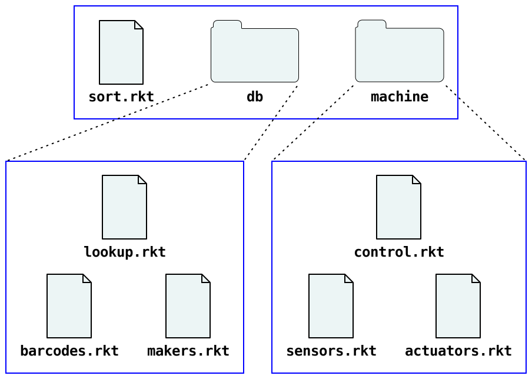

"sort.rkt" 模块使用相对路径 "db/lookup.rkt" 和 "machine/control.rkt" 从数据库库和机器控制库中导入：The "sort.rkt" module uses the relative paths "db/lookup.rkt" and "machine/control.rkt" to import from the database and machine-control libraries:

> > "sort.rkt"

> > > | [#lang](https://docs.racket-lang.org/guide/Module_Syntax.html#%28part._hash-lang%29) [racket](https://docs.racket-lang.org/reference/index.html) |
> > > | --- |
> > > | ([require](https://docs.racket-lang.org/reference/require.html#%28form._%28%28lib._racket%2Fprivate%2Fbase..rkt%29._require%29%29) "db/lookup.rkt" "machine/control.rkt") |
> > > | .... |

同样，"db/lookup.rkt" 模块使用相对于自身源文件的路径来访问 "db/barcodes.rkt" 和 "db/makers.rkt" 模块：The "db/lookup.rkt" module similarly uses paths relative to its own source to access the "db/barcodes.rkt" and "db/makers.rkt" modules:

> > "db/lookup.rkt"

> > > | [#lang](https://docs.racket-lang.org/guide/Module_Syntax.html#%28part._hash-lang%29) [racket](https://docs.racket-lang.org/reference/index.html) |
> > > | --- |
> > > | ([require](https://docs.racket-lang.org/reference/require.html#%28form._%28%28lib._racket%2Fprivate%2Fbase..rkt%29._require%29%29) "barcodes.rkt" "makers.rkt") |
> > > | .... |

"machine/control.rkt" 也是如此：Ditto for "machine/control.rkt":

> > "machine/control.rkt"

> > > | [#lang](https://docs.racket-lang.org/guide/Module_Syntax.html#%28part._hash-lang%29) [racket](https://docs.racket-lang.org/reference/index.html) |
> > > | --- |
> > > | ([require](https://docs.racket-lang.org/reference/require.html#%28form._%28%28lib._racket%2Fprivate%2Fbase..rkt%29._require%29%29) "sensors.rkt" "actuators.rkt") |
> > > | .... |

所有 Racket 工具都会自动处理相对路径。例如，在命令行中执行Racket tools all work automatically with relative paths. For example,

racket sort.rkt

会运行 "sort.rkt" 程序，并自动加载和编译所需的模块。当程序足够大时，从源码编译可能耗时过长，因此可以使用on the command line runs the "sort.rkt" program and automatically loads and compiles required modules. With a large enough program, compilation from source can take too long, so use

raco make sort.rkt

> > > 有关 raco make 的更多信息，参见“raco make：将源码编译为字节码”。See [raco make: Compiling Source to Bytecode](https://docs.racket-lang.org/raco/make.html) for more information on raco make.

将 "sort.rkt" 及其所有依赖项编译为字节码文件。运行 racket sort.rkt 时，如果存在字节码文件，就会自动使用。to compile "sort.rkt" and all its dependencies to bytecode files. Running racket sort.rkt will automatically use bytecode files when they are present.

#### 6.1.2 库集合6.1.2 Library Collections

集合是已安装库模块的分层组织。集合中的模块通过不带引号和后缀的路径引用。例如，以下模块引用了 "racket" 集合中的 "date.rkt" 库：A collection is a hierarchical grouping of installed library modules. A module in a collection is referenced through an unquoted, suffixless path. For example, the following module refers to the "date.rkt" library that is part of the "racket" collection:

> | [#lang](https://docs.racket-lang.org/guide/Module_Syntax.html#%28part._hash-lang%29) [racket](https://docs.racket-lang.org/reference/index.html) |
> | --- |
> | ([require](https://docs.racket-lang.org/reference/require.html#%28form._%28%28lib._racket%2Fprivate%2Fbase..rkt%29._require%29%29) racket/date) |
> | ([printf](https://docs.racket-lang.org/reference/Writing.html#%28def._%28%28quote._~23~25kernel%29._printf%29%29) "Today is ~s\n" |
> | ([date->string](https://docs.racket-lang.org/reference/time.html#%28def._%28%28lib._racket%2Fdate..rkt%29._date-~3estring%29%29) ([seconds->date](https://docs.racket-lang.org/reference/time.html#%28de… |

搜索 Racket 在线文档时，搜索结果会指出提供各个绑定的模块。另外，如果通过点击超链接进入某个绑定的文档，也可以将鼠标悬停在绑定名称上，查看哪些模块提供该绑定。When you search the online Racket documentation, the search results indicate the module that provides each binding. Alternatively, if you reach a binding’s documentation by clicking on hyperlinks, you can hover over the binding name to find out which modules provide it.

[racket/date](https://docs.racket-lang.org/reference/time.html#%28mod-path._racket%2Fdate%29) 这样的模块引用看起来像标识符，但它的处理方式与 [printf](https://docs.racket-lang.org/reference/Writing.html#%28def._%28%28quote._~23~25kernel%29._printf%29%29) 或 [date->string](https://docs.racket-lang.org/reference/time.html#%28def._%28%28lib._racket%2Fdate..rkt%29._date-~3estring%29%29) 不同。[require](https://docs.racket-lang.org/reference/require.html#%28form._%28%28lib._racket%2Fprivate%2Fbase..rkt%29._require%29%29) 遇到不带引号的模块引用时，会将其转换为基于集合的模块路径：A module reference like [racket/date](https://docs.racket-lang.org/reference/time.html#%28mod-path._racket%2Fdate%29) looks like an identifier, but it is not treated in the same way as [printf](https://docs.racket-lang.org/reference/Writing.html#%28def._%28%28quote._~23~25kernel%29._printf%29%29) or [date->string](https://docs.racket-lang.org/reference/time.html#%28def._%28%28lib._racket%2Fdate..rkt%29._date-~3estring%29%29). Instead, when [require](https://docs.racket-lang.org/reference/require.html#%28form._%28%28lib._racket%2Fprivate%2Fbase..rkt%29._require%29%29) sees a module reference that is unquoted, it converts the reference to a collection-based module path:

- 首先，如果不带引号的路径不包含 /，[require](https://docs.racket-lang.org/reference/require.html#%28form._%28%28lib._racket%2Fprivate%2Fbase..rkt%29._require%29%29) 会自动在引用后添加 "/main"。例如，([require](https://docs.racket-lang.org/reference/require.html#%28form._%28%28lib._racket%2Fprivate%2Fbase..rkt%29._require%29%29) [slideshow](https://docs.racket-lang.org/slideshow/index.html)) 等价于 ([require](https://docs.racket-lang.org/reference/require.html#%28form._%28%28lib._racket%2Fprivate%2Fbase..rkt%29._require%29%29) slideshow/main)。First, if the unquoted path contains no /, then [require](https://docs.racket-lang.org/reference/require.html#%28form._%28%28lib._racket%2Fprivate%2Fbase..rkt%29._require%29%29) automatically adds a "/main" to the reference. For example, ([require](https://docs.racket-lang.org/reference/require.html#%28form._%28%28lib._racket%2Fprivate%2Fbase..rkt%29._require%29%29) [slideshow](https://docs.racket-lang.org/slideshow/index.html)) is equivalent to ([require](https://docs.racket-lang.org/reference/require.html#%28form._%28%28lib._racket%2Fprivate%2Fbase..rkt%29._require%29%29) slideshow/main).
- 其次，[require](https://docs.racket-lang.org/reference/require.html#%28form._%28%28lib._racket%2Fprivate%2Fbase..rkt%29._require%29%29) 会隐式地为路径添加 ".rkt" 后缀。Second, [require](https://docs.racket-lang.org/reference/require.html#%28form._%28%28lib._racket%2Fprivate%2Fbase..rkt%29._require%29%29) implicitly adds a ".rkt" suffix to the path.
- 最后，[require](https://docs.racket-lang.org/reference/require.html#%28form._%28%28lib._racket%2Fprivate%2Fbase..rkt%29._require%29%29) 会在已安装的集合中搜索以解析路径，而不是将其视为相对于外围模块路径的路径。Finally, [require](https://docs.racket-lang.org/reference/require.html#%28form._%28%28lib._racket%2Fprivate%2Fbase..rkt%29._require%29%29) resolves the path by searching among installed collections, instead of treating the path as relative to the enclosing module’s path.

粗略地说，集合以文件系统目录实现。例如，"racket" 集合主要位于 Racket 安装目录中 "collects" 目录下的 "racket" 目录，以下表达式会报告这个位置：To a first approximation, a collection is implemented as a filesystem directory. For example, the "racket" collection is mostly located in a "racket" directory within the Racket installation’s "collects" directory, as reported by

> | [#lang](https://docs.racket-lang.org/guide/Module_Syntax.html#%28part._hash-lang%29) [racket](https://docs.racket-lang.org/reference/index.html) |
> | --- |
> | ([require](https://docs.racket-lang.org/reference/require.html#%28form._%28%28lib._racket%2Fprivate%2Fbase..rkt%29._require%29%29) setup/dirs) |
> | ([build-path](https://docs.racket-lang.org/reference/Manipulating_Paths.html#%28def._%28%28quote._~23~25kernel%29._build-path%29%29) ([find-collects-dir](https://docs.racket-lang.org/raco/dirs.html#%2… |
> | "racket") |

不过，Racket 安装目录中的 "collects" 目录只是 [require](https://docs.racket-lang.org/reference/require.html#%28form._%28%28lib._racket%2Fprivate%2Fbase..rkt%29._require%29%29) 查找集合目录的位置之一。其他位置包括 ([find-user-collects-dir](https://docs.racket-lang.org/raco/dirs.html#%28def._%28%28lib._setup%2Fdirs..rkt%29._find-user-collects-dir%29%29)) 报告的用户专属目录，以及通过 PLTCOLLECTS 搜索路径配置的目录。最后，也是最常见的方式，是通过已安装的包找到集合。The Racket installation’s "collects" directory, however, is only one place that [require](https://docs.racket-lang.org/reference/require.html#%28form._%28%28lib._racket%2Fprivate%2Fbase..rkt%29._require%29%29) looks for collection directories. Other places include the user-specific directory reported by ([find-user-collects-dir](https://docs.racket-lang.org/raco/dirs.html#%28def._%28%28lib._setup%2Fdirs..rkt%29._find-user-collects-dir%29%29)) and directories configured through the PLTCOLLECTS search path. Finally, and most typically, collections are found through installed packages.

#### 6.1.3 包与集合6.1.3 Packages and Collections

包是一组通过 Racket 包管理器安装的库（也可以预装在 Racket 发行版中）。例如，[racket/gui](https://docs.racket-lang.org/gui/index.html) 库由 "gui" 包提供，而 [parser-tools/lex](https://docs.racket-lang.org/parser-tools/Lexers.html) 由 "parser-tools" 库提供。A package is a set of libraries that are installed through the Racket package manager (or included as pre-installed in a Racket distribution). For example, the [racket/gui](https://docs.racket-lang.org/gui/index.html) library is provided by the "gui" package, while [parser-tools/lex](https://docs.racket-lang.org/parser-tools/Lexers.html) is provided by the "parser-tools" library.

> > > 更准确地说，[racket/gui](https://docs.racket-lang.org/gui/index.html) 由 "gui-lib" 提供，[parser-tools/lex](https://docs.racket-lang.org/parser-tools/Lexers.html) 由 "parser-tools-lib" 提供，而 "gui" 和 "parser-tools" 包分别在 "gui-lib" 和 "parser-tools-lib" 的基础上添加文档。More precisely, [racket/gui](https://docs.racket-lang.org/gui/index.html) is provided by "gui-lib", [parser-tools/lex](https://docs.racket-lang.org/parser-tools/Lexers.html) is provided by "parser-tools-lib", and the "gui" and "parser-tools" packages extend "gui-lib" and "parser-tools-lib" with documentation.

Racket 程序不直接引用包，而是通过集合引用库。添加或移除包会改变可用的基于集合的库。一个包可以在多个集合中提供库，两个不同的包也可以在同一集合中提供库（但不能提供同一个库，包管理器会确保已安装的包在这一层面不发生冲突）。Racket programs do not refer to packages directly. Instead, programs refer to libraries via collections, and adding or removing a package changes the set of collection-based libraries that are available. A single package can supply libraries in multiple collections, and two different packages can supply libraries in the same collection (but not the same libraries, and the package manager ensures that installed packages do not conflict at that level).

有关包的更多信息，参见《Racket 包管理》。For more information about packages, see [Package Management in Racket](https://docs.racket-lang.org/pkg/index.html).

#### 6.1.4 添加集合6.1.4 Adding Collections

回到“组织模块”中的糖果分拣示例，假设 "db/" 和 "machine/" 中的模块需要一组共用的辅助函数。可以将辅助函数放在 "utils/" 目录中，再让 "db/" 或 "machine/" 中的模块通过以 "../utils/" 开头的相对路径访问这些实用模块。只要一组模块在同一个项目中协同工作，最好就坚持使用相对路径。这样，程序员无需了解你的 Racket 配置，就能沿着相对路径引用查找模块。Looking back at the candy-sorting example of Organizing Modules, suppose that modules in "db/" and "machine/" need a common set of helper functions. Helper functions could be put in a "utils/" directory, and modules in "db/" or "machine/" could access utility modules with relative paths that start "../utils/". As long as a set of modules work together in a single project, it’s best to stick with relative paths. A programmer can follow relative-path references without knowing about your Racket configuration.

有些库需要在多个项目中使用，因此将库的源码与使用它的代码放在同一个目录中并不合理。这种情况下，最佳选择是添加一个新集合。库加入集合之后，就能像 Racket 发行版自带的库一样，通过不带引号的路径引用。Some libraries are meant to be used across multiple projects, so that keeping the library source in a directory with its uses does not make sense. In that case, the best option is to add a new collection. After the library is in a collection, it can be referenced with an unquoted path, just like libraries that are included with the Racket distribution.

可以将文件放入 Racket 安装目录，或 ([get-collects-search-dirs](https://docs.racket-lang.org/raco/dirs.html#%28def._%28%28lib._setup%2Fdirs..rkt%29._get-collects-search-dirs%29%29)) 报告的某个目录，以添加新集合。也可以通过设置 PLTCOLLECTS 环境变量，将目录加入搜索列表。如果设置 PLTCOLLECTS，应让其值以冒号（Unix 和 Mac OS）或分号（Windows）开头，包含一个空路径，以保留原有搜索路径。不过，最佳选择是添加一个包。You could add a new collection by placing files in the Racket installation or one of the directories reported by ([get-collects-search-dirs](https://docs.racket-lang.org/raco/dirs.html#%28def._%28%28lib._setup%2Fdirs..rkt%29._get-collects-search-dirs%29%29)). Alternatively, you could add to the list of searched directories by setting the PLTCOLLECTS environment variable.If you set PLTCOLLECTS, include an empty path in by starting the value with a colon (Unix and Mac OS) or semicolon (Windows) so that the original search paths are preserved. The best option, however, is to add a package.

创建包并不意味着必须向包服务器注册，也不意味着必须经过打包步骤，将源码复制到归档格式中。创建包可以只是使用包管理器，让库从当前源码位置以集合的形式在本机可用。Creating a package *does not* mean that you have to register with a package server or perform a bundling step that copies your source code into an archive format. Creating a package can simply mean using the package manager to make your libraries locally accessible as a collection from their current source locations.

例如，假设目录 "/usr/molly/bakery" 包含 "cake.rkt" 模块（本节开头的示例）和其他相关模块。要让这些模块作为 "bakery" 集合可用，可以任选以下一种方式：For example, suppose you have a directory "/usr/molly/bakery" that contains the "cake.rkt" module (from the beginning of this section) and other related modules. To make the modules available as a "bakery" collection, either

- 使用 raco pkg 命令行工具：Use the raco pkg command-line tool:

  raco pkg install --link /usr/molly/bakery

  其中，当提供的路径包含目录分隔符时，实际上不需要 --link 标志。where the --link flag is not actually needed when the provided path includes a directory separator.
- 在 DrRacket 的 File（文件）菜单中选择 Package Manager（包管理器）。在 Do What I Mean 面板中点击 Browse...（浏览），选择 "/usr/molly/bakery" 目录，再点击 Install（安装）。Use DrRacket’s Package Manager item from the File menu. In the Do What I Mean panel, click Browse..., choose the "/usr/molly/bakery" directory, and click Install.

之后，在任何模块中使用 ([require](https://docs.racket-lang.org/reference/require.html#%28form._%28%28lib._racket%2Fprivate%2Fbase..rkt%29._require%29%29) bakery/cake)，都会从 "/usr/molly/bakery/cake.rkt" 导入 print-cake 函数。Afterward, ([require](https://docs.racket-lang.org/reference/require.html#%28form._%28%28lib._racket%2Fprivate%2Fbase..rkt%29._require%29%29) bakery/cake) from any module will import the print-cake function from "/usr/molly/bakery/cake.rkt".

默认情况下，所安装目录的名称既用作包名，也用作该包提供的集合名。此外，包管理器通常默认仅为当前用户安装，而不是为该 Racket 安装的所有用户安装。更多信息参见《Racket 包管理》。By default, the name of the directory that you install is used both as the package name and as the collection that is provided by the package. Also, the package manager normally defaults to installation only for the current user, as opposed to all users of a Racket installation. See [Package Management in Racket](https://docs.racket-lang.org/pkg/index.html) for more information.

如果打算将库分发给他人，应仔细选择集合名和包名。集合命名空间是分层的，但顶层集合名是全局的，而包命名空间是平面的。对于临时或专用的库，可以考虑放在 "molly" 这样标识作者的顶层名称之下。如果要提供一套权威的烘焙食品库，则可使用 "bakery" 这样的集合名。If you intend to distribute your libraries to others, choose collection and package names carefully. The collection namespace is hierarchical, but top-level collection names are global, and the package namespace is flat. Consider putting one-off libraries under some top-level name like "molly" that identifies the producer. Use a collection name like "bakery" when producing the definitive collection of baked-goods libraries.

将库放入集合后，仍可使用 raco make 编译库源码，但使用 raco setup 更好，也更方便。raco setup 命令接受集合名（而不是文件名），并编译集合内的所有库。此外，raco setup 可以按照集合中 "info.rkt" 模块的设置，构建集合的文档并将其加入文档索引。有关 raco setup 的更多信息，参见“raco setup：安装管理”。After your libraries are put in a collection you can still use raco make to compile the library sources, but it’s better and more convenient to use raco setup. The raco setup command takes a collection name (as opposed to a file name) and compiles all libraries within the collection. In addition, raco setup can build documentation for the collection and add it to the documentation index, as specified by a "info.rkt" module in the collection. See [raco setup: Installation Management](https://docs.racket-lang.org/raco/setup.html) for more information on raco setup.

#### 6.1.5 集合内的模块引用6.1.5 Module References Within a Collection

集合中的模块引用同一集合中的另一个模块时，相对路径和集合路径都可用。例如，"sort.rkt" 模块引用同一集合中的 "db/lookup.rkt" 和 "machine/control.rkt" 模块时，可以像“组织模块”中那样使用相对路径：When a module within a collection references another module within the same collection, either a relative path or a collection path could work. For example, a "sort.rkt" module that references "db/lookup.rkt" and "machine/control.rkt" modules within the same collection could be written with relative paths as in Organizing Modules:

> > "sort.rkt"

> > > | [#lang](https://docs.racket-lang.org/guide/Module_Syntax.html#%28part._hash-lang%29) [racket](https://docs.racket-lang.org/reference/index.html) |
> > > | --- |
> > > | ([require](https://docs.racket-lang.org/reference/require.html#%28form._%28%28lib._racket%2Fprivate%2Fbase..rkt%29._require%29%29) "db/lookup.rkt" "machine/control.rkt") |
> > > | .... |

另外，如果集合名为 "candy"，"sort.rkt" 也可以使用集合路径导入这两个模块：Alternatively, if the collection is named "candy", then "sort.rkt" could use collection paths to import the two modules:

> > "sort.rkt"

> > > | [#lang](https://docs.racket-lang.org/guide/Module_Syntax.html#%28part._hash-lang%29) [racket](https://docs.racket-lang.org/reference/index.html) |
> > > | --- |
> > > | ([require](https://docs.racket-lang.org/reference/require.html#%28form._%28%28lib._racket%2Fprivate%2Fbase..rkt%29._require%29%29) candy/db/lookup candy/machine/control) |
> > > | .... |

在大多数情况下，这些选择的效果相同，但也有例外。用 Scribble 编写文档时，在 [defmodule](https://docs.racket-lang.org/scribble/doc-modules.html#%28form._%28%28lib._scribble%2Fmanual..rkt%29._defmodule%29%29) 等形式中必须使用集合路径；部分原因是文档面向使用库的程序员，因此应显示基于集合的名称。对于 [require](https://docs.racket-lang.org/reference/require.html#%28form._%28%28lib._racket%2Fprivate%2Fbase..rkt%29._require%29%29)，在集合内引用时使用相对路径往往最灵活，但有一些需要注意的地方。For most purposes, these choices will work the same, but there are exceptions. When writing documentation with [Scribble](https://docs.racket-lang.org/scribble/index.html), you must use a collection path with [defmodule](https://docs.racket-lang.org/scribble/doc-modules.html#%28form._%28%28lib._scribble%2Fmanual..rkt%29._defmodule%29%29) and similar forms; that’s partly because documentation is meant to be read by client programmers, and so the collection-based name should appear. Meanwhile, for [require](https://docs.racket-lang.org/reference/require.html#%28form._%28%28lib._racket%2Fprivate%2Fbase..rkt%29._require%29%29), using relative paths for references within a collection tends to be the most flexible approach, but with caveats.

相对路径引用的工作方式与相对 URL 引用很相似：根据访问外围模块的方式来展开引用。如果通过文件系统路径访问外围模块，就将 [require](https://docs.racket-lang.org/reference/require.html#%28form._%28%28lib._racket%2Fprivate%2Fbase..rkt%29._require%29%29) 中的相对路径与该文件系统路径组合成新的文件系统路径。如果通过集合路径访问外围模块，就将 [require](https://docs.racket-lang.org/reference/require.html#%28form._%28%28lib._racket%2Fprivate%2Fbase..rkt%29._require%29%29) 中的相对路径与该集合路径组合成新的集合路径。集合路径又会转换为文件系统路径，因此通常从文件系统路径还是集合路径出发并不重要。遗憾的是，路径解析本身的复杂性会在某些情况下造成差异：Relative-path references work much like relative URL references: the reference is expanded based on the way the enclosing module is accessed. If the enclosing module is accessed through a filesystem path, then a relative path in [require](https://docs.racket-lang.org/reference/require.html#%28form._%28%28lib._racket%2Fprivate%2Fbase..rkt%29._require%29%29) is combined with that filesystem path to form a new filesystem path. If the enclosing module is accessed through a collection path, then a relative path in [require](https://docs.racket-lang.org/reference/require.html#%28form._%28%28lib._racket%2Fprivate%2Fbase..rkt%29._require%29%29) is combined with that collection path to form a new collection path. A collection path is, in turn, converted to a filesystem path, and so the difference between starting with a filesystem or collection path does not usually matter. Unfortunately, inherent complexities of path resolution can create differences in some situations:

- 通过软链接、多个挂载点或大小写不敏感的文件系统（在不隐式规范化路径大小写的操作系统上），可能有多个文件系统路径指向同一个模块文件。Through soft links, multiple mount points, or case-insensitive filesystems (on an operating system that does not implicitly case-normalize paths), there may be multiple filesystem paths that refer to the same module file.

  例如，当当前目录是 "candy" 集合的目录时，racket 启动时收到的当前目录路径，可能导致 racket sort.rkt 使用的文件系统路径不同于 racket -l candy/sort 通过库集合搜索路径找到的路径。此时，如果 "sort.rkt" 同时通过相对路径引用和基于集合的引用访问某些模块，就可能将这些引用解析为同一源模块的不同实例，从而因多次实例化而造成混淆。For example, when the current directory is the "candy" collection’s directory, the current-directory path that racket receives on startup may cause racket sort.rkt to use a different filesystem path than racket -l candy/sort finds through the library-collection search path. In that case, if "sort.rkt" leads to some modules through both relative-path references and collection-based references, it’s possible that those resolve to difference instances of the same source module, creating confusion through multiple instantiations.
- 使用 raco exe 配合 raco distribute 创建要在另一台机器上运行的可执行文件时，当前机器的路径很可能与目标机器的路径毫无关系。raco exe 工具会区别处理通过文件系统路径引用的模块和通过集合路径引用的模块，因为只有后者才适合在运行时通过反射操作访问。When [raco exe](https://docs.racket-lang.org/raco/exe.html) plus [raco distribute](https://docs.racket-lang.org/raco/exe-dist.html) are used to create an executable to run on a different machine, the paths of the current machine are likely unrelated to paths on the target machine. The raco exe tool treats modules that are referenced via filesystem paths differently than modules reference via collection paths, because only the latter make sense to access through reflective operations at run time.

  例如，如果 raco exe sort.rkt 创建的可执行文件在运行时使用 ([dynamic-require](https://docs.racket-lang.org/reference/Module_Names_and_Loading.html#%28def._%28%28quote._~23~25kernel%29._dynamic-require%29%29) 'candy/db/lookup #f)，而创建可执行文件时 "db/lookup.rkt" 是相对于文件系统路径 "sort.rkt" 解析的，那么该 [dynamic-require](https://docs.racket-lang.org/reference/Module_Names_and_Loading.html#%28def._%28%28quote._~23~25kernel%29._dynamic-require%29%29) 调用就会失败。For example, if raco exe sort.rkt creates an executable that uses ([dynamic-require](https://docs.racket-lang.org/reference/Module_Names_and_Loading.html#%28def._%28%28quote._~23~25kernel%29._dynamic-require%29%29) 'candy/db/lookup #f) at run time, then that [dynamic-require](https://docs.racket-lang.org/reference/Module_Names_and_Loading.html#%28def._%28%28quote._~23~25kernel%29._dynamic-require%29%29) will fail in the case that "db/lookup.rkt" is resolved relative to the filesystem path "sort.rkt" at executable-creation time.

仅使用基于集合的路径（包括使用 racket -l candy/sort 这样的 shell 命令，而不是 racket sort.rkt）可以避免所有这些问题，但这要求只在已安装的集合内开发模块，往往不够方便。一贯使用相对路径引用通常最方便，也能在大多数情况下正常工作。Using only collection-based paths (including using shell commands like racket -l candy/sort and not like racket sort.rkt) can avoid all problems, but then you must only develop modules within an installed collection, which is often inconvenient. Using relative-path references consistently tends to be the most convenient while still working in most circumstances.